# Ch. 8 Laminar Flow — fluidpy

#### ✏️ Tiny example: a glycerol bead 1 cm high

ρ = 1260 kg/m³, μ = 1 Pa s, g = 9.81 m/s².

1. Coefficient $\rho g/3\mu=1260\times9.81/3=4.12\times10^3$ m⁻¹s⁻¹.
2. Flux where h = 1 cm and the slope is ∂h/∂x = −0.5: $q=-4.12\times10^3\times10^{-6}\times(-0.5)=2.06\times10^{-3}$ m²/s, flowing outward.
3. Where h = 1 mm with the same slope the flux is 1000 times smaller — the edge barely moves.
4. Effective diffusivity at the crest $\rho gh^3/3\mu=4.1\times10^{-3}$ m²/s, falling as h³ while the bead thins.

> 🔁 **Tools from earlier chapters used here** (see `knowledge/primers.md`)
- **np.where** — `np.where(cond, a, b)` picks a where the condition holds and b elsewhere — here a box-shaped initial bead (Ch. 1 P46).

```python
x = np.linspace(-0.2, 0.2, 400 if not FAST else 200)     # nodes across a 40 cm plate [m]
h0 = np.where(np.abs(x) < 0.01, 0.01, 0.0)               # a box 1 cm high and 2 cm wide: area 2 × 10⁻⁴ m² (half-area 10⁻⁴)
t_out = np.r_[0.0, np.geomspace(0.1, 1000, 20 if not FAST else 12)]   # output times on a log clock [s]
run = ch08.thin_film_spread(h0, x, t_out, rho=1260.0, mu=1.0)   # backward Euler + Newton, conservative flux form
print(f"volume: first {run['volume'][0]:.6e}, last {run['volume'][-1]:.6e} m² (relative change {abs(run['volume'][-1]/run['volume'][0] - 1):.1e})")
for t_ in (10, 100, 1000):                               # compare the front with the similarity law of C10
    i = np.argmin(np.abs(run["t"] - t_))                 # the output time closest to t_
    xN = ch08.viscous_current_similarity(0.0, run["t"][i], 1e-4, rho=1260.0, mu=1.0, return_front=True)[1]
    print(f"t = {run['t'][i]:7.1f} s: numerical front {100*run['x_front'][i]:.2f} cm, similarity x_N {100*xN:.2f} cm")
print("flux at h = 1 cm, slope −0.5:", ch08.thin_film_flux(0.01, -0.5, rho=1260.0, mu=1.0), "m²/s")
```

```
volume: first 2.008822e-04, last 2.008822e-04 m² (relative change 0.0e+00)
t =     7.8 s: numerical front 4.56 cm, similarity x_N 4.48 cm
t =    88.6 s: numerical front 7.37 cm, similarity x_N 7.28 cm
t =  1000.0 s: numerical front 11.96 cm, similarity x_N 11.82 cm
flux at h = 1 cm, slope −0.5: 0.0020593965 m²/s
```

**What does the code above do?**

1. `thin_film_spread` marches $\partial h/\partial t=\frac{\rho g}{3\mu}\partial_x(h^3\partial_xh)$ in the conservative flux form (flux differences between cells), so the volume is conserved to round-off (the printed relative change); the precursor film of 1 µm adds a constant 4 × 10⁻⁷ m² to it.
2. The steps are implicit (backward Euler, Newton iterations), so large time steps are stable although the diffusivity is stiff.
3. The fronts approach the similarity law of C10, $x_N=\eta_N(\beta\mathcal A^3t)^{1/5}$ with $\beta=\rho g/3\mu$ and the half-area $\mathcal A=\int_0^{x_N}h\,dx$ = 10⁻⁴ m² (written 𝒜 so as not to clash with the constant A of the similarity form): about 2 % ahead at the early times (the box has not been forgotten yet), about 1 % at 1000 s.
4. `thin_film_flux` is the tiny example's 2.06 × 10⁻³ m²/s.

```python
xe = np.linspace(-0.2, 0.2, 200); dxe = xe[1] - xe[0]    # 200 cells for the explicit version [m]
he = np.where(np.abs(xe) < 0.01, 0.01, 0.0)              # the same box
beta = 1260.0*ch08.G0/(3*1.0)                            # ρg/3μ [1/(m s)] (ch08 uses g = 9.80665 m/s²)
dte = 0.2*dxe**2/(beta*he.max()**3)                      # explicit stability: well below Δx²/(2D_max) [s]
vol0 = he.sum()*dxe                                      # the starting volume (area per unit width) [m²]
for _ in range(2000):                                    # 2000 explicit finite-volume steps
    hf = 0.5*(he[1:] + he[:-1])                          # thickness at the cell faces
    F = -beta*hf**3*np.diff(he)/dxe                      # face flux q = −β h³ ∂h/∂x [m²/s]
    he[1:-1] -= dte/dxe*np.diff(F)                       # conservative update: flux in minus flux out
t_end = 2000*dte                                         # the time reached [s]
ref = ch08.thin_film_spread(np.where(np.abs(xe) < 0.01, 0.01, 0.0), xe, [t_end], rho=1260.0, mu=1.0)["h"][-1]
print(f"t = {t_end:.3f} s: volume by hand {he.sum()*dxe:.8e} m²; max |explicit − library| = {np.max(np.abs(he - ref)):.1e} m")
assert abs(he.sum()*dxe - vol0) < 1e-12*vol0             # the explicit scheme conserves the volume to round-off
assert np.max(np.abs(he - ref)) < 0.01*0.01              # agree to 1 % of the bead height (the library adds a 1 µm precursor film)
```

```
t = 0.392 s: volume by hand 2.01005025e-04 m²; max |explicit − library| = 5.9e-05 m
```

**What does the code above do?**

1. It marches the thin-film equation by hand with explicit finite-volume steps: face thicknesses, face fluxes $q=-\beta h^3\partial h/\partial x$, and each cell updated by flux in minus flux out, with a time step well below the explicit stability limit.
2. The printed volume never changes (to round-off): the flux form conserves it exactly, as P191 promised.
3. After 2000 small steps (0.39 s) the hand-made film differs from `thin_film_spread` by at most 6 × 10⁻⁵ m — under 1 % of the 1 cm bead; the implicit library solver reaches the same state with far fewer, larger steps.

> 🔁 **Tools from earlier chapters used here** (see `knowledge/primers.md`)
- **animate and show_animation** — `animate(update, frames, fig)` calls update(i) for every frame; `show_animation(anim, player="frames")` gives ◀ ▮▮ ▶ buttons to stop at any time (Ch. 1 P16).

```python
xN = ch08.viscous_current_similarity(0.0, run["t"][1:], 1e-4, rho=1260.0, mu=1.0, return_front=True)[1]   # similarity fronts [m]
fig, (a1, a2) = plt.subplots(1, 2, figsize=(9.5, 3.4), gridspec_kw=dict(width_ratios=[1.6, 1]))   # the figure and its panels
fill = [a1.fill_between(100*x, 1000*run["h"][0], color=COLORS["blue"], alpha=0.5)]   # the bead (a list so update can replace it)
front, = a1.plot([], [], "|", color=COLORS["amber"], ms=18, mew=2)    # the front marker
a1.set_xlim(-15, 15); a1.set_ylim(0, 10.5); a1.set_xlabel("x [cm]"); a1.set_ylabel("h [mm]")   # labels with units
a2.loglog(run["t"][1:], 100*xN, color=COLORS["accent"], ls="--", lw=1.5, label="slope 1/5 (similarity)")   # a curve (its label says which)
dots, = a2.loglog([], [], "o", color=COLORS["teal"], ms=4, label="numerical front")   # an empty line to be filled by each frame
a2.set_xlim(0.08, 1300); a2.set_ylim(0.8, 20); a2.set_xlabel("t [s]"); a2.set_ylabel("front x_N [cm]"); a2.legend(fontsize=7)   # labels with units


def update(i):                                            # frame i = output time run["t"][i]
    fill[0].remove()                                      # replace the filled bead
    fill[0] = a1.fill_between(100*x, 1000*run["h"][i], color=COLORS["blue"], alpha=0.5)   # a filled shape
    front.set_data([100*run["x_front"][i]], [0.3])        # front marker on the plate
    dots.set_data(run["t"][1:i+1], 100*run["x_front"][1:i+1])   # the front history so far
    a1.set_title(f"t = {run['t'][i]:.3g} s · area ∫h dx = {run['volume'][i]*1e4:.4f} cm² (never changes)", fontsize=9)   # each panel says its message
    return []                                            # nothing to blit: the artists were changed in place


show_animation(animate(update, frames=len(run["t"]), fig=fig, interval=200), player="frames")   # render the frames (MP4 video or step player)
```

[figure not shown]

**What you see.** A box of glycerol slumps into a dome and keeps spreading ever more slowly; the amber front marker creeps outward; on the right the numerical front (teal dots) settles onto the purple slope-1/5 line; the volume in the title never changes — the `A3` animation, our remake of Fig. 8.11.

**How to read it.** On the log–log panel ten times longer buys only $10^{1/5}=1.58$ times more spread; use the ◀ ▶ buttons to stop at any time and compare the dome with the box.

**What would change if…** …the fluid were ten times more viscous: every time is ten times longer (t enters only as ρgt/μ), the curves are the same.

📝 **Note.** **N37 [C] · A similarity solution** — a change of variables that turns this PDE into an ODE — exists for the spreading bead; §8.4 develops the idea (C09) and delivers this one (C10: $h=At^{-1/5}F(x/Dt^{1/5})$).

#### 🎮 Interactive: Why does a honey drop spread like t^(1/5)?

**Why interactive rather than a static figure:** Play the spreading from any initial shape and watch it forget that shape and lock onto one profile, while the front marches along a slope-1/5 line on log–log axes and the volume readout never moves — convergence to self-similarity is a process in time, and C10 derives the exponent you measure here.

**What to try:**

- Start from 'two humps': they merge, then the profile turns into the same dome as the box.
- Watch the log–log front view: compare the slope-1/5 and slope-1/2 guides.
- Make the fluid 1000× more viscous (lava lobe) and predict how the curves change before you press play.
- Switch the rescaled view to the wrong exponent m = 1/2 and see the collapse fail.

```python
show_viz("ch08", "viscous_gravity_current")   # full-width explainer; ⤢ Full screen for more room
```

🎮 Interactive 4/9 Why does a honey drop spread like *t*<sup>1/5</sup>? Open alone ↗

[interactive chart not shown]

**What would change if…** …a flow had no length or time scale at all — a plate started suddenly in a fluid that fills all space? Then the only way to make y dimensionless is to combine it with time, $y/\sqrt{\nu t}$, and the whole PDE collapses to an ODE (C09).

## 8.4 Similarity Solutions for Unsteady Incompressible Viscous Flow

**What is this section about?** A plate starts moving under still fluid: how far does the motion reach after a time t? Because the problem has no length or time scale of its own, y and t can only appear together as $y/\sqrt{\nu t}$; the PDE collapses to an ODE whose solution is the error function, and every profile at every time is one curve. We then turn this into a recipe — guess a power-law form, demand that every term scales the same way with t — and use it for a thickening shear layer, a decaying vortex and the spreading bead of C08. The $\sqrt{\nu t}$ scale is the thickness of every laminar boundary layer (Ch. 9) and of the Ekman layers of Ch. 13.

> 🔁 **Recap — Couette start-up: a flow with a length scale** (Ch. 1 §1.5). Ch. 1 solved the start-up of plane Couette flow — a plate suddenly moving at U with a second, fixed plate at distance h — as a Fourier series (`couette_startup_profile`, in which the plate at y = h moves). Impulsively started parallel flows keep $u\,\partial u/\partial x=0$, so they are exact solutions (Exercise 8.31). The gap h is an imposed length: the profiles at different times are *not* one curve. Remove the second plate and that changes (C09).

### 🧩 Stokes' first problem `C09`

*The question:* What is u(y, t) above a plate that suddenly starts moving — and why do all the profiles look the same when rescaled?

*In one line:* $\frac{u}{U}=1-\mathrm{erf}\Big(\frac{y}{2\sqrt{\nu t}}\Big)$ *(8.30)*

#### The problem in plain words

Yank a plate sideways under a still bath (or start the wind over a calm lake): at first only a thin layer moves; the "news" that the wall moves spreads upward by viscous diffusion. How thick is the moving layer after one second, one minute, one hour? This is the prototype of every boundary layer.

#### The idea

```
t = 1 s        t = 4 s          t = 16 s        rescaled: y/√(νt)
│▏             │▎                │▍               │ one curve F(η)
│▎ thin        │▌ 2× thicker     │█ 4× thicker    │ for every t, U, ν
══►U           ══►U              ══►U
```

No ruler in the problem except $\sqrt{\nu t}$, so the profile can only stretch.

📝 **Note.** **N38 [B], N39 [B] · Set-up (Fig. 8.12; often called Rayleigh's problem).** An infinite plate at y = 0 starts moving at U at t = 0 under fluid at rest in y > 0; nothing depends on x, so continuity gives v = 0, and the pressure is the same everywhere because far from the plate the fluid is still at rest. What remains is the 1-D diffusion equation (8.20) — the heat equation of Ch. 1 with ν in place of κ.

$$ \frac{\partial u}{\partial t}=\nu\frac{\partial^2u}{\partial y^2} \qquad \text{(8.20)} $$

#### 🧮 Derivation — The diffusion equation $\frac{\partial u}{\partial t}=\nu\frac{\partial^2u}{\partial y^2}$ for the impulsively started plate `D16` (Eq. 8.20: $\frac{\partial u}{\partial t}=\nu\frac{\partial^2u}{\partial y^2}$)

**What we want to show.** Reduce Navier–Stokes to a diffusion equation for the fluid above a plate that suddenly starts moving.

**Assumptions.** Infinite plate (nothing depends on x); fluid at rest at infinity at every finite t (step 5).

**The plan.**

1. Use invariance in x.
2. Show the pressure gradient vanishes.
3. Divide by ρ.

**Tools we use** (each explained before this point): continuity (D02's move) · partial derivative (P25).

**We start from**

$$ u(x,y,t)\ \text{for}\ y>0,\ \ u(0,t)=U\ (t\ge0),\qquad \nabla\cdot\mathbf u=0\ \text{(4.10)},\qquad \frac{D\mathbf u}{Dt}=-\frac1\rho\nabla p+\nu\nabla^2\mathbf u\ \text{(8.1)} $$

*In words:* an infinite plate at y = 0 set moving at U at t = 0 under fluid at rest

**Step 1 of 6 — Use invariance along the plate.**

$$ \frac{\partial}{\partial x}=0\ \Rightarrow\ \frac{\partial v}{\partial y}=0\ \Rightarrow\ v\equiv0 $$

- *Why we can do this:* Continuity with ∂u/∂x = 0, and v = 0 at the impermeable plate (the D02 move).
- *In words:* the flow is parallel to the plate.

**Step 2 of 6 — Drop the advective terms.**

$$ u\frac{\partial u}{\partial x}+v\frac{\partial u}{\partial y}=0 $$

- *Why we can do this:* Both factors vanish; the equation becomes linear although u is not small.
- *In words:* no advection.

**Step 3 of 6 — Write the two momentum equations.**

$$ \rho\frac{\partial u}{\partial t}=-\frac{\partial p}{\partial x}+\mu\frac{\partial^2u} {\partial y^2},\ \ 0=-\frac{\partial p}{\partial y} $$

- *Why we can do this:* The x- and y-components of (8.1), $\frac{D\mathbf u}{Dt}=-\frac1\rho\nabla p+\nu\nabla^2\mathbf u$ times ρ with steps 1–2.
- *In words:* unsteady friction balance.

**Step 4 of 6 — Read the y-equation.**

$$ p=p(x,t) $$

- *Why we can do this:* ∂p/∂y = 0: the x-gradient of pressure is the same at every height.
- *In words:* what holds far away holds at the plate.

**Step 5 of 6 — Evaluate far from the plate.**

$$ \frac{\partial p}{\partial x}=0 $$

- *Why we can do this:* At any finite t there is a height where the fluid is still at rest, so ∂u/∂t = ∂²u/∂y² = 0 there, forcing ∂p/∂x = 0 — and by step 4 everywhere.
- *In words:* no pressure gradient drives this flow.

**Step 6 of 6 — Divide by ρ.**

$$ \frac{\partial u}{\partial t}=\nu\frac{\partial^2u}{\partial y^2}\ \text{(8.20)} $$

- *Why we can do this:* Dividing by the constant ρ turns μ into the kinematic viscosity ν = μ/ρ, the diffusivity of C01.
- *In words:* (8.20), $\frac{\partial u}{\partial t}=\nu\frac{\partial^2u}{\partial y^2}$: velocity diffuses like heat.

**Result**

$$ \begin{array}{l}\frac{\partial u}{\partial t}=\nu\frac{\partial^2u}{\partial y^2}\ \text{(8.20)} \\ u(y,t=0)=0\ \text{(8.21)} \\ u(y=0,t)=\begin{cases}0 & t<0\\ U & t\ge0\end{cases}\ \text{(8.22)} \\ u(y\to\infty,t)=0\ \text{(8.23)}\end{array} $$

*In words:* the plate's motion spreads upward by pure diffusion.

**What it means.** The problem is linear and has no length scale — the door to the similarity solution (D17).

**Check it.** Units: m/s² both sides ✓; the same equation as Ch. 1's Couette start-up (R14) without the upper wall.

> ⚠️ **Common confusion (traps in `D16`):** ∂p/∂x = 0 because a still region exists far away at every finite t; linearity comes from u∂u/∂x = 0, not from small u.

📝 **Note.** **N40 [B], N41 [B], N42 [B] · Conditions.** $u(y,t=0)=0$ *(8.21)*, the plate condition (8.22) below, and $u(y\to\infty,t)=0$ *(8.23)*. The problem is well posed: (8.20), $\frac{\partial u}{\partial t}=\nu\frac{\partial^2u}{\partial y^2}$ has one time derivative and two space derivatives, so it needs one condition in t and two in y (the order of a PDE in each variable counts the conditions it needs in that variable).

$$ u(y=0,t)=\begin{cases}0 & t<0\\ U & t\ge0\end{cases} \qquad \text{(8.22)} $$

📝 **Note.** **N43 [B], N44 [B] · Dimensional analysis, then linearity.** **N43** u depends on U, y, t and ν; with two dimensions (L, T) there are three groups, (8.24). **N44** Linearity removes the second group, (8.25) — one variable instead of two.

$$ u/U=f\big(y/\sqrt{\nu t},\ y/Ut\big)\ \ \text{(8.24)},\qquad u/U=F\big(y/\sqrt{\nu t}\big)\equiv F(\eta) \qquad \text{(8.25)} $$

#### 🧮 Derivation — From dimensional analysis to one variable: $u/U=f(y/\sqrt{\nu t},y/Ut)$ → $u/U=F(y/\sqrt{\nu t})$ `D17` (Eq. 8.25: $u/U=F\big(y/\sqrt{\nu t}\big)\equiv F(\eta)$)

**What we want to show.** Show that the velocity can depend on y and t only through the single combination y/√(νt).

**Assumptions.** Linear equation and conditions (step 5); no other parameters (no imposed length or time).

**The plan.**

1. Count variables and dimensions.
2. Form the groups.
3. Use linearity to drop one.

**Tools we use** (each explained before this point): Buckingham Π (Ch. 1 §1.11, `ch01.pi_groups`) · linearity (gloss).

**We start from**

$$ u=u(U,y,t,\nu)\ \text{solving}\ \frac{\partial u}{\partial t}=\nu\frac{\partial^2u}{\partial y^2}\ \text{(8.20) with (8.21)–(8.23)} $$

*In words:* the velocity can depend only on the plate speed, the height, the time and the viscosity

**Step 1 of 8 — List the variables.**

$$ u,\ U,\ y,\ t,\ \nu $$

- *Why we can do this:* The answer can depend only on what appears in (8.20)–(8.23), $\frac{\partial u}{\partial t}=\nu\frac{\partial^2u}{\partial y^2},\ u(y,t=0)=0,\ u(y=0,t)=\begin{cases}0 & t<0\\ U & t\ge0\end{cases},\ u(y\to\infty,t)=0$: the plate speed, height, time and viscosity.
- *In words:* five quantities.

**Step 2 of 8 — Count the dimensions.**

$$ [u]=[U]=\mathrm{L/T},\ [y]=\mathrm L,\ [t]=\mathrm T,\ [\nu]=\mathrm{L^2/T} $$

- *Why we can do this:* Only length and time appear, so there are two base dimensions.
- *In words:* two dimensions.

**Step 3 of 8 — Apply the Π theorem.**

$$ 5-2=3\ \text{groups}:\ \ \frac uU,\ \ \frac{y}{\sqrt{\nu t}},\ \ \frac{y}{Ut} $$

- *Why we can do this:* Buckingham: variables minus independent dimensions; each group is checked dimensionless.
- *In words:* three dimensionless groups.

**Step 4 of 8 — Write the functional relation.**

$$ u/U=f(y/\sqrt{\nu t},\ y/Ut)\ \text{(8.24)} $$

- *Why we can do this:* One group as a function of the other two.
- *In words:* (8.24), $u/U=f\big(y/\sqrt{\nu t},\ y/Ut\big)$.

**Step 5 of 8 — Use linearity.**

$$ u\ \text{solves with }U\ \Rightarrow\ \lambda u\ \text{solves with }\lambda U $$

- *Why we can do this:* (8.20), $\frac{\partial u}{\partial t}=\nu\frac{\partial^2u}{\partial y^2}$ and its conditions are linear; only the wall value contains U, and it scales with it.
- *In words:* doubling U doubles u.

**Step 6 of 8 — Conclude u/U cannot depend on U.**

$$ \frac{\partial}{\partial U}\Big(\frac uU\Big)=0 $$

- *Why we can do this:* By step 5, u/U is the same for every U; but y/Ut contains U, so f cannot depend on its second argument.
- *In words:* the second group must go.

**Step 7 of 8 — Drop the second group.**

$$ u/U=F(y/\sqrt{\nu t})\equiv F(\eta)\ \text{(8.25)} $$

- *Why we can do this:* What remains is a function of the first group only.
- *In words:* (8.25), $u/U=F\big(y/\sqrt{\nu t}\big)\equiv F(\eta)$: one similarity variable.

**Step 8 of 8 — Name the similarity variable.**

$$ \eta=\frac{y}{\sqrt{\nu t}} $$

- *Why we can do this:* At fixed t, η ∝ y, so F reads as a profile; another choice (νt/y²) would only change F, not u. The book's figures use η/2.
- *In words:* two variables became one.

**Result**

$$ u/U=F\big(y/\sqrt{\nu t}\big)\equiv F(\eta)\ \text{(8.25)} $$

*In words:* the PDE in y and t becomes an ODE in η.

**What it means.** No imposed scale exists, so y can only be measured in units of √(νt).

**Check it.** η dimensionless: m/√((m²/s)s) ✓. Numbers: y = 1 cm, t = 100 s, ν = 10⁻⁶ → η = 1.

> ⚠️ **Common confusion (traps in `D17`):** Five variables and two dimensions give three groups; it is linearity, not dimensional analysis, that removes y/Ut.

```python
groups = ch01.pi_groups({"u": "m/s", "U": "m/s", "y": "m", "t": "s", "nu": "m^2/s"})   # Ch. 1's Π-group finder
for g_ in groups:                                        # each group as exponents of the variables
    print(" · ".join(f"{k}^{v}" for k, v in g_.items() if v != 0))
```

```
u^1 · U^-1
t^1 · U^1 · y^-1
nu^1 · U^-1 · y^-1
```

**What does the code above do?**

`pi_groups` returns three independent groups, as D17 step 3 counts: $u/U$, $tU/y$ and $\nu/(Uy)$. They are equivalent to the book's choice: $tU/y=(y/Ut)^{-1}$, and $\frac{\nu}{Uy}\cdot\frac{Ut}{y}=\frac{\nu t}{y^2}=\big(\frac{y}{\sqrt{\nu t}}\big)^{-2}$ — any set of three independent combinations is as good as another; linearity then removes the one that contains U.

> 🔁 **Tools from earlier chapters used here** (see `knowledge/primers.md`)
- **chain rule** — if u depends on t only through η(y, t), then ∂u/∂t = (du/dη)(∂η/∂t) (Ch. 1 P49).
- **exponent rules** — $\eta=y\nu^{-1/2}t^{-1/2}$, so $\partial\eta/\partial t=-\tfrac12y\nu^{-1/2}t^{-3/2}=-\eta/(2t)$ (Ch. 1 P43).

📝 **Note.** **N45 [B], N46 [B], N47 [B], N48 [B] · Into the equation.** The chain rule gives $\frac{\partial u}{\partial t}=-\frac{U\eta}{2t}\frac{dF}{d\eta}$ and $\frac{\partial^2u}{\partial y^2}= \frac{U}{\nu t}\frac{d^2F}{d\eta^2}$; they turn (8.20), $\frac{\partial u}{\partial t}=\nu\frac{\partial^2u}{\partial y^2}$ into the ODE (8.26) with $F(\eta=0)=1$ *(8.27)* and $F(\eta\to\infty)=0$ *(8.28)*: the initial condition (8.21), $u(y,t=0)=0$ and the far condition (8.23), $u(y\to\infty,t)=0$ both become η → ∞, so three conditions collapse into two — the test that the similarity form is right.

$$ -\frac\eta2\frac{dF}{d\eta}=\frac{d}{d\eta}\Big(\frac{dF}{d\eta}\Big) \qquad \text{(8.26)} $$

#### 🧮 Derivation — The similarity ODE $-\frac\eta2\frac{dF}{d\eta}=\frac{d}{d\eta}\big(\frac{dF}{d\eta}\big)$ with $F(0)=1$, $F(\infty)=0$ `D18` (Eq. 8.26: $-\frac\eta2\frac{dF}{d\eta}=\frac{d}{d\eta}\Big(\frac{dF}{d\eta}\Big)$)

**What we want to show.** Turn (8.20), $\frac{\partial u}{\partial t}=\nu\frac{\partial^2u}{\partial y^2}$ into an ODE for F(η) and its conditions.

**Assumptions.** t > 0.

**The plan.**

1. Differentiate η.
2. Chain rule for ∂u/∂t and ∂²u/∂y².
3. Substitute, divide, check that t drops out.
4. Translate the conditions.

**Tools we use** (each explained before this point): chain rule (P49/P91) · exponent rules (P43).

**We start from**

$$ \text{u = U F(η), η = y/√(νt), in}\ \frac{\partial u}{\partial t}=\nu\frac{\partial^2u}{\partial y^2}\ \text{(8.20).} $$

**Step 1 of 9 — Differentiate η in time.**

$$ \frac{\partial\eta}{\partial t}=-\frac12\frac{y}{\sqrt\nu}t^{-3/2}=-\frac{\eta}{2t} $$

- *Why we can do this:* η = yν^(−1/2)t^(−1/2); power rule at fixed y.
- *In words:* η shrinks in time at a fixed height.

**Step 2 of 9 — Chain rule for ∂u/∂t.**

$$ \frac{\partial u}{\partial t}=U\frac{dF}{d\eta}\frac{\partial\eta}{\partial t}=-\frac{U\eta}{2t} \frac{dF}{d\eta} $$

- *Why we can do this:* u depends on t only through η.
- *In words:* the local rate of change.

**Step 3 of 9 — Differentiate η in y.**

$$ \frac{\partial\eta}{\partial y}=\frac{1}{\sqrt{\nu t}} $$

- *Why we can do this:* η is linear in y with the slope 1/√(νt), which does not depend on y.
- *In words:* one unit of η is √(νt) of height.

**Step 4 of 9 — First y-derivative.**

$$ \frac{\partial u}{\partial y}=\frac{U}{\sqrt{\nu t}}\frac{dF}{d\eta} $$

- *Why we can do this:* Chain rule: u depends on y only through η, so ∂u/∂y = U F′ ∂η/∂y.
- *In words:* the velocity slope.

**Step 5 of 9 — Second y-derivative.**

$$ \frac{\partial^2u}{\partial y^2}=\frac{U}{\nu t}\frac{d^2F}{d\eta^2} $$

- *Why we can do this:* 1/√(νt) does not depend on y; differentiate F′ again with the chain rule.
- *In words:* the curvature.

**Step 6 of 9 — Substitute into (8.20).**

$$ -\frac{U\eta}{2t}F'=\nu\frac{U}{\nu t}F''=\frac Ut F'' $$

- *Why we can do this:* Insert steps 2 and 5 into (8.20), $\frac{\partial u}{\partial t}=\nu\frac{\partial^2u}{\partial y^2}$ to see whether the time dependence can cancel.
- *In words:* every term carries U/t.

**Step 7 of 9 — Divide by U/t.**

$$ -\frac\eta2\frac{dF}{d\eta}=\frac{d}{d\eta}\Big(\frac{dF}{d\eta}\Big)\ \text{(8.26)} $$

- *Why we can do this:* U/t ≠ 0; t disappears — the test that the similarity form is right.
- *In words:* (8.26), $-\frac\eta2\frac{dF}{d\eta}=\frac{d}{d\eta}\Big(\frac{dF}{d\eta}\Big)$, an ODE.

**Step 8 of 9 — Translate the wall condition.**

$$ F(\eta=0)=1\ \text{(8.27)} $$

- *Why we can do this:* y = 0 gives η = 0 for every t > 0, and u = U there (8.22), $u(y=0,t)=\begin{cases}0 & t<0\\ U & t\ge0\end{cases}$.
- *In words:* fluid at the plate moves with it.

**Step 9 of 9 — Merge the other two conditions.**

$$ F(\eta\to\infty)=0\ \text{(8.28)} $$

- *Why we can do this:* y → ∞ at fixed t (8.23), $u(y\to\infty,t)=0$ and t → 0⁺ at fixed y > 0 (8.21), $u(y,t=0)=0$ both send η → ∞; three conditions become two, as a second-order ODE needs.
- *In words:* far away and initially, the fluid is at rest.

**Result**

$$ \begin{array}{l}-\frac\eta2\frac{dF}{d\eta}=\frac{d}{d\eta}\Big(\frac{dF}{d\eta}\Big)\ \text{(8.26)} \\ F(\eta=0)=1\ \text{(8.27)} \\ F(\eta\to\infty)=0\ \text{(8.28)}\end{array} $$

*In words:* a two-point boundary-value problem in η alone.

**What it means.** Had t not cancelled at step 7, the guess u = UF(y/√(νt)) would have been wrong.

> ⚠️ **Common confusion (traps in `D18`):** ∂η/∂t = −η/(2t), not −η/t; t → 0 and y → ∞ both give η → ∞.

> 📎 **Primer — Gaussian integral.** `P194` · The bell curve $e^{-\zeta^2}$ has total area √π: $\int_{-\infty}^{\infty}e^{-\zeta^2}d\zeta=\sqrt\pi$, and by symmetry half of it, √π/2, lies on each side. No elementary antiderivative exists, which is why its running integral gets a name (next primer).

```python
import numpy as np                                       # numbers
from scipy.integrate import quad
print(quad(lambda z: np.exp(-z**2), 0, np.inf)[0], np.sqrt(np.pi)/2)   # 0.886227 0.886227
```

```
0.8862269254527579 0.8862269254527579
```

> 📎 **Primer — error function erf and its inverses.** `P195` · $\mathrm{erf}(\zeta)=\frac2{\sqrt\pi}\int_0^\zeta e^{-\xi^2}d\xi$ rises from 0 to 1; erfc = 1 − erf falls from 1 to 0 and is computed directly without cancellation. Their inverses answer "where does the profile reach this level?": `scipy.special.erfinv`, `erfcinv`.

```python
from scipy import special
print(special.erf(1.0), special.erfc(1.0))               # 0.8427 0.1573
print(2*special.erfcinv(0.01))                           # 3.643: where erfc(η/2) = 1 %
```

```
0.8427007929497148 0.15729920705028516
3.6427727354368997
```

> 🔁 **Tools from earlier chapters used here** (see `knowledge/primers.md`)
- **natural logarithm, exponentiating** — ∫dG/G = ln G, and $e^{\ln G}=G$: exponentiating turns a constant of integration into a factor (Ch. 1 P36).
- **substitution ξ = 2ζ in an integral** — with ξ = 2ζ, dξ = 2dζ and the limits change with it (Ch. 3 P106).
- **complementary error function erfc** — erfc = 1 − erf, computed without cancellation for large arguments (Ch. 4 P123).

📝 **Note.** **N49 [B], N50 [B], N51 [B] · Solving the ODE.** Separating gives $\frac{dF}{d\eta}=A\exp(-\eta^2/4)$, a second integration gives (8.29), and the conditions give B = 1 and, with ξ = 2ζ and the Gaussian integral, $A=-1/\sqrt\pi$.

$$ F(\eta)=A\int_0^\eta\exp(-\xi^2/4)\,d\xi+B \qquad \text{(8.29)} $$

#### 🧮 Derivation — Solving the ODE: $F(\eta)=A\int_0^\eta e^{-\xi^2/4}d\xi+B$ and $\frac uU=1-\mathrm{erf}\big(\frac{y}{2\sqrt{\nu t}}\big)$ `D19` (Eq. 8.30: $\frac{u}{U}=1-\mathrm{erf}\Big(\frac{y}{2\sqrt{\nu t}}\Big)$)

**What we want to show.** Solve (8.26), $-\frac\eta2\frac{dF}{d\eta}=\frac{d}{d\eta}\Big(\frac{dF}{d\eta}\Big)$ with its conditions and express the answer through the error function.

**Assumptions.** None beyond (8.26)–(8.28).

**The plan.**

1. Solve for F′ by separation.
2. Integrate again.
3. Fix the constants with the Gaussian integral.
4. Recognise erf.

**Tools we use** (each explained before this point): separation of variables (P42) · natural log and exponential (P36) · Gaussian integral (primer P194) · substitution (P106) · erf (primer P195).

**We start from**

$$ \begin{array}{l}-\frac\eta2\frac{dF}{d\eta}=\frac{d}{d\eta}\Big(\frac{dF}{d\eta}\Big)\ \text{(8.26)} \\ F(\eta=0)=1\ \text{(8.27)} \\ F(\eta\to\infty)=0\ \text{(8.28)}\end{array} $$

*In words:* the similarity ODE and its two conditions from D18

**Step 1 of 12 — Call the slope G.**

$$ G\equiv F'\ \Rightarrow\ -\frac\eta2G=\frac{dG}{d\eta} $$

- *Why we can do this:* F itself does not appear in (8.26), $-\frac\eta2\frac{dF}{d\eta}=\frac{d}{d\eta}\Big(\frac{dF}{d\eta}\Big)$, so it is a first-order ODE for F′.
- *In words:* first solve for the slope.

**Step 2 of 12 — Separate the variables.**

$$ -\frac\eta2d\eta=\frac{dG}{G} $$

- *Why we can do this:* Divide by G and multiply by dη (P42).
- *In words:* η on one side, G on the other.

**Step 3 of 12 — Integrate both sides.**

$$ -\frac{\eta^2}{4}=\ln G+\text{const} $$

- *Why we can do this:* ∫η dη = η²/2; ∫dG/G = ln G.
- *In words:* a logarithm of the slope.

**Step 4 of 12 — Exponentiate.**

$$ \frac{dF}{d\eta}=A\exp(-\eta^2/4) $$

- *Why we can do this:* $e^{ln G}$ = G; the constant becomes a factor A.
- *In words:* the slope is a Gaussian.

**Step 5 of 12 — Integrate from 0 to η.**

$$ F(\eta)=A\int_0^\eta\exp(-\xi^2/4)\,d\xi+B\ \text{(8.29)} $$

- *Why we can do this:* Fundamental theorem of calculus; ξ is a dummy variable, B = F(0).
- *In words:* (8.29), $F(\eta)=A\int_0^\eta\exp(-\xi^2/4)\,d\xi+B$.

**Step 6 of 12 — Apply F(0) = 1.**

$$ B=1 $$

- *Why we can do this:* The integral from 0 to 0 vanishes.
- *In words:* the plate condition.

**Step 7 of 12 — Apply F(∞) = 0.**

$$ 0=A\int_0^\infty e^{-\xi^2/4}d\xi+1 $$

- *Why we can do this:* Apply (8.28), $F(\eta\to\infty)=0$, F → 0 as η → ∞, with B = 1 already fixed.
- *In words:* one equation for A.

**Step 8 of 12 — Substitute ξ = 2ζ.**

$$ 0=2A\int_0^\infty e^{-\zeta^2}d\zeta+1 $$

- *Why we can do this:* dξ = 2dζ and ξ²/4 = ζ²; this turns the integral into the standard Gaussian.
- *In words:* the factor 2 that ends up in y/(2√(νt)).

**Step 9 of 12 — Use the Gaussian integral.**

$$ 0=2A\frac{\sqrt\pi}{2}+1\ \Rightarrow\ A=-\frac{1}{\sqrt\pi} $$

- *Why we can do this:* ∫₀^∞$e^{-ζ^2}$dζ = √π/2, half of the full √π by symmetry (P194).
- *In words:* A is negative: F falls.

**Step 10 of 12 — Insert A and B into (8.29).**

$$ F(\eta)=1-\frac{1}{\sqrt\pi}\int_0^\eta e^{-\xi^2/4}\,d\xi $$

- *Why we can do this:* Put B = 1 (step 6) and A = −1/√π (step 9) back into (8.29), $F(\eta)=A\int_0^\eta\exp(-\xi^2/4)\,d\xi+B$, so that the solution is written with both constants known. (Part F went straight to the substituted integral; this step is added.)
- *In words:* the solution, still in the variable ξ.

**Step 11 of 12 — Substitute again inside F.**

$$ F(\eta)=1-\frac{2}{\sqrt\pi}\int_0^{\eta/2}e^{-\zeta^2}d\zeta $$

- *Why we can do this:* Substitute ξ = 2ζ again (dξ = 2dζ, ξ²/4 = ζ²): the factor 2 turns 1/√π into 2/√π, and the upper limit ξ = η becomes ζ = η/2.
- *In words:* ready to name.

**Step 12 of 12 — Recognise the error function.**

$$ \frac{u}{U}=1-\mathrm{erf}\Big(\frac{y}{2\sqrt{\nu t}}\Big),\ \ \mathrm{erf}(\zeta)= \frac{2}{\sqrt\pi}\int_0^\zeta e^{-\xi^2}d\xi\ \text{(8.30)} $$

- *Why we can do this:* The definition of erf (P195); η/2 = y/(2√(νt)).
- *In words:* (8.30), $\frac{u}{U}=1-\mathrm{erf}\Big(\frac{y}{2\sqrt{\nu t}}\Big)$ = erfc.

**Result**

$$ \frac{u}{U}=1-\mathrm{erf}\Big(\frac{y}{2\sqrt{\nu t}}\Big),\qquad \mathrm{erf}(\zeta)=\frac2{\sqrt\pi}\int_0^\zeta e^{-\xi^2}d\xi\ \ \text{(8.30)} $$

*In words:* the velocity falls from U at the plate as the complementary error function of y/(2√(νt)).

**What it means.** One curve for all t, U, ν — the collapse of Fig. 8.13; the plate's influence reaches ~ 3.6√(νt) (D20).

**Check it.** F(0) = 1 − 0 = 1 ✓, F(∞) = 1 − 1 = 0 ✓; residual of (8.20), $\frac{\partial u}{\partial t}=\nu\frac{\partial^2u}{\partial y^2}$ zero (sympy); y = 1 cm, t = 100 s: erfc(0.5) = 0.4795; the CN solution converges to it at order 2.

> ⚠️ **Common confusion (traps in `D19`):** The substitution carries dξ = 2dζ; ∫₀^∞ is √π/2 (half); A < 0; compute with erfc, not 1 − erf, for large η.

> 📎 **Primer — scipy.integrate.solve_bvp.** `P196` · `solve_bvp` solves an ODE with conditions at two ends (here F(0) = 1 and F(η_max) = 0 on a truncated domain) by collocation on a mesh; we give it the system as first-order equations (F′ = G, G′ = −ηG/2) and a guess.

```python
import numpy as np                                       # numbers
from scipy.integrate import solve_bvp
eta = np.linspace(0, 12, 50)                             # the truncated η-domain and initial mesh
sol = solve_bvp(lambda e, Y: np.vstack([Y[1], -e/2*Y[1]]),   # Y = (F, F′): F′ = G, G′ = −(η/2)G  (8.26)
                lambda a, b: np.array([a[0] - 1, b[0]]),     # F(0) = 1, F(12) = 0
                eta, np.vstack([np.exp(-eta), -np.exp(-eta)]))   # a rough guess
print(sol.sol(2.0)[0])                                   # 0.1573 = erfc(1)
```

```
0.15729927526875076
```

📝 **Note.** **N52 [B], N55 [B] · One curve (Figs. 8.12–8.13, remade below).** **N52** Profiles at several times (raw) and the same against the similarity variable. ⚠️ The book's figure axis is $y/(2\sqrt{\nu t})=\eta/2$, while (8.25), $u/U=F\big(y/\sqrt{\nu t}\big)\equiv F(\eta)$ defines $\eta=y/\sqrt{\nu t}$; our axes say which. **N55** *Self-similarity:* profiles at any t, for any U and ν, fall on one curve when u/U is plotted against η — we measure the spread below (< 10⁻¹²).

#### 🧮 Derivation — The 99 % thickness $\delta_{99}\sim3.64\sqrt{\nu t}$ `D20` (Eq. 8.31: $\delta_{99}\sim3.64\sqrt{\nu t}$)

**What we want to show.** Compute (instead of reading off a figure) the height where u falls to 1 % of U.

**Assumptions.** The 1 % level is a convention.

**The plan.**

1. Set the level.
2. Invert erfc.
3. Convert to height.

**Tools we use** (each explained before this point): erf and its inverses (primer P195) · brentq (P108) as a cross-check.

**We start from**

$$ \frac uU=1-\mathrm{erf}\big(\frac{y}{2\sqrt{\nu t}}\big)=\mathrm{erfc}\big(\frac{\eta}{2}\big)\ \text{(8.30).} $$

**Step 1 of 5 — Choose the edge level.**

$$ \frac uU=0.01 $$

- *Why we can do this:* The profile never reaches zero; the book (and Ch. 9) define the edge at 99 % of the change.
- *In words:* the 1 % point.

**Step 2 of 5 — Write it with (8.30).**

$$ \mathrm{erfc}\Big(\frac{\eta_{99}}{2}\Big)=0.01 $$

- *Why we can do this:* Substitute the 1 % level into (8.30), $\frac{u}{U}=1-\mathrm{erf}\Big(\frac{y}{2\sqrt{\nu t}}\Big)$, written with η/2 as its argument.
- *In words:* one equation for η₉₉.

**Step 3 of 5 — Invert erfc.**

$$ \frac{\eta_{99}}{2}=\mathrm{erfc}^{-1}(0.01)=1.8214 $$

- *Why we can do this:* erfc is monotonic, so it has a unique inverse (`special.erfcinv`; brentq agrees).
- *In words:* on the book's axis η/2 = 1.82.

**Step 4 of 5 — Double it.**

$$ \eta_{99}=3.643\ \Rightarrow\ \delta_{99}=3.643\sqrt{\nu t}\ \text{(8.31)} $$

- *Why we can do this:* η = y/√(νt), so the height is η₉₉√(νt).
- *In words:* (8.31), $\delta_{99}\sim3.64\sqrt{\nu t}$.

**Step 5 of 5 — Put in numbers.**

$$ \nu=10^{-6},\ t=100\ \mathrm s:\ \ \delta_{99}=3.64\ \mathrm{cm};\ \ t=3600\ \mathrm s:\ 21.9\ \mathrm{cm} $$

- *Why we can do this:* √(νt) = 1 cm and 6 cm; the thickness grows as t^(1/2).
- *In words:* an hour of diffusion reaches only a hand's width in water.

**Result**

$$ \delta_{99}=2\,\mathrm{erfc}^{-1}(0.01)\sqrt{\nu t}=3.643\sqrt{\nu t}\ \ \text{(8.31)} $$

*In words:* the moving layer thickens like √(νt).

**What it means.** The √(νt) law is the thickness of every laminar boundary layer (Ch. 9, with t = x/U) and of spin-up layers in the ocean (Ch. 13).

**Check it.** Units m ✓; a 95 % level gives 2 erfc⁻¹(0.05) = 2.772 — the factor is a convention.

> ⚠️ **Common confusion (traps in `D20`):** The book's figure axis is η/2 = 1.82; (8.31), $\delta_{99}\sim3.64\sqrt{\nu t}$ quotes η = 3.64.

📝 **Note.** **N54 [B] · The 99 % thickness** grows like $t^{1/2}$: in water 3.64 cm after 100 s, 21.9 cm after an hour — diffusion is slow over large distances (the code below prints $2\,\mathrm{erfc}^{-1}(0.01)=3.643$).

$$ \delta_{99}\sim3.64\sqrt{\nu t} \qquad \text{(8.31)} $$

#### ✏️ Tiny example: a plate in water after 100 s

ν = 10⁻⁶ m²/s, t = 100 s, U = 0.1 m/s.

1. $\sqrt{\nu t}=\sqrt{10^{-4}}=0.01$ m.
2. At y = 1 cm: η = 1, η/2 = 0.5, u/U = erfc(0.5) = 0.4795 — half the plate speed.
3. $\delta_{99}=3.643\times0.01=3.64$ cm.
4. After 400 s: $\sqrt{\nu t}$ doubles to 2 cm, $\delta_{99}=7.29$ cm, and u(2 cm) = 0.4795U again (same η).
5. Wall stress $\tau_w=\mu U/\sqrt{\pi\nu t}=10^{-3}\times0.1/\sqrt{\pi\times10^{-4}}=5.64\times10^{-3}$ Pa, falling like $t^{-1/2}$.

```python
t = 100.0; y = np.array([0.0, 0.005, 0.01, 0.02, 0.0364])   # a time [s] and five heights [m]
print("u =", ch08.stokes_first_problem(y, t, U=0.1, nu=NU_W), "m/s")   # (8.30) via erfc
print("η =", ch08.similarity_variable(y, t, NU_W), " η/2 =", ch08.similarity_variable(y, t, NU_W, half=True))
print(f"δ99 = {ch08.diffusion_thickness(t, NU_W):.5f} m at 100 s, {ch08.diffusion_thickness(3600.0, NU_W):.4f} m after an hour")
print("2 erfcinv(0.01) =", round(2*special.erfcinv(0.01), 4))   # the 3.643 of (8.31)
st = ch08.stokes_first_state(t, U=0.1, nu=NU_W)          # the numbers the explainer shows
print({k: round(float(st[k]), 6) for k in ("sqrt_nut", "eta_edge", "delta", "tau_w", "vorticity_content")})
print("∫ω dy =", ch08.vorticity_content(t, U=0.1, nu=NU_W), "m/s (= U)")   # N53 below, by quad
print("Ch. 4:", ch04.stokes_first_problem(y, t, 0.1, NU_W))   # the same u from Ch. 4's earlier function
eta, F = ch08.similarity_ode_solve("stokes1")             # solve_bvp on (8.26)–(8.28), knowing nothing about erf
print(f"max |F_bvp − erfc(η/2)| = {np.max(np.abs(F - special.erfc(eta/2))):.1e}")
```

```
u = [0.1    0.0724 0.048  0.0157 0.001 ] m/s
η = [0.   0.5  1.   2.   3.64]  η/2 = [0.   0.25 0.5  1.   1.82]
δ99 = 0.03643 m at 100 s, 0.2186 m after an hour
2 erfcinv(0.01) = 3.6428
{'sqrt_nut': 0.01, 'eta_edge': 3.642773, 'delta': 0.036428, 'tau_w': 0.005642, 'vorticity_content': 0.1}
∫ω dy = 0.10000000000000002 m/s (= U)
Ch. 4: [0.1    0.0724 0.048  0.0157 0.001 ]
max |F_bvp − erfc(η/2)| = 3.7e-13
```

**What does the code above do?**

1. `stokes_first_problem` is (8.30), $\frac{u}{U}=1-\mathrm{erf}\Big(\frac{y}{2\sqrt{\nu t}}\Big)$ computed with erfc: u = [0.1, 0.0724, 0.0480, 0.0157, 0.0010] m/s.
2. `similarity_variable` returns η = y/√(νt), and with `half=True` the book's figure axis η/2.
3. `diffusion_thickness` is (8.31), $\delta_{99}\sim3.64\sqrt{\nu t}$: 3.64 cm after 100 s, 21.9 cm after an hour.
4. `stokes_first_state` bundles √(νt) = 1 cm, the edge η₉₉ = 3.643, δ₉₉, the wall stress 5.64 × 10⁻³ Pa and the vorticity content; `vorticity_content` integrates ω over the whole layer and gets U (N53).
5. Ch. 4's earlier function gives the same numbers; the boundary-value solver, knowing nothing about erf, lands on the same curve to about 10⁻¹³.

> 📎 **Primer — Crank–Nicolson with scipy.linalg.solve_banded.** `P193` · Crank–Nicolson averages the diffusion term between the old and the new time level: second-order accurate in time and stable for any step. Each step solves a tridiagonal system, which `scipy.linalg.solve_banded` does in O(N) from the three diagonals stored as rows. An impulsive start (the plate jumps to U) makes pure Crank–Nicolson ring, so we take the first two steps with backward Euler (fully implicit), which damps the ringing.

```python
import numpy as np                                       # numbers
from scipy.linalg import solve_banded                    # the banded (tridiagonal) solver
ab = np.array([[0, -1, -1], [4, 4, 4], [-1, -1, 0]], float)   # upper, main, lower diagonals (as rows)
print(solve_banded((1, 1), ab, np.array([3.0, 2.0, 3.0])))    # [1. 1. 1.]
```

```
[1. 1. 1.]
```

```python
U0, t_end = 0.1, 1000.0                                  # plate speed [m/s] and final time [s]


def cn_by_hand(N, nt):                                   # Crank–Nicolson march of (8.20) on N points, nt steps
    yy = np.linspace(0, 8*np.sqrt(NU_W*t_end), N)        # up to 8√(νt_end), where u ≈ 0 [m]
    dy, dt = yy[1] - yy[0], t_end/nt                     # grid step [m], time step [s]
    r = NU_W*dt/dy**2                                    # the diffusion number ν Δt/Δy²
    u = np.zeros(N)                                      # fluid at rest (8.21)
    for k in range(nt):
        th = 1.0 if k < 2 else 0.5                       # two backward-Euler steps, then Crank–Nicolson (θ = ½)
        ab = np.zeros((3, N - 2))                        # the three diagonals of the implicit part
        ab[0, 1:], ab[1, :], ab[2, :-1] = -th*r, 1 + 2*th*r, -th*r
        rhs = u[1:-1] + (1 - th)*r*(u[2:] - 2*u[1:-1] + u[:-2])   # the explicit part of the average
        rhs[0] += th*r*U0                                # the wall value u(0) = U (8.22) moves to the right side
        u = np.r_[U0, linalg.solve_banded((1, 1), ab, rhs), 0.0]   # new profile with the two boundary values
    return yy, u


N_ = 400 if not FAST else 200                            # grid points
yy, u_cn = cn_by_hand(N_, 200 if not FAST else 100)       # our march
exact = ch08.stokes_first_problem(yy, t_end, U0, NU_W)   # (8.30)
print(f"hand CN vs (8.30): max error {np.max(np.abs(u_cn - exact)):.1e} m/s")
assert np.allclose(u_cn, exact, rtol=1e-3, atol=2e-4)    # the march lands on the erfc curve
u_lib = ch08.crank_nicolson_1d(np.zeros(N_), yy, t_end/(200 if not FAST else 100), 200 if not FAST else 100, NU_W, U0, 0.0)
assert np.allclose(u_lib, u_cn, rtol=0, atol=1e-12)      # the library solver does exactly this
dyf = yy[1] - yy[0]; dtf = diffusion.stable_time_step(NU_W, dyf); nf = int(np.ceil(t_end/dtf))   # Ch. 1's explicit FTCS
u_ftcs = diffusion.ftcs_diffusion_1d(np.r_[U0, np.zeros(N_ - 1)], NU_W, dyf, t_end/nf, nf, values=(U0, 0.0), save_every=nf)[-1]
print(f"FTCS ({nf} small steps) vs (8.30): max error {np.max(np.abs(u_ftcs - exact)):.1e} m/s")
assert np.allclose(u_ftcs, exact, atol=1e-3*U0)          # the explicit scheme agrees too, with ~28× more steps
errs, steps = [], []                                     # a convergence table: refine space and time together
for N2 in (100, 200, 400):
    y2, u2 = cn_by_hand(N2, N2)
    errs.append(np.max(np.abs(u2 - ch08.stokes_first_problem(y2, t_end, U0, NU_W)))); steps.append(y2[1] - y2[0])
    print(f"N = {N2}: max error {errs[-1]:.2e} m/s")
print(f"observed order ≈ {observed_order(steps, errs):.2f}")   # ≈ 2: second order in space and time
```

```
hand CN vs (8.30): max error 7.6e-07 m/s
FTCS (5528 small steps) vs (8.30): max error 2.3e-06 m/s
N = 100: max error 9.14e-06 m/s
N = 200: max error 2.26e-06 m/s
```

```
N = 400: max error 5.64e-07 m/s
observed order ≈ 2.00
```

**What does the code above do?**

1. `cn_by_hand` marches (8.20), $\frac{\partial u}{\partial t}=\nu\frac{\partial^2u}{\partial y^2}$ with Crank–Nicolson: two backward-Euler start-up steps, then the average of old and new diffusion terms, one tridiagonal `solve_banded` per step. After 1000 s it lands on the erfc curve (8.30), $\frac{u}{U}=1-\mathrm{erf}\Big(\frac{y}{2\sqrt{\nu t}}\Big)$ to about 10⁻⁶ m/s.
2. `ch08.crank_nicolson_1d` with the same inputs gives the *identical* profile (difference below 10⁻¹²): the library does exactly this.
3. Ch. 1's explicit FTCS scheme also agrees, but needs 5528 small steps (its stability limit) against 200.
4. The convergence table halves Δy and Δt together: the error falls by about 4 each time, observed order 2.00 — second order in space and time.

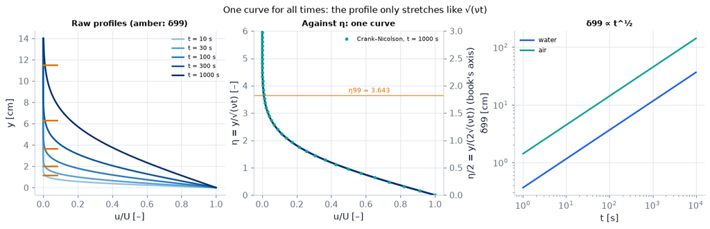

```python
U0 = 0.1                                                  # plate speed [m/s]
ts = [10, 30, 100, 300, 1000]                             # five times [s]
shades = plt.cm.Blues(np.linspace(0.4, 1.0, len(ts)))     # darker blue for later times
y = np.linspace(0, 0.14, 400)                             # heights [m]
fig, (a1, a2, a3) = plt.subplots(1, 3, figsize=(12, 3.8))   # the figure and its panels
for t_, c in zip(ts, shades):                            # one profile per time
    u = ch08.stokes_first_problem(y, t_, U0, NU_W)        # (8.30)
    a1.plot(u/U0, 100*y, color=c, lw=2, label=f"t = {t_} s")   # a curve (its label says which)
    d99 = ch08.diffusion_thickness(t_, NU_W)              # (8.31)
    a1.plot([0, 0.08], [100*d99]*2, color=COLORS["amber"], lw=2)   # δ99 tick
    a2.plot(u/U0, ch08.similarity_variable(y, t_, NU_W), color=c, lw=2)   # the same profile against η
a2.plot(u_cn[::8]/U0, ch08.similarity_variable(yy[::8], 1000.0, NU_W), "o", color=COLORS["teal"], ms=3, label="Crank–Nicolson, t = 1000 s")   # a curve (its label says which)
a1.set_xlabel("u/U [–]"); a1.set_ylabel("y [cm]"); a1.legend(fontsize=7); a1.set_title("Raw profiles (amber: δ99)", fontsize=10)   # labels with units
a2.set_xlabel("u/U [–]"); a2.set_ylabel("η = y/√(νt) [–]"); a2.set_ylim(0, 6); a2.legend(fontsize=7)   # labels with units
a2.axhline(3.643, color=COLORS["amber"], lw=0.8); a2.text(0.5, 3.75, "η99 = 3.643", color=COLORS["amber"], fontsize=8)   # reference line
sec = a2.secondary_yaxis("right", functions=(lambda e: e/2, lambda e: 2*e)); sec.set_ylabel("η/2 = y/(2√(νt)) (book's axis)")   # a second scale: η/2, the book's axis
a2.set_title("Against η: one curve", fontsize=10)        # each panel says its message
tt = np.geomspace(1, 1e4, 50)                             # times [s]
a3.loglog(tt, 100*ch08.diffusion_thickness(tt, NU_W), color=COLORS["blue"], lw=2, label="water")   # a curve (its label says which)
a3.loglog(tt, 100*ch08.diffusion_thickness(tt, nu_air), color=COLORS["teal"], lw=2, label="air")   # a curve (its label says which)
a3.set_xlabel("t [s]"); a3.set_ylabel("δ99 [cm]"); a3.legend(fontsize=8); a3.set_title("δ99 ∝ t^½", fontsize=10)   # labels with units
fig.suptitle("One curve for all times: the profile only stretches like √(νt)", fontsize=11)   # the figure's message
savefig(fig, "ch08", "c09_stokes_first"); plt.show()     # save the PNG to outputs/ch08, then draw
```

**What you see.** (a) five profiles of growing thickness with their 99 % heights (amber ticks); (b) the same five profiles against η — they coincide exactly, and the Crank–Nicolson dots sit on them; (c) two straight lines of slope ½ — our remake of Figs. 8.12–8.13 `N52`.

**How to read it.** (b): the 1 % point sits at η = 3.64 (η/2 = 1.82 on the book's axis, the right-hand scale); (c): 100 times longer gives 10 times thicker.

**What would change if…** …the fluid were air: every thickness grows √15 ≈ 3.9 times faster, but (b) is unchanged.

```python
eta_grid = np.linspace(0, 8, 161)                        # a common η grid
spread = 0.0                                             # the largest difference from erfc(η/2)
for U_, nu_, t_ in ((0.1, 1e-6, 10.0), (2.0, 1.5e-5, 3.0), (0.01, 1e-3, 500.0)):   # water, air, syrup at three times
    y_ = eta_grid*np.sqrt(nu_*t_)                        # heights with those η [m]
    spread = max(spread, np.max(np.abs(ch08.stokes_first_problem(y_, t_, U_, nu_)/U_ - special.erfc(eta_grid/2))))
print(f"collapse: max |u/U − erfc(η/2)| over three (U, ν, t) = {spread:.1e}")
assert spread < 1e-12                                    # N55: one curve for every U, ν and t
```

```
collapse: max |u/U − erfc(η/2)| over three (U, ν, t) = 1.1e-16
```

📝 **Note.** **N53 [B] · Reading it as vorticity.** At t = 0 the wall creates a vortex sheet (all the vorticity in an infinitely thin layer); afterwards it diffuses out: $\omega=-\partial u/\partial y=\frac{U}{\sqrt{\pi\nu t}}e^{-y^2/4\nu t}>0$. The total below never changes, so no new vorticity is made after t = 0. ⚠️ The book prints this integral as −U; since u decreases upward, ω is positive and the integral is +U (checked above by `vorticity_content`). The heat analogue: a cold solid whose face is suddenly heated.

$$ \int_0^\infty\omega\,dy=u(0)-u(\infty)=U $$

📝 **Note.** **N56 [B] · Similarity needs the absence of imposed scales.** Stop the plate at t = T (Exercise 8.30) and a time scale appears; by superposition (ours) the velocity is $u=U\big[\mathrm{erfc}\frac{y}{2\sqrt{\nu t}}-\mathrm{erfc}\frac{y}{2\sqrt{\nu(t-T)}}\big]$ for t > T. Put a second plate at y = h (R14) and a length scale appears. Either way the profiles stop collapsing — the spin-down of a stirred tank (Ch. 13) is of this kind.

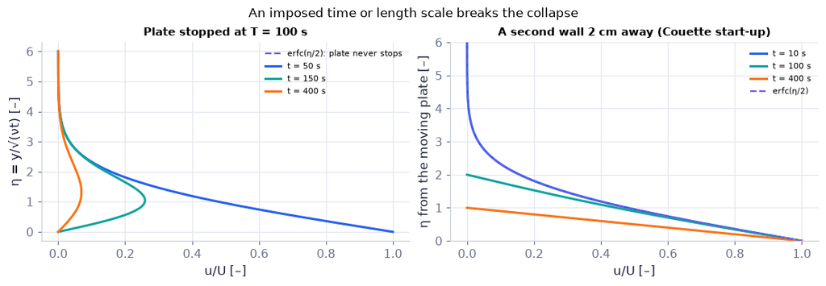

```python
fig, (a1, a2) = plt.subplots(1, 2, figsize=(10, 3.4))    # the figure and its panels
eta_ = np.linspace(0, 6, 200)                             # η grid [–]
a1.plot(special.erfc(eta_/2), eta_, color=COLORS["accent"], ls="--", lw=1.5, label="erfc(η/2): plate never stops")   # a curve (its label says which)
for t_, c in ((50, COLORS["blue"]), (150, COLORS["teal"]), (400, COLORS["orange"])):   # times [s]; the plate stops at T = 100 s
    y_ = eta_*np.sqrt(NU_W*t_)                            # heights at this time [m]
    a1.plot(ch08.stokes_first_stopped(y_, t_, 100.0, U=1.0, nu=NU_W), eta_, color=c, lw=2, label=f"t = {t_} s")   # a curve (its label says which)
a1.set_xlabel("u/U [–]"); a1.set_ylabel("η = y/√(νt) [–]"); a1.legend(fontsize=7); a1.set_title("Plate stopped at T = 100 s", fontsize=10)   # labels with units
h_ = 0.02                                                 # a second, fixed plate 2 cm away [m]
for t_, c in ((10, COLORS["blue"]), (100, COLORS["teal"]), (400, COLORS["orange"])):   # three times [s]
    yb = np.linspace(0, h_, 200)                          # the gap [m]; Ch. 1's function moves the plate at y = h
    ub = diffusion.couette_startup_profile(yb, t_, 0.1, h_, NU_W)   # Fourier series of the start-up [m/s]
    a2.plot(ub/0.1, (h_ - yb)/np.sqrt(NU_W*t_), color=c, lw=2, label=f"t = {t_} s")   # distance from the moving plate, in η
a2.plot(special.erfc(eta_/2), eta_, color=COLORS["accent"], ls="--", lw=1.5, label="erfc(η/2)")   # a curve (its label says which)
a2.set_ylim(0, 6); a2.set_xlabel("u/U [–]"); a2.set_ylabel("η from the moving plate [–]"); a2.legend(fontsize=7)   # labels with units
a2.set_title("A second wall 2 cm away (Couette start-up)", fontsize=10)   # each panel says its message
fig.suptitle("An imposed time or length scale breaks the collapse", fontsize=11)   # the figure's message
savefig(fig, "ch08", "c09_no_collapse"); plt.show()      # save the PNG to outputs/ch08, then draw
```

**What you see.** (a) after the plate stops (T = 100 s) the curves no longer lie on the erfc line and the wall speed drops to zero; (b) the Couette start-up curves follow erfc while the layer is thin (10 s) and leave it once it feels the far wall (400 s).

**How to read it.** In (b) η₉₉ = 3.64 corresponds to δ₉₉ = 3.64√(νt): 1.2 cm at 10 s (well inside the 2 cm gap), 7.3 cm at 400 s (far beyond it) — the far wall's no-slip condition bends the curve back to the straight Couette line.

**What would change if…** …T → ∞ (the plate never stops): the stopped-plate curves rejoin the erfc curve.

```python
nfr = 40 if not FAST else 20                              # frames
tf = np.geomspace(1, 1000, nfr)                           # a log clock t = 1 … 1000 s
U0 = 0.1                                                  # plate speed [m/s]
yv = np.linspace(0, 0.12, 121)                            # heights [m]
sgrid = np.geomspace(1e-4, 1000, 3000)                    # fine times for the dye displacement [s]
X = integrate.cumulative_trapezoid(ch08.stokes_first_problem(yv[None, :], sgrid[:, None], U0, NU_W), sgrid, axis=0, initial=0)
disp = np.array([X[np.searchsorted(sgrid, t_)] / (U0*t_) for t_ in tf])   # dye displacement ÷ plate travel U t [–]
tcn, Ucn = ch08.crank_nicolson_1d(np.zeros(121), yv, 1000.0/400, 400, NU_W, U0, 0.0, return_all=True)   # numerical twin
fig, (a1, a2) = plt.subplots(1, 2, figsize=(9, 3.6), sharey=True)
dye, = a1.plot(disp[0], 100*yv, color=COLORS["blue"], lw=2)   # the dyed line, bent into the time-integrated profile
a1.axhline(0, color=COLORS["ink"], lw=4)                  # the plate
a1.set_xlim(0, 1.05); a1.set_xlabel("dye displacement ÷ plate travel Ut [–]"); a1.set_ylabel("y [cm]")
prof, = a2.plot([], [], color=COLORS["blue"], lw=2, label="(8.30)")
dots, = a2.plot([], [], "o", color=COLORS["teal"], ms=3, label="Crank–Nicolson")
mark = a2.axhline(0, color=COLORS["amber"], lw=1.5, label="δ99 = 3.64√(νt)")
a2.set_xlim(0, 1.05); a2.set_ylim(0, 12); a2.set_xlabel("u/U [–]"); a2.legend(fontsize=7, loc="upper right")


def update(i):                                            # frame i: time tf[i]
    t_ = tf[i]                                           # the time of this frame [s]
    dye.set_xdata(disp[i])                                # the dye line
    prof.set_data(ch08.stokes_first_problem(yv, t_, U0, NU_W)/U0, 100*yv)   # the exact profile
    k = np.argmin(np.abs(tcn - t_))                       # the nearest Crank–Nicolson output
    dots.set_data(Ucn[k][::4]/U0, 100*yv[::4])
    mark.set_ydata([100*ch08.diffusion_thickness(t_, NU_W)]*2)   # the rising δ99 marker
    a1.set_title(f"t = {t_:6.1f} s", fontsize=10)
    return []                                            # nothing to blit: the artists were changed in place


show_animation(animate(update, frames=nfr, fig=fig, interval=80))
```

[video not shown]

**What you see.** On the left a dyed vertical line above the plate tilts and bends as the fluid is dragged along (drawn as a fraction of the plate's own travel); on the right the profile grows, the Crank–Nicolson dots ride the erfc curve, and the amber δ₉₉ marker rises ever more slowly — the `A1` animation.

**How to read it.** The marker height at time t is 3.64√(νt): it needs four times as long to double; the clock is logarithmic, so equal steps of the movie are equal factors of time.

**What would change if…** …ν were ten times larger: the same movie, ten times faster.

> 🔁 **Tools from earlier chapters used here** (see `knowledge/primers.md`)
- **animate_figure (plotly time slider)** — `animate_figure(frame_fn, times, …)` is the time-player version of `slider_figure`: Play/Pause and a time slider, every frame precomputed, so it works on the web page (Ch. 1 P17).

```python
yv = np.linspace(0, 0.08, 120)                            # heights [m]


def frame(t_):                                            # curves at time t_ [s]
    u = ch08.stokes_first_problem(yv, t_, 0.1, NU_W)/0.1  # u/U
    return {"raw: u/U against y [cm]": (u, 100*yv),      # the curves of this position
            "rescaled: u/U against η = y/√(νt)": (u, ch08.similarity_variable(yv, t_, NU_W))}   # (continued)


fig = animate_figure(frame, np.geomspace(1, 1000, 25 if not FAST else 12), time_label="t", unit="s",   # precompute every slider/time position
                     xlabel="u/U [–]", ylabel="y [cm] (blue) or η [–] (purple)", title="Raw profiles spread; rescaled ones do not",   # (continued)
                     yrange=[0, 8], xrange=[0, 1])       # (continued)
recolor(fig, {"raw: u/U against y [cm]": COLORS["blue"], "rescaled: u/U against η = y/√(νt)": COLORS["accent"]},   # colours by meaning (as in the static figures)
        {"rescaled: u/U against η = y/√(νt)": "dash"})   # (continued)
fig.show()                                               # draw the interactive figure
```

[interactive chart not shown]

**What does the code above do?**

Press Play: the blue profile (plotted against y in centimetres) thickens as √t, while the purple one (the same profile plotted against η) never moves — the collapse, without a kernel.

#### 🎮 Interactive: How can profiles at all times be one curve?

**Why interactive rather than a static figure:** Start the plate, watch the profile spread with a moving δ₉₉ marker, then flip to the rescaled mode: every earlier profile falls on one curve, and changing ν or U does not break it — while stopping the plate or adding a second wall does.

**What to try:**

- Play with water, then switch to air: the layer grows faster but the rescaled curve does not move.
- Click a point in the profile view: read η and the erfc arithmetic of u/U.
- Choose 'stop the plate at T' and watch the collapse fail after T.
- Open the Derivation tab at D19 (the substitution ξ = 2ζ): the factor 2 in y/(2√(νt)) appears.

```python
show_viz("ch08", "stokes_first_problem")   # full-width explainer; ⤢ Full screen for more room
```

🎮 Interactive 5/9 How can profiles at all times be one curve? Open alone ↗

[interactive chart not shown]

**What would change if…** …the initial state were a velocity jump inside the fluid (two streams), a line vortex, or the spreading bead of C08? The same trick works, but the similarity form may need a power of t in front — and finding the exponents becomes the whole game (C10).

### 🧩 The similarity ansatz and exponent matching `C10`

*The question:* How do you find the exponents that make a problem self-similar?

*In one line:* $\gamma=At^{-n}F\big(\xi/\delta(t)\big)\equiv At^{-n}F(\eta)$ *(8.32a)*

#### The problem in plain words

Two streams slide past each other and the shear layer between them thickens; a vortex left alone decays; a honey bead spreads. Each looks self-similar, but with different growth laws ($t^{1/2}$, $t^{1/5}$) and amplitudes that fall with time. We want a procedure that finds those laws instead of guessing them.

#### The idea

| step | move |
| --- | --- |
| 1 | guess $\gamma=At^{-n}F(\xi/\delta(t))$ (or $A\xi^{-n}F(\xi/\delta)$ if ξ appears in the initial condition) |
| 2 | substitute into the PDE, divide by one coefficient |
| 3 | demand every bracketed coefficient is the same power of t → one relation between n and δ(t) |
| 4 | a conserved quantity (momentum jump, circulation, volume) → the second relation |

**Two unknown exponents, two conditions: nothing is left to choose.**

> 📎 **Primer — exponent matching for similarity forms.** `P197` · If $c_1t^aF(\eta)+c_2t^bG(\eta)=0$ must hold for every t and every η, the powers of t must agree (a = b) — otherwise dividing by $t^a$ leaves a t that no function of η can cancel. Power laws $\delta=Dt^m$ turn every bracket into a power of t, and matching powers gives linear equations for the exponents.

```python
import sympy as sp                                       # symbolic maths
n, m = sp.symbols('n m')
print(sp.solve([sp.Eq(-n - 1, -4*n - 2*m), sp.Eq(-n + m, 0)], [n, m]))   # {n: 1/5, m: 1/5}
```

```
{m: 1/5, n: 1/5}
```

📝 **Note.** **N57 [B] · The second form (8.32b)** puts a power of the space coordinate in front; use it when ξ appears in the initial or boundary condition (the line vortex below, Γ/2πr).

$$ \gamma=A\xi^{-n}F\big(\xi/\delta(t)\big)\equiv A\xi^{-n}F(\eta) \qquad \text{(8.32b)} $$

> 🔁 **Tools from earlier chapters used here** (see `knowledge/primers.md`)
- **separable first-order ODE for δ(t)** — δ dδ/dt = C: move all δ to one side and all t to the other, then integrate both (Ch. 1 P42).

#### 🧮 Derivation — Example 8.4: the ansatz with A = 1, n = 0 gives δ = √(2C₁νt) `D21` (Eq. 8.32a: $\gamma=At^{-n}F\big(\xi/\delta(t)\big)\equiv At^{-n}F(\eta)$)

**What we want to show.** Recover Stokes' first problem from the general similarity form, finding the growth law δ(t) instead of assuming it.

**Assumptions.** A similarity solution exists (no imposed scales).

**The plan.**

1. Fix A and n from the wall.
2. Differentiate.
3. Demand that the brackets scale alike.
4. Solve for δ.

**Tools we use** (each explained before this point): exponent matching (primer P197) · chain rule (P49) · separable ODE (P42).

**We start from**

$$ \gamma=At^{-n}F\big(\xi/\delta(t)\big)\equiv At^{-n}F(\eta)\ \text{(8.32a) with}\ \gamma=u/U,\ \xi=y,\ \text{in}\ \frac{\partial u}{\partial t}=\nu\frac{\partial^2u}{\partial y^2}\ \text{(8.20)} $$

*In words:* the general similarity form applied to Stokes' first problem

**Step 1 of 8 — Fix the amplitude law.**

$$ A=1,\ n=0:\ \ \frac uU=F\Big(\frac{y}{\delta(t)}\Big) $$

- *Why we can do this:* u/U = 1 at η = 0 for every t > 0; any factor t^(−n) with n ≠ 0 would change the wall speed.
- *In words:* only the width can change.

**Step 2 of 8 — Differentiate in time.**

$$ \frac{\partial u}{\partial t}=U\frac{dF}{d\eta}\Big(-\frac{y}{\delta^2}\Big)\frac{d\delta}{dt}=-U\eta \frac{\delta'}{\delta}F' $$

- *Why we can do this:* Chain rule through η = y/δ(t).
- *In words:* the profile stretches.

**Step 3 of 8 — Differentiate twice in y.**

$$ \frac{\partial^2u}{\partial y^2}=\frac{U}{\delta^2}F'' $$

- *Why we can do this:* Chain rule with ∂η/∂y = 1/δ, applied twice; δ does not depend on y.
- *In words:* curvature in η units.

**Step 4 of 8 — Substitute into (8.20).**

$$ -U\eta\frac{\delta'}{\delta}F'=\nu\frac{U}{\delta^2}F'' $$

- *Why we can do this:* Insert steps 2 and 3 into (8.20), $\frac{\partial u}{\partial t}=\nu\frac{\partial^2u}{\partial y^2}$ to see which factors depend on time.
- *In words:* one equation with t-dependent coefficients.

**Step 5 of 8 — Divide by U and bracket.**

$$ -\Big[\frac{1}{\delta}\frac{d\delta}{dt}\Big]\eta\frac{dF}{d\eta}=\Big[\frac{\nu}{\delta^2}\Big] \frac{d^2F}{d\eta^2} $$

- *Why we can do this:* Put everything that depends on t into brackets.
- *In words:* the book's bracketed form.

**Step 6 of 8 — Make the brackets proportional.**

$$ \frac1\delta\frac{d\delta}{dt}=C_1\frac{\nu}{\delta^2} $$

- *Why we can do this:* Exponent matching (P197): dividing by one bracket must leave an ODE in η alone, so their ratio is a constant C₁.
- *In words:* both sides scale alike in time.

**Step 7 of 8 — Solve for δ.**

$$ \delta\frac{d\delta}{dt}=C_1\nu\ \Rightarrow\ \frac{\delta^2}{2}=C_1\nu t+C_2 $$

- *Why we can do this:* Multiply by δ²; δδ′ = d(δ²/2)/dt, integrate in t.
- *In words:* δ² grows linearly in time.

**Step 8 of 8 — Start from zero thickness.**

$$ \delta(0)=0\ \Rightarrow\ \delta=\sqrt{2C_1\nu t};\ \ C_1=\tfrac12:\ \delta=\sqrt{\nu t} $$

- *Why we can do this:* The layer starts with zero thickness; C₁ = ½ reproduces η of (8.25), $u/U=F\big(y/\sqrt{\nu t}\big)\equiv F(\eta)$ and turns step 5 into (8.26), $-\frac\eta2\frac{dF}{d\eta}=\frac{d}{d\eta}\Big(\frac{dF}{d\eta}\Big)$.
- *In words:* the √(νt) law found, not assumed.

**Result**

$$ \delta=\sqrt{2C_1\nu t};\quad C_1=\tfrac12:\ \ -\frac\eta2\frac{dF}{d\eta}=\frac{d}{d\eta}\Big(\frac{dF}{d\eta}\Big)\ \text{(8.26)} $$

*In words:* the equation itself forces δ ∝ √t.

**What it means.** The recipe: guess, bracket, match powers. D22 and D23 add a conserved quantity for the second exponent.

**Check it.** Units: δδ′ = C₁ν in m²/s ✓. `similarity_reduce_sympy("stokes1_delta")` returns δ = √(2C₁νt).

> ⚠️ **Common confusion (traps in `D21`):** ∂F(y/δ)/∂t = −ηF′δ′/δ; δ(0) = 0 fixes C₂ = 0; A = 1, n = 0 come from the wall condition, not the ODE.

📝 **Note.** **N58 [B] · Example 8.4 in one line.** It recovers Stokes' first problem from the ansatz: A = 1, n = 0, δδ′ = C₁ν, $\delta=\sqrt{2C_1\nu t}$; C₁ = ½ gives the η of (8.25), $u/U=F\big(y/\sqrt{\nu t}\big)\equiv F(\eta)$.

> 🔁 **Tools from earlier chapters used here** (see `knowledge/primers.md`)
- **product rule read backwards, (ηF)′** — $F+\eta\frac{dF}{d\eta}=\frac{d}{d\eta}(\eta F)$ — the product rule read from right to left (Ch. 1 P38).

#### 🧮 Derivation — Example 8.5: the viscous vortex sheet, n = ½, $\omega_z=-\frac{U}{\sqrt{\pi\nu t}}e^{-y^2/4\nu t}$, $u=U\,\mathrm{erf}\frac{y}{2\sqrt{\nu t}}$ `D22`

**What we want to show.** Find how a velocity jump (+U above, −U below) thickens, using the ansatz with an amplitude that decays in time.

**Assumptions.** Similarity (no imposed scales); ω and ηF vanish far away (step 11).

**The plan.**

1. Get the vorticity equation.
2. Insert the ansatz, bracket, take δ = √(νt).
3. Fix n by the conserved jump.
4. Integrate the ODE with an exact derivative.
5. Fix the amplitude; integrate for u.

**Tools we use** (each explained before this point): exponent matching (primer P197) · product rule read backwards (gloss) · Gaussian integral (primer P194) · erf (primer P195).

**We start from**

$$ \omega_z=-\frac{\partial u}{\partial y},\quad u(y,0)=\begin{cases}+U & y>0\\ -U & y<0\end{cases},\qquad \frac{\partial u}{\partial t}=\nu\frac{\partial^2u}{\partial y^2}\ \text{(8.20)} $$

*In words:* two streams sliding past each other, and the diffusion equation

**Step 1 of 14 — Differentiate (8.20) with respect to y.**

$$ \frac{\partial\omega_z}{\partial t}=\nu\frac{\partial^2\omega_z}{\partial y^2} $$

- *Why we can do this:* ω_z = −∂u/∂y; y- and t-derivatives commute (P121). The initial jump is a delta of vorticity.
- *In words:* vorticity diffuses too.

**Step 2 of 14 — Insert the ansatz.**

$$ \omega_z=At^{-n}F(\eta),\ \ \eta=\frac{y}{\delta(t)} $$

- *Why we can do this:* (8.32a), $\gamma=At^{-n}F\big(\xi/\delta(t)\big)\equiv At^{-n}F(\eta)$: y does not appear in the initial condition, so a time power is the right prefactor; the peak must fall as the sheet spreads.
- *In words:* an amplitude and a width that change in time.

**Step 3 of 14 — Differentiate in time.**

$$ \frac{\partial\omega_z}{\partial t}=-nAt^{-n-1}F-At^{-n}\eta\frac{\delta'}{\delta}F' $$

- *Why we can do this:* Product rule on t^(−n)F, chain rule through η.
- *In words:* amplitude decay plus stretching.

**Step 4 of 14 — Differentiate twice in y.**

$$ \frac{\partial^2\omega_z}{\partial y^2}=At^{-n}\frac{F''}{\delta^2} $$

- *Why we can do this:* Chain rule with ∂η/∂y = 1/δ, applied twice; the prefactor At^(−n) does not depend on y.
- *In words:* curvature.

**Step 5 of 14 — Substitute and divide by At^(−n).**

$$ -\Big[\frac nt\Big]F-\Big[\frac{\delta'}{\delta}\Big]\eta F'=\Big[\frac{\nu}{\delta^2}\Big] F'' $$

- *Why we can do this:* Insert steps 3 and 4 into the vorticity equation of step 1 and divide by At^(−n).
- *In words:* three brackets.

**Step 6 of 14 — Take δ = √(νt) and multiply by t.**

$$ -nF-\frac12\eta F'=F'' $$

- *Why we can do this:* From D21 (C₁ = ½): δ′/δ = 1/(2t), ν/δ² = 1/t — every bracket ∝ 1/t.
- *In words:* an ODE with n still free.

**Step 7 of 14 — State the conserved jump.**

$$ -\int_{-\infty}^{\infty}\omega_z\,dy=u(\infty)-u(-\infty)=2U $$

- *Why we can do this:* ω_z = −∂u/∂y integrates to the velocity difference, which diffusion cannot change.
- *In words:* the total vorticity is fixed.

**Step 8 of 14 — Insert the ansatz into it.**

$$ -At^{-n}\delta\int_{-\infty}^{\infty}F(\eta)\,d\eta=2U $$

- *Why we can do this:* Change the integration variable to η: y = δη, so dy = δ dη at fixed t.
- *In words:* amplitude × width × a number.

**Step 9 of 14 — Match the powers of t.**

$$ t^{-n}\delta\propto t^{-n+1/2}=\text{const}\ \Rightarrow\ n=\tfrac12 $$

- *Why we can do this:* ∫F dη is a number and the right side is constant for all t (P197).
- *In words:* the peak falls as t^(−1/2).

**Step 10 of 14 — Spot an exact derivative.**

$$ -\frac12\Big(F+\eta\frac{dF}{d\eta}\Big)=-\frac12\frac{d}{d\eta}(\eta F)=\frac{d}{d\eta}\Big(\frac {dF}{d\eta}\Big) $$

- *Why we can do this:* Step 6 with n = ½; F + ηF′ = (ηF)′ by the product rule read backwards.
- *In words:* both sides are derivatives.

**Step 11 of 14 — Integrate once.**

$$ \frac{dF}{d\eta}+\frac12\eta F=C=0 $$

- *Why we can do this:* F, F′ and ηF vanish as η → ∞ (checked once F is known), so the constant is zero.
- *In words:* a first-order ODE.

**Step 12 of 14 — Separate and integrate.**

$$ \frac{F'}{F}=-\frac\eta2\ \Rightarrow\ F=De^{-\eta^2/4} $$

- *Why we can do this:* ln F = −η²/4 + const; ηF → 0 indeed.
- *In words:* a Gaussian.

**Step 13 of 14 — Fix the amplitude product AD.**

$$ -At^{-1/2}\sqrt{\nu t}\,D\cdot2\sqrt\pi=2U\ \Rightarrow\ AD=-\frac{U}{\sqrt{\pi\nu}} $$

- *Why we can do this:* ∫$e^{-\eta ^2/4}$dη = 2√π (Gaussian with η = 2ζ) in step 8 with δ = √(νt).
- *In words:* the sign follows the jump.

**Step 14 of 14 — Assemble ω and integrate for u.**

$$ \omega_z=-\frac{U}{\sqrt{\pi\nu t}}e^{-y^2/4\nu t},\ \ u=-\int_0^y\omega_z\,dy'= U\,\mathrm{erf}\frac{y}{2\sqrt{\nu t}} $$

- *Why we can do this:* u(0) = 0 by odd symmetry; the integral is the erf of P195.
- *In words:* the sheet thickens like √(νt).

**Result**

$$ \omega_z=-\frac{U}{\sqrt{\pi\nu t}}e^{-y^2/4\nu t}\ \text{,}\ u=U\,\mathrm{erf}\frac{y}{2\sqrt{\nu t}} $$

*In words:* a Gaussian vorticity layer of fixed total strength, widening as √(νt).

**What it means.** The upper half is Stokes' first problem seen from a moving frame (N60): a temporally developing boundary layer with C_f ∝ Re_x^(−1/2).

**Check it.** −∫ω dy = 2U at every t ✓ (sympy, the check cell below); u → ±U far away ✓; ±0.95U at η = ±2 erfinv(0.95) = ±2.772 (the book prints 2.76) and width 5.544√(νt); U = 1 cm/s, t = 1 s: width 5.5 mm, peak ω −5.64 s⁻¹.

```python
vs = ch08.similarity_reduce_sympy("vortex_sheet")        # D22 in sympy: the ansatz in ∂ω/∂t = ν ∂²ω/∂y²
print("brackets:", vs["brackets"])                       # n/t, δ'/δ, ν/δ² with δ = √(νt): all ∝ 1/t (step 6)
print("ODE:", vs["ode"])                                 # −nF − ½ηF′ = F″
print("n from the conserved jump:", vs["n"])             # 1/2 (step 9)
assert sp.simplify(vs["residual"]) == 0                  # the final ω solves the reduced problem
y_, t_, U_, nu_ = sp.symbols("y t U nu", positive=True)  # fresh symbols for a direct check
omega = -U_/sp.sqrt(sp.pi*nu_*t_)*sp.exp(-y_**2/(4*nu_*t_))   # step 14's vorticity
assert sp.simplify(sp.diff(omega, t_) - nu_*sp.diff(omega, y_, 2)) == 0   # it solves the diffusion equation
print("−∫ω dy =", sp.simplify(-sp.integrate(omega, (y_, -sp.oo, sp.oo))))   # 2U at every t: the jump is conserved
```

```
brackets: (-n/t, -1/(2*t), 1/t)
ODE: Eq(-eta*Derivative(F(eta), eta)/2 - n*F(eta), Derivative(F(eta), (eta, 2)))
n from the conserved jump: 1/2
−∫ω dy = 2*U
```

> ⚠️ **Common confusion (traps in `D22`):** It is the conserved jump, not the ODE, that fixes n = ½; C = 0 because ηF → 0; AD is negative; 2.772, not 2.76.

📝 **Note.** **N59 [B] · Example 8.5, the viscous vortex sheet.** The solution is below. Define the layer's width by u = ±0.95U: η = ±2 erfinv(0.95) = ±2.772 and the width is 5.544√(νt). ⚠️ The book prints ±2.76 but also the width 5.54 — the 2.76 is a rounding slip. ⚠️ Ch. 5's `diffusing_vortex_sheet(y, t, gamma, nu)` takes γ = u_below − u_above = −2U.

$$ \omega_z(y,t)=-\frac{U}{\sqrt{\pi\nu t}}\exp\Big\{-\frac{y^2}{4\nu t}\Big\},\qquad u(y,t)=U\,\mathrm{erf}\Big\{\frac{y}{2\sqrt{\nu t}}\Big\} $$

```python
u, w = ch08.vortex_sheet_diffusion(0.001, 1.0, U=0.01, nu=NU_W)   # at y = 1 mm after 1 s, U = 1 cm/s
print(f"u = {u:.6f} m/s, ω_z = {w:.4f} 1/s;  Ch. 5 (γ = −2U):", ch05.diffusing_vortex_sheet(0.001, 1.0, -0.02, NU_W))
print(f"width = {ch08.transition_width(1.0, NU_W):.4e} m, 2 erfinv(0.95) = {2*special.erfinv(0.95):.4f}")
```

```
u = 0.005205 m/s, ω_z = -4.3939 1/s;  Ch. 5 (γ = −2U): (0.005204998778130465, -4.393912894677224)
width = 5.5436e-03 m, 2 erfinv(0.95) = 2.7718
```

> 🔁 **Tools from earlier chapters used here** (see `knowledge/primers.md`)
- **Galilean shift, temporally developing boundary layer, C_f** — adding a constant velocity to everything changes no stress or vorticity (Ch. 3 P96, frames of reference); the skin-friction coefficient is $C_f=\tau_w/(\tfrac12\rho U^2)$.

📝 **Note.** **N60 [B] · A temporally developing boundary layer.** Shift the upper half of Example 8.5 by −U and flip the sign: it is Stokes' first problem. Its wall stress and skin friction are below; with Ut read as a distance x they become $C_f=1.128\,\mathrm{Re}_x^{-1/2}$ — the $\mathrm{Re}_x^{-1/2}$ law of a laminar boundary layer on a plate (Ch. 9 finds 0.664 for the real, spatially growing layer: same exponent, different constant).

$$ \tau_w=\mu\Big(\frac{\partial u}{\partial y}\Big)_{y=0}=\frac{\mu U}{\sqrt{\pi\nu t}},\qquad C_f=\frac{\tau_w}{\frac12\rho U^2}=\frac{2}{\sqrt\pi}\sqrt{\frac{\nu}{U^2t}} $$

```python
tb = ch08.temporal_bl_wall_stress(1e4*NU_W/1.0**2, 1.0, NU_W)   # U = 1 m/s at the time where Re_x = U²t/ν = 10⁴
print(f"Re_x = {tb['Re_x']:.0f}, C_f = {tb['Cf']:.5f} (1.128/√Re_x); Blasius (Ch. 9) would give {0.664/np.sqrt(1e4):.5f}")
```

```
Re_x = 10000, C_f = 0.01128 (1.128/√Re_x); Blasius (Ch. 9) would give 0.00664
```

📝 **Note.** **N61 [B], N62 [B] · Example 8.6, a decaying line vortex (stated; the same moves as D22 with the form (8.32b), Ar⁻ⁿ = Γ/2πr).** **N61** The similarity ODE $(\frac1\eta-\frac\eta2)F'=F''$ gives $F=1-e^{-\eta^2/4}$ and the velocity below — the Gaussian (Lamb–Oseen) vortex $u_\theta=\frac{\Gamma}{2\pi r}\big(1-e^{-r^2/\sigma^2}\big)$ *(3.29)* with σ² = 4νt (Ch. 3, Ch. 5): rigid rotation inside r ≈ 2.24√(νt), an ideal vortex outside. **N62** Exercise 8.26, a vortex switched on: $u_\theta=\frac{\Gamma}{2\pi r}\exp\{-\frac{r^2}{4\nu t}\}$ — the difference between the steady ideal vortex and the decaying one.

$$ u_\theta(r,t)=\frac{\Gamma}{2\pi r}\Big[1-\exp\Big\{-\frac{r^2}{4\nu t}\Big\}\Big] $$

```python
r_, t_, G_, nu_ = sp.symbols("r t Gamma nu", positive=True)   # symbols for the two line-vortex solutions
for name, u_th in (("decaying (N61)", G_/(2*sp.pi*r_)*(1 - sp.exp(-r_**2/(4*nu_*t_)))),
                   ("switched on (N62)", G_/(2*sp.pi*r_)*sp.exp(-r_**2/(4*nu_*t_)))):
    res = sp.diff(u_th, t_) - nu_*sp.diff(sp.diff(r_*u_th, r_)/r_, r_)   # ∂u/∂t − ν d/dr[(1/r) d(r u)/dr] (P186's azimuthal Laplacian)
    print(name, "residual:", sp.simplify(res))           # 0: both solve the diffusion of u_θ
print(np.allclose(ch08.line_vortex_decay(0.01, 100.0, 1e-3, NU_W), VX.gaussian_vortex(0.01, 1e-3, 2*np.sqrt(NU_W*100.0))[0]))   # = Ch. 3's Gaussian vortex, σ = 2√(νt)
```

```
decaying (N61)
```

```
 residual: 0
switched on (N62) residual: 0
True
```

#### 🧮 Derivation — Example 8.7: the spreading bead, n = m = 1/5, $h=At^{-1/5}F(x/Dt^{1/5})$ `D23`

**What we want to show.** Find the similarity form of the spreading bead of C08 from the equation and its conserved volume.

**Assumptions.** Constant volume (no source); similarity (step 1).

**The plan.**

1. Compute every derivative.
2. Bracket the t-dependence.
3. Two proportionality conditions and the volume.
4. Solve the exponent equations.

**Tools we use** (each explained before this point): exponent matching (primer P197) · product and chain rules (P38, P49).

**We start from**

$$ \begin{array}{l}\frac{\partial h}{\partial t}=\frac{\rho g}{3\mu}\frac{\partial}{\partial x}\big(h^3\frac{\partial h}{\partial x}\big)\ \text{(Example 8.3) and the ansatz}\ h=At^{-n}F(x/\delta(t)) \\ \text{(8.32a).}\end{array} $$

**Step 1 of 9 — Differentiate in time.**

$$ \frac{\partial h}{\partial t}=-nAt^{-n-1}F-At^{-n}\eta\frac{\delta'}{\delta}F' $$

- *Why we can do this:* Product rule on t^(−n)F and chain rule through η = x/δ(t), as in D22 step 3.
- *In words:* sinking plus stretching.

**Step 2 of 9 — Differentiate in space.**

$$ \frac{\partial h}{\partial x}=At^{-n}\frac{F'}{\delta} $$

- *Why we can do this:* Chain rule with ∂η/∂x = 1/δ; the prefactor At^(−n) does not depend on x.
- *In words:* the slope.

**Step 3 of 9 — Form the flux factor.**

$$ h^3\frac{\partial h}{\partial x}=A^4t^{-4n}\frac{F^3F'}{\delta} $$

- *Why we can do this:* Multiply the cube of the ansatz by step 2.
- *In words:* h³ brings A³t^(−3n).

**Step 4 of 9 — Differentiate the flux factor.**

$$ \frac{\partial}{\partial x}\Big(h^3\frac{\partial h}{\partial x}\Big)=\frac{A^4t^{-4n}} {\delta^2}(3F^2F'^2+F^3F'') $$

- *Why we can do this:* (F³F′)′ = 3F²F′² + F³F″ by the product rule; one more 1/δ.
- *In words:* the diffusion side.

**Step 5 of 9 — Assemble with brackets.**

$$ -[nAt^{-n-1}]F-\Big[At^{-n}\frac{\delta'}{\delta}\Big]\eta F'=\Big[\frac{\rho g}{3\mu}\frac{A^4 t^{-4n}}{\delta^2}\Big](3F^2F'^2+F^3F'') $$

- *Why we can do this:* Steps 1 and 4 in the equation.
- *In words:* three bracketed coefficients.

**Step 6 of 9 — Match the first two brackets.**

$$ \frac{\delta'}{\delta}=\frac{Cn}{t}\ \Rightarrow\ \delta=Dt^m,\ \ m=Cn $$

- *Why we can do this:* Their ratio must be constant (P197); δ′/δ ∝ 1/t integrates to a power law.
- *In words:* the width is a power of time.

**Step 7 of 9 — Match the second and third.**

$$ t^{-n-1}\propto t^{-4n}\delta^{-2}=t^{-4n-2m}\ \Rightarrow\ -1=-3n-2m $$

- *Why we can do this:* Equal powers of t on both sides (the constant factors are absorbed into F).
- *In words:* first exponent relation.

**Step 8 of 9 — Conserve the volume.**

$$ \int_{-\infty}^{\infty}h\,dx=At^{-n}Dt^m\int F\,d\eta=\text{const}\ \Rightarrow\ -n+m=0 $$

- *Why we can do this:* dx = δ dη; ∫F dη is a number, so the power of t must vanish.
- *In words:* second relation — from a conserved quantity, not a boundary condition.

**Step 9 of 9 — Solve the two relations.**

$$ n=m,\ \ 3n+2n=1\ \Rightarrow\ n=m=\tfrac15:\ \ h=At^{-1/5}F\big(x/Dt^{1/5}\big) $$

- *Why we can do this:* Two linear equations in n, m.
- *In words:* height falls and width grows like t^(1/5).

**Result**

$$ h(x,t)=At^{-1/5}F(x/Dt^{1/5}) $$

*In words:* the bead spreads as t^(1/5) and thins as t^(−1/5).

**What it means.** Not a diffusion length (t^(1/2)): the diffusivity ρgh³/3μ collapses as the layer thins. The book's last line says 'the final equation of Example 8.2'; it means Example 8.3.

**Check it.** Volume ∝ t^(−1/5)t^(1/5) = const ✓. The C08 run's fitted front slope is 0.200 ± 0.005; Huppert's closed form (N63) has the same exponents; `similarity_reduce_sympy("spreading")` returns n = m = 1/5.

> ⚠️ **Common confusion (traps in `D23`):** (h³h_x)_x brings δ^(−2) and A⁴t^(−4n); the second condition is the volume, not a boundary condition.

📝 **Note.** **N63 [B] · Example 8.7 solved.** The spreading bead of C08 is self-similar with n = m = 1/5: $h(x,t)=At^{-1/5}F(x/Dt^{1/5})$. Solving the ODE for F (not done in the book) gives Huppert's (1982) dome $F\propto(1-\eta^2/\eta_N^2)^{1/3}$ and the front $x_N=\eta_N(\beta\mathcal A^3t)^{1/5}$, with $\beta=\rho g/3\mu$, the half-area $\mathcal A=\int_0^{x_N}h\,dx$ (not the constant A of the similarity form) and $\eta_N=1.411$ (benchmark V5) — the `viscous_current_similarity` used in C08. For a real ice sheet (μ of order 10¹³ Pa s and a non-Newtonian rheology) this Newtonian law gives only a time-scale estimate. ⚠️ The book's last line says "the final equation of Example 8.2"; it means Example 8.3.

#### ✏️ Tiny example: a 1 cm/s shear layer after one second

U = 0.01 m/s on each side, ν = 10⁻⁶ m²/s, t = 1 s.

1. $\sqrt{\nu t}=10^{-3}$ m.
2. Width 5.544 × 1 mm = 5.5 mm.
3. At y = 1 mm: η = 1, u = U erf(0.5) = 0.0052 m/s.
4. Peak vorticity $-U/\sqrt{\pi\nu t}=-0.01/1.772\times10^{-3}=-5.64$ s⁻¹.
5. After 100 s: width 5.5 cm, peak −0.564 s⁻¹, and $-\int\omega\,dy=2U$ still.

```python
for case in ("stokes1", "vortex_sheet", "line_vortex", "spreading"):   # four similarity reductions in sympy
    s = ch08.similarity_reduce_sympy(case)               # the sympy reduction for this case
    print(f"{case:13s} n = {s['n']},  δ(t) = {s['delta']}")   # show the numbers
good = ch08.similarity_collapse_error("spreading", 0.2, 0.2, [10, 30, 100, 300, 1000])    # right exponents n = m = 1/5
bad = ch08.similarity_collapse_error("spreading", 0.25, 0.5, [10, 30, 100, 300, 1000])    # a diffusion-like guess m = 1/2
print(f"collapse spread of the bead: {good:.1e} at (n, m) = (1/5, 1/5), {bad:.2f} at (1/4, 1/2)")   # show the numbers
```

```
stokes1       n = 0,  δ(t) = sqrt(nu)*sqrt(t)
vortex_sheet  n = 1/2,  δ(t) = sqrt(nu)*sqrt(t)
```

```
line_vortex   n = 1,  δ(t) = sqrt(nu)*sqrt(t)
```

```
spreading     n = 1/5,  δ(t) = D*t**(1/5)
collapse spread of the bead: 5.6e-15 at (n, m) = (1/5, 1/5), 1.02 at (1/4, 1/2)
```

**What does the code above do?**

1. `similarity_reduce_sympy` repeats Examples 8.4–8.7 symbolically: n = 0 and δ = √(νt) for Stokes' first problem, n = ½ for the sheet, n = 1 (a power of r) for the line vortex, and n = m = 1/5 with δ = Dt^(1/5) for the bead.
2. `similarity_collapse_error` samples the exact bead solution at five times, rescales with trial exponents and measures how far the curves are apart: round-off at the right pair, order one at a wrong pair.

```python
tw = np.array([1.0, 10.0, 100.0, 1000.0])                # times [s]
widths = [2*optimize.brentq(lambda y_: ch08.vortex_sheet_diffusion(y_, t_, 1.0, NU_W)[0] - 0.95, 1e-6, 1.0) for t_ in tw]   # u = 0.95U
slope_sheet = np.polyfit(np.log(tw), np.log(widths), 1)[0]   # log–log slope of the sheet width
m_ = run["t"] >= 10                                      # the bead of C08 once it has forgotten the box
slope_bead = np.polyfit(np.log(run["t"][m_]), np.log(run["x_front"][m_]), 1)[0]   # slope of the numerical front
print(f"sheet width slope = {slope_sheet:.4f} (expect 1/2); bead front slope = {slope_bead:.4f} (expect 1/5)")
assert abs(slope_sheet - 0.5) < 5e-3                     # D22's n = 1/2 measured
assert abs(slope_bead - 0.2) < 1e-2                      # D23's m = 1/5 measured (the front is found on a grid: ~1 %)
```

```
sheet width slope = 0.5000 (expect 1/2); bead front slope = 0.1981 (expect 1/5)
```

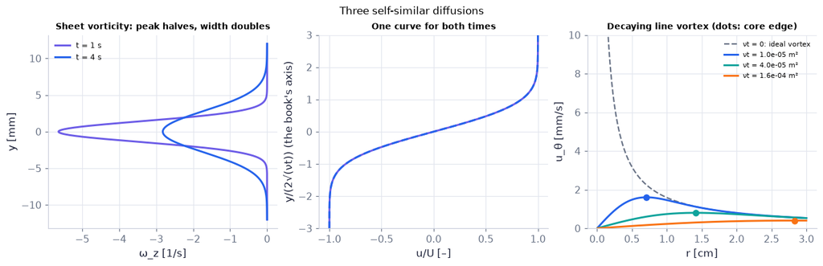

```python
fig, (a1, a2, a3) = plt.subplots(1, 3, figsize=(12, 3.8))   # the figure and its panels
yv = np.linspace(-0.012, 0.012, 400)                      # across the sheet [m]
for t_, c in ((1.0, COLORS["accent"]), (4.0, COLORS["blue"])):   # two times [s]
    u, w = ch08.vortex_sheet_diffusion(yv, t_, 0.01, NU_W)   # Example 8.5 with U = 1 cm/s
    a1.plot(w, 1e3*yv, color=c, lw=2, label=f"t = {t_:g} s")   # a curve (its label says which)
    a2.plot(u/0.01, ch08.similarity_variable(yv, t_, NU_W, half=True), color=c, lw=2, ls="-" if t_ == 1 else "--")   # a curve (its label says which)
a1.set_xlabel("ω_z [1/s]"); a1.set_ylabel("y [mm]"); a1.legend(fontsize=8); a1.set_title("Sheet vorticity: peak halves, width doubles", fontsize=9)   # labels with units
a2.set_ylim(-3, 3); a2.set_xlabel("u/U [–]"); a2.set_ylabel("y/(2√(νt)) (the book's axis)"); a2.set_title("One curve for both times", fontsize=9)   # labels with units
rr = np.linspace(1e-4, 0.03, 300)                          # radius [m]
G0_ = 1e-4                                                 # circulation Γ [m²/s] (ours)
a3.plot(100*rr, 1e3*G0_/(2*np.pi*rr), color=COLORS["muted"], ls="--", lw=1.5, label="νt = 0: ideal vortex")   # a curve (its label says which)
for nt_, c in ((1e-5, COLORS["blue"]), (4e-5, COLORS["teal"]), (1.6e-4, COLORS["orange"])):   # νt [m²] (our values)
    a3.plot(100*rr, 1e3*ch08.line_vortex_decay(rr, nt_/NU_W, G0_, NU_W), color=c, lw=2, label=f"νt = {nt_:.1e} m²")   # a curve (its label says which)
    rc = 2.24*np.sqrt(nt_)                                  # the solid-body core edge ≈ 2.24√(νt)
    a3.plot(100*rc, 1e3*ch08.line_vortex_decay(rc, nt_/NU_W, G0_, NU_W), "o", color=c)   # a curve (its label says which)
a3.set_ylim(0, 10); a3.set_xlabel("r [cm]"); a3.set_ylabel("u_θ [mm/s]"); a3.legend(fontsize=7)   # labels with units
a3.set_title("Decaying line vortex (dots: core edge)", fontsize=9)   # each panel says its message
fig.suptitle("Three self-similar diffusions", fontsize=11)   # the figure's message
savefig(fig, "ch08", "c10_vortex_diffusion"); plt.show() # save the PNG to outputs/ch08, then draw
```

**What you see.** (a) the Gaussian vorticity of the thickening sheet: from 1 s to 4 s the peak halves and the width doubles; (b) both velocity profiles on one curve against the book's axis y/(2√(νt)); (c) the ideal vortex (dashed) smoothed into a solid-body core that grows with νt — our remake of Figs. 8.14–8.15 `N106` (our values of νt, not the book's).

**How to read it.** In (c) the dots mark r ≈ 2.24√(νt), where the speed peaks: inside it the fluid turns like a solid, outside it the speed still falls as Γ/2πr.

**What would change if…** …Γ doubled: every curve in (c) doubles; its shape and the core radius 2.24√(νt) do not change.

```python
nfr = 40 if not FAST else 20                              # frames
tf = np.geomspace(0.5, 50, nfr)                           # a log clock [s]
yv = np.linspace(-0.02, 0.02, 300); rr = np.linspace(1e-4, 0.03, 300)   # across the sheet, and radius [m]
fig, (a1, a2) = plt.subplots(1, 2, figsize=(9, 3.4))     # the figure and its panels
l1, = a1.plot([], [], color=COLORS["blue"], lw=2, label="u/U")   # an empty line to be filled by each frame
l2, = a1.plot([], [], color=COLORS["accent"], lw=2, label="ω/ω_peak(0.5 s)")   # an empty line to be filled by each frame
l3, = a2.plot([], [], color=COLORS["blue"], lw=2)        # an empty line to be filled by each frame
a1.legend(fontsize=7, loc="upper left"); a1.set_xlim(-1.1, 1.1)   # legend
nres = int(0.75*nfr)                                      # the last quarter of the frames switches to rescaled axes
w0 = abs(ch08.vortex_sheet_diffusion(0.0, tf[0], 0.01, NU_W)[1])   # the first frame's peak vorticity [1/s]


def update(i):                                            # frame i
    t_ = tf[i]                                           # the time of this frame [s]
    u, w = ch08.vortex_sheet_diffusion(yv, t_, 0.01, NU_W)   # the sheet at t_
    ut = ch08.line_vortex_decay(rr, t_, 1e-4, NU_W)       # the vortex at t_
    if i < nres:                                          # raw axes
        l1.set_data(u/0.01, 1e3*yv); l2.set_data(w/w0, 1e3*yv); a1.set_ylim(-20, 20); a1.set_ylabel("y [mm]")   # labels with units
        l3.set_data(100*rr, 1e3*ut); a2.set_xlim(0, 3); a2.set_ylim(0, 3); a2.set_xlabel("r [cm]"); a2.set_ylabel("u_θ [mm/s]")   # labels with units
        a1.set_title(f"t = {t_:.2f} s: the sheet thickens", fontsize=9); a2.set_title("the vortex decays", fontsize=9)   # each panel says its message
    else:                                                 # rescaled axes: every profile falls on one curve
        s_ = np.sqrt(NU_W*t_)                            # the diffusion length √(νt) [m]
        l1.set_data(u/0.01, yv/s_); l2.set_data(w/abs(w).max(), yv/s_); a1.set_ylim(-6, 6); a1.set_ylabel("y/√(νt)")   # labels with units
        l3.set_data(rr/s_, ut*2*np.pi*rr/1e-4); a2.set_xlim(0, 10); a2.set_ylim(0, 1.05)   # fixed axis limits
        a2.set_xlabel("r/√(νt)"); a2.set_ylabel("2πr u_θ/Γ")   # labels with units
        a1.set_title(f"t = {t_:.2f} s: rescaled — one curve", fontsize=9); a2.set_title("rescaled — one curve", fontsize=9)   # each panel says its message
    return []                                            # nothing to blit: the artists were changed in place


show_animation(animate(update, frames=nfr, fig=fig, interval=90))   # render the frames (MP4 video or step player)
```

[video not shown]

**What you see.** Left: the vortex sheet's velocity (blue) and vorticity (purple) spreading; right: the line vortex losing its peak. In the last quarter of the movie both switch to rescaled axes and stop changing — the `A5` animation.

**How to read it.** In the rescaled frames the sheet is plotted against y/√(νt) and the vortex as 2πr u_θ/Γ against r/√(νt): if the curves still moved, the similarity form would be wrong.

**What would change if…** …ν were halved: the raw movie runs √2 times slower in space; the rescaled frames are identical.

#### 🎮 Interactive: Where do similarity exponents come from?

**Why interactive rather than a static figure:** Set trial exponents n and m with two sliders: the rescaled profiles collapse onto one curve only at the right values, and the powers of t in the reduced equation turn green when they match — the exponent algebra of Examples 8.4–8.7 as a game you can win or lose.

**What to try:**

- In 'vortex sheet' mode, start at n = 0.4: the curves fan out; slide to 0.5 and watch them merge.
- In 'spreading bead' mode try the diffusion guess m = 1/2 — the bracket chip turns red.
- Switch to 'line vortex': why is the prefactor now a power of r, not of t?
- Check the conserved-integral readout: it is flat only at the right n.

```python
show_viz("ch08", "similarity_exponents")   # full-width explainer; ⤢ Full screen for more room
```

🎮 Interactive 6/9 Where do similarity exponents come from? Open alone ↗

[interactive chart not shown]

📝 **Note.** **N64 [C] · Two kinds of length.** Diffusive lengths grow like $(\nu t)^{1/2}$; the bead's $t^{1/5}$ is not a diffusion length but an advective one — how far the fluid itself has travelled.

**What would change if…** …the wall did not start once but oscillated forever? Then the problem has an imposed time 1/ω; no similarity variable exists, but the diffusion length $\sqrt{\nu/\omega}$ sets the depth (C11).

## 8.5 Flow Due to an Oscillating Plate

**What is this section about?** A plate shaking back and forth in its own plane drags a thin layer of fluid with it. The motion decays and lags with height, looking like a wave travelling away from the wall — but it is diffusion. The depth $\sqrt{2\nu/\omega}$ and the phase structure $(1+i)y/\delta$ are exactly those of tidal bottom boundary layers and of the Ekman layer of Ch. 13.

### 🧩 Stokes' second problem: the Stokes layer `C11`

*The question:* How deep does an oscillation reach into a viscous fluid — and why do the deeper layers lag behind?

*In one line:* $u=U\exp\Big\{-y\sqrt{\frac{\omega}{2\nu}}\Big\}\cos\Big(\omega t-y\sqrt{\frac{\omega}{2\nu}}\Big)$ *(8.38)*

#### The problem in plain words

Shake a plate under water at one cycle per second; the tide rubs the sea floor back and forth twice a day; a sound wave slides air along a wall a thousand times a second. How far above the wall does the fluid feel the shaking, and how late does each layer follow?

#### The idea

```
y = 3δ   ~~ 5 %,  3 rad late
y = 2δ   ~~~ 14 %, 2 rad late
y = δ    ~~~~ 37 %, 1 rad late
y = 0    ◄══►  U cos ωt           δ = δ_e = √(2ν/ω)
```

| shaking | ν [m²/s] | δ_e (computed below) |
| --- | --- | --- |
| plate at 1 Hz in water | 10⁻⁶ | 0.56 mm |
| M₂ tide (12.42 h), molecular ν | 10⁻⁶ | 0.12 m |
| M₂ tide, eddy ν (turbulent) | 10⁻² | 12 m |
| sound at 1 kHz in air | 1.5 × 10⁻⁵ | 0.069 mm |

Each layer repeats the wall's motion, delayed by y/δ radians and shrunk by $e^{-y/\delta}$.

📝 **Note.** **N65 [B], N66 [B], N67 [B] · Set-up.** The plate at y = 0 oscillates in its own plane; we want only the periodic state after start-up transients have died, so there is no initial condition. The equation is (8.20) again, $\frac{\partial u}{\partial t}=\nu\frac{\partial^2u}{\partial y^2}$, but now the wall imposes a time scale 1/ω, through the wall condition (8.33) below and $u(y\to\infty,t)=\text{bounded}$ *(8.34)*.

$$ u(y=0,t)=U\cos(\omega t) \qquad \text{(8.33)} $$

> ⚠️ **Common confusion:** ω is now a **frequency** [rad/s] (as in Ch. 7), not a vorticity.

> 🔁 **Tools from earlier chapters used here** (see `knowledge/primers.md`)
- **complex exponential solution, taking the real part** — write the wall motion as $\mathrm{Re}\{Ue^{i\omega t}\}$; for a linear equation with real coefficients we can solve with the complex form and take the real part at the end (Ch. 7 P176, complex amplitudes).
- **square root of i** — $\sqrt i=(1+i)/\sqrt2$, since $((1+i)/\sqrt2)^2=(1+2i-1)/2=i$ (Ch. 6 P159, complex square roots).
- **Euler's formula, i² = −1** — $e^{i\theta}=\cos\theta+i\sin\theta$, so $\mathrm{Re}\{e^{i\theta}\}=\cos\theta$ (Ch. 1 P45).

```python
print(np.sqrt(1j), (1 + 1j)/np.sqrt(2))                  # both (0.7071+0.7071j): the square root of i
```

```
(0.7071067811865476+0.7071067811865475j) (0.7071067811865475+0.7071067811865475j)
```

📝 **Note.** **N68 [B], N69 [B], N70 [B], N71 [B] · The complex route.** **N68** The complex trial is (8.35) below. ⚠️ The text then says "substitution of (8.33), $u(y=0,t)=U\cos(\omega t)$ into (8.20), $\frac{\partial u}{\partial t}=\nu\frac{\partial^2u}{\partial y^2}$"; it is (8.35) that is substituted. **N69** It turns (8.20) into $i\omega f=\nu\frac{d^2f}{dy^2}$ *(8.36)*. **N70** $f=e^{ky}$ with $k=(i\omega/\nu)^{1/2}=\pm(i+1)(\omega/2\nu)^{1/2}$. **N71** The general solution is (8.37); bounded ⇒ B = 0, wall ⇒ A = U.

$$ u(y,t)=\mathrm{Re}\{e^{i\omega t}f(y)\}\ \ \text{(8.35)},\qquad f(y)=A\exp\{-(i+1)y\sqrt{\omega/2\nu}\}+B\exp\{+(i+1)y\sqrt{\omega/2\nu}\}\ \ \text{(8.37)} $$

#### 🧮 Derivation — Stokes' second problem: $u=Ue^{-y\sqrt{\omega/2\nu}}\cos(\omega t-y\sqrt{\omega/2\nu})$ `D24` (Eq. 8.38: $u=U\exp\Big\{-y\sqrt{\frac{\omega}{2\nu}}\Big\}\cos\Big(\omega t-y\sqrt{\frac{\omega}{2\nu}}\Big)$)

**What we want to show.** Find the periodic flow above a plate oscillating as U cos ωt.

**Assumptions.** Periodic steady state (transients gone) — step 1.

**The plan.**

1. Complex form.
2. ODE in y.
3. Exponential roots with √i.
4. Pick the bounded root, fix the amplitude, take the real part.

**Tools we use** (each explained before this point): complex exponential solution (gloss, P176) · complex square roots (P159) · linear ODE and $e^{\lambda y}$ (P44).

**We start from**

$$ \frac{\partial u}{\partial t}=\nu\frac{\partial^2u}{\partial y^2}\ \text{(8.20),}\ u(y=0,t)=U\cos(\omega t)\ \text{(8.33), u bounded as y → ∞ (8.34).} $$

**Step 1 of 10 — Try the complex form.**

$$ u(y,t)=\mathrm{Re}\{e^{i\omega t}f(y)\}\ \text{(8.35)} $$

- *Why we can do this:* The wall motion is Re{$Ue^{i\omega t}$}; (8.20), $\frac{\partial u}{\partial t}=\nu\frac{\partial^2u}{\partial y^2}$ is linear with real coefficients, so we solve for ũ = $e^{i\omega t}$f and take the real part at the end.
- *In words:* every layer oscillates at the wall's frequency.

**Step 2 of 10 — Differentiate ũ.**

$$ \frac{\partial\tilde u}{\partial t}=i\omega e^{i\omega t}f,\ \ \frac{\partial^2\tilde u}{\partial y^2}=e^{i\omega t} f'' $$

- *Why we can do this:* d/dt $e^{i\omega t}$ = iω$e^{i\omega t}$; y enters only through f.
- *In words:* time derivative → multiplication by iω.

**Step 3 of 10 — Substitute and cancel $e^{i\omega t}$.**

$$ i\omega f=\nu\frac{d^2f}{dy^2}\ \text{(8.36)} $$

- *Why we can do this:* $e^{i\omega t}$ ≠ 0. The text says "substitution of (8.33)" — it is (8.35), $u(y,t)=\mathrm{Re}\{e^{i\omega t}f(y)\}$ that is substituted.
- *In words:* (8.36), $i\omega f=\nu\frac{d^2f}{dy^2}$, an ODE with constant coefficients.

**Step 4 of 10 — Try f = $e^{ky}$.**

$$ i\omega=\nu k^2\ \Rightarrow\ k^2=\frac{i\omega}{\nu} $$

- *Why we can do this:* The standard trial for constant coefficients (P44).
- *In words:* k is a complex square root.

**Step 5 of 10 — Take the square root of i.**

$$ k=\pm\frac{1+i}{\sqrt2}\sqrt{\frac\omega\nu}=\pm(1+i)\sqrt{\frac{\omega}{2\nu}} $$

- *Why we can do this:* ((1 + i)/√2)² = (1 + 2i − 1)/2 = i (P159).
- *In words:* decay and oscillation at the same rate.

**Step 6 of 10 — Write the general solution.**

$$ f=A\exp\{-(i+1)y\sqrt{\omega/2\nu}\}+B\exp\{+(i+1)y\sqrt{\omega/2\nu}\}\ \text{(8.37)} $$

- *Why we can do this:* The ODE is linear, so any combination of the two exponential solutions is a solution.
- *In words:* (8.37), $f(y)=A\exp\{-(i+1)y\sqrt{\omega/2\nu}\}+B\exp\{+(i+1)y\sqrt{\omega/2\nu}\}$.

**Step 7 of 10 — Discard the growing root.**

$$ B=0 $$

- *Why we can do this:* The second exponential grows like $e^{+y\sqrt (\omega /2\nu )}$, violating (8.34), $u(y\to\infty,t)=\text{bounded}$.
- *In words:* only the decaying layer survives.

**Step 8 of 10 — Match the wall motion.**

$$ \tilde u(0,t)=Ae^{i\omega t}\ \Rightarrow\ A=U $$

- *Why we can do this:* Re{$Ae^{i\omega t}$} must be U cos ωt for all t.
- *In words:* amplitude fixed.

**Step 9 of 10 — Name the depth.**

$$ \tilde u=Ue^{-y/\delta_e}e^{i(\omega t-y/\delta_e)},\ \ \delta_e=\sqrt{2\nu/\omega} $$

- *Why we can do this:* Split $e^{-(1+i)y/\delta _e}$ into a real decay and a phase.
- *In words:* amplitude and phase both change with y.

**Step 10 of 10 — Take the real part.**

$$ u(y,t)=Ue^{-y\sqrt{\omega/2\nu}}\cos\big(\omega t-y\sqrt{\omega/2\nu}\big)\ \text{(8.38)} $$

- *Why we can do this:* Take the real part as promised in step 1: Re{e^(iθ)} = cos θ with θ = ωt − y/δ_e.
- *In words:* (8.38), $u=U\exp\Big\{-y\sqrt{\frac{\omega}{2\nu}}\Big\}\cos\Big(\omega t-y\sqrt{\frac{\omega}{2\nu}}\Big)$.

**Result**

$$ u=U\exp\Big\{-y\sqrt{\frac{\omega}{2\nu}}\Big\}\cos\Big(\omega t-y\sqrt{\frac{\omega}{2\nu}}\Big)\ \text{(8.38)} $$

*In words:* each layer repeats the wall's motion, shrunk by $e^{-y/\delta _e}$ and delayed by y/δ_e radians.

**What it means.** The same (1 + i)/δ structure gives the Ekman spiral (Ch. 13) and tidal bottom layers.

**Check it.** u(0, t) = U cos ωt ✓; bounded ✓; residual of (8.20), $\frac{\partial u}{\partial t}=\nu\frac{\partial^2u}{\partial y^2}$ zero (`stokes_second_sympy`); the CN twin after 10 periods agrees to 2 × 10⁻³U.

> ⚠️ **Common confusion (traps in `D24`):** ∂/∂t of $e^{i\omega t}$f is iω$e^{i\omega t}$f; keep only the decaying root; the phase lag carries a minus sign.

```python
s2 = ch08.stokes_second_sympy()                          # D24 in sympy
print("roots k:", s2["k_roots"], "  bounded:", s2["bounded_root"])
print("residual of (8.20) for (8.38):", s2["residual"])  # 0
```

```
roots k: [-sqrt(I)*sqrt(omega)/sqrt(nu), sqrt(I)*sqrt(omega)/sqrt(nu)]   bounded: -sqrt(2)*sqrt(omega)*(1 + I)/(2*sqrt(nu))
residual of (8.20) for (8.38): 0
```

📝 **Note.** **N72 [B] · Reading (8.38), $u=U\exp\Big\{-y\sqrt{\frac{\omega}{2\nu}}\Big\}\cos\Big(\omega t-y\sqrt{\frac{\omega}{2\nu}}\Big)$.** The cosine moves toward +y — it looks like a damped transverse wave — but there is no restoring force: it is diffusion driven by a periodic wall. At $y=4(\nu/\omega)^{1/2}$ the amplitude is $Ue^{-4/\sqrt2}$ (0.05911U, printed by the code below), so the book calls $\delta\sim4(\nu/\omega)^{1/2}$ the layer thickness; the literature's e-folding depth is $\delta_e=\sqrt{2\nu/\omega}$, 2√2 = 2.83 times smaller (ours: crests move at $\sqrt{2\nu\omega}$, "wavelength" $2\pi\delta_e$).

> 🔁 **Tools from earlier chapters used here** (see `knowledge/primers.md`)
- **phase of a cosine and a time lag** — in cos(ωt − φ) the phase lag φ [rad] means the peak comes φ/ω seconds later (Ch. 7 P165, phase of a wave).

#### 🧮 Derivation — Reading $u=Ue^{-y/\delta_e}\cos(\omega t-y/\delta_e)$: 0.059U at 4√(ν/ω), crest speed √(2νω), e-folding depth √(2ν/ω) `D25`

**What we want to show.** Turn (8.38), $u=U\exp\Big\{-y\sqrt{\frac{\omega}{2\nu}}\Big\}\cos\Big(\omega t-y\sqrt{\frac{\omega}{2\nu}}\Big)$ into numbers a reader can picture: how deep, how late, how fast the apparent wave moves.

**Assumptions.** None.

**The plan.**

1. Envelope.
2. The book's depth.
3. Phase lag and crest speed.

**Tools we use** (each explained before this point): phase of a wave (P165) · exponent rules (P43).

**We start from**

$$ u=Ue^{-y/\delta_e}\cos(\omega t-y/\delta_e),\quad \delta_e=\sqrt{2\nu/\omega}\ \ \text{(8.38)} $$

*In words:* Stokes' second problem written with the e-folding depth

**Step 1 of 6 — Read the envelope.**

$$ \lvert u\rvert\le Ue^{-y/\delta_e} $$

- *Why we can do this:* The cosine is at most 1; δ_e is the e-folding depth.
- *In words:* the motion shrinks by e every δ_e.

**Step 2 of 6 — Evaluate at the book's depth.**

$$ y=4\sqrt{\nu/\omega}:\ \ \frac{y}{\delta_e}=\frac{4}{\sqrt2}=2\sqrt2,\ \ e^{-2\sqrt2}= 0.0591 $$

- *Why we can do this:* 4√(ν/ω)/√(2ν/ω) = 4/√2. The book's δ ~ 4√(ν/ω) is 2√2 = 2.83 δ_e.
- *In words:* 6 % of the wall's motion left.

**Step 3 of 6 — Read the phase lag.**

$$ \phi(y)=\frac{y}{\delta_e}\ \text{rad},\ \ \Delta t=\frac{y}{\omega\delta_e} $$

- *Why we can do this:* The cosine's argument is ωt − y/δ_e: a layer at y reaches the same phase y/δ_e radians later.
- *In words:* deeper layers lag.

**Step 4 of 6 — Follow a crest.**

$$ \omega t-\frac{y}{\delta_e}=\text{const}\ \Rightarrow\ \frac{dy}{dt}=\omega\delta_e=\sqrt{2\nu\omega} $$

- *Why we can do this:* A point of fixed phase moves; differentiate in t.
- *In words:* crests climb at √(2νω).

**Step 5 of 6 — Read the 'wavelength'.**

$$ \lambda=2\pi\delta_e $$

- *Why we can do this:* The phase changes by 2π over Δy = 2πδ_e — but the amplitude has fallen by $e^{-2π}$ ≈ 0.2 % by then.
- *In words:* barely one 'wave' is ever visible.

**Step 6 of 6 — Put in numbers.**

$$ \omega=2\pi,\ \nu=10^{-6}:\ \ \delta_e=0.56\ \mathrm{mm},\ \ 4\sqrt{\nu/\omega}=1.6\ \mathrm{mm},\ \ \sqrt{2\nu \omega}=3.5\ \mathrm{mm/s} $$

- *Why we can do this:* Direct evaluation with ω = 2π rad/s (1 Hz) and water's ν = 10⁻⁶ m²/s.
- *In words:* a plate shaken once a second in water moves only a millimetre of fluid.

**Result**

$$ \delta_e=\sqrt{\frac{2\nu}{\omega}},\quad \frac{\lvert u\rvert_{max}}{U}\Big\rvert_{y=4\sqrt{\nu/\omega}}=e^{-2\sqrt2}=0.0591,\quad \phi=\frac{y}{\delta_e},\quad \frac{dy}{dt}\Big\rvert_{crest}=\sqrt{2\nu\omega} $$

*In words:* a diffusion layer with a phase delay.

**What it means.** It looks like a wave, but there is no restoring force: the pattern is diffusion from a periodic boundary.

**Check it.** Units: √(m²/s ÷ 1/s) = m ✓; √(m²/s × 1/s) = m/s ✓.

> ⚠️ **Common confusion (traps in `D25`):** Book depth (4√(ν/ω)) and e-folding depth (√(2ν/ω)) differ by 2√2; calling it a real wave.

#### ✏️ Tiny example: a plate shaken once a second in water

ω = 2π rad/s, ν = 10⁻⁶ m²/s, U = 0.1 m/s.

1. $\delta_e=\sqrt{2\nu/\omega}=\sqrt{2\times10^{-6}/6.283}=5.64\times10^{-4}$ m = 0.56 mm.
2. Book depth $4\sqrt{\nu/\omega}=1.60$ mm.
3. At y = 1 mm: amplitude $e^{-1/0.564}=e^{-1.77}=0.17$ → 1.7 cm/s; phase lag 1.77 rad, i.e. 1.77/(2π) × 1 s = 0.28 s late.
4. Crest speed $\omega\delta_e=3.5$ mm/s.
5. Shake 100× faster: every length shrinks 10×.

```python
y = np.array([0.0, 0.5e-3, 1e-3, 2e-3])                  # four heights [m]
print("u(t = 0) =", ch08.stokes_second_problem(y, 0.0, U=0.1, omega=2*np.pi, nu=NU_W), "m/s")   # (8.38)
sl = ch08.stokes_layer(NU_W, 2*np.pi)                    # depths and speeds of the 1 Hz layer
print({k: f"{sl[k]:.4g}" for k in ("delta_e", "delta_book", "phase_speed", "wavelength", "amplitude_at_delta_book")})
ss = ch08.stokes_layer_state(NU_W, 2*np.pi, 1e-3)        # what the layer does at y = 1 mm
print({k: f"{ss[k]:.4g}" for k in ("amplitude", "phase_lag", "time_lag")})
print(f"e^(−2√2) = {np.exp(-2*np.sqrt(2)):.5f}")          # N72's amplitude at the book's depth
wM2 = 2*np.pi/(12.42*3600)                               # the M₂ tide's frequency [rad/s]
print(f"M2 tide: δ_e = {ch08.stokes_layer(1e-6, wM2)['delta_e']:.3f} m (molecular ν), {ch08.stokes_layer(1e-2, wM2)['delta_e']:.1f} m (eddy ν)")
print(f"sound at 1 kHz in air: δ_e = {1e3*ch08.stokes_layer(1.5e-5, 2*np.pi*1e3)['delta_e']:.3f} mm")
for g_ in ch01.pi_groups({"u": "m/s", "U": "m/s", "y": "m", "t": "s", "nu": "m^2/s", "omega": "1/s"}):   # N73's groups
    print("  group:", " · ".join(f"{k}^{v}" for k, v in g_.items() if v != 0))
```

```
u(t = 0) = [ 0.1     0.0261 -0.0034 -0.0027] m/s
{'delta_e': '0.0005642', 'delta_book': '0.001596', 'phase_speed': '0.003545', 'wavelength': '0.003545', 'amplitude_at_delta_book': '0.05911'}
{'amplitude': '0.1699', 'phase_lag': '1.772', 'time_lag': '0.2821'}
e^(−2√2) = 0.05911
M2 tide: δ_e = 0.119 m (molecular ν), 11.9 m (eddy ν)
sound at 1 kHz in air: δ_e = 0.069 mm
  group: u^1 · U^-1
  group: t^1 · U^1 · y^-1
  group: nu^1 · U^-1 · y^-1
  group: omega^1 · U^-1 · y^1
```

**What does the code above do?**

```python
de = np.sqrt(2*NU_W/(2*np.pi)); t_ = 0.3                  # e-folding depth [m] and a time [s]
u_mine = np.real(0.1*np.exp(1j*2*np.pi*t_)*np.exp(-(1 + 1j)*y/de))   # Re{U e^{iωt} e^{−(1+i)y/δ_e}} (D24 steps 9–10)
assert np.allclose(u_mine, ch08.stokes_second_problem(y, t_, U=0.1, omega=2*np.pi, nu=NU_W), rtol=1e-12, atol=1e-15)
T = 1.0; nper = 10 if not FAST else 5                    # period [s] and number of periods to march from rest
yy = np.linspace(0, 20*de, 201)                          # 20 e-folding depths: the far end sees nothing [m]
u_num = ch08.crank_nicolson_1d(np.zeros(201), yy, T/200, 200*nper, NU_W, lambda tt: 0.1*np.cos(2*np.pi*tt), 0.0)   # from rest
err = np.max(np.abs(u_num - ch08.stokes_second_problem(yy, nper*T, U=0.1, omega=2*np.pi, nu=NU_W))[yy <= 6*de])
print(f"Crank–Nicolson from rest after {nper} periods vs (8.38): max error {err/0.1:.1e} U within 6δ_e")
assert err < 2e-3*0.1                                    # the start-up transient has died: the periodic state is (8.38)
```

```
Crank–Nicolson from rest after 10 periods vs (8.38): max error 2.6e-04 U within 6δ_e
```

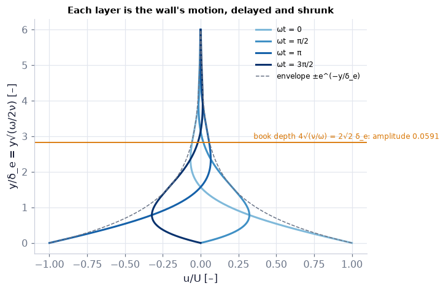

```python
yd = np.linspace(0, 6, 300)                               # y/δ_e = y√(ω/2ν), the book's axis [–]
fig, ax = plt.subplots(figsize=(6.5, 4.2))               # the figure and its panels
for k, wt in enumerate((0, np.pi/2, np.pi, 3*np.pi/2)):  # four phases of the wall
    u = ch08.stokes_second_problem(yd*de, wt/(2*np.pi), U=1.0, omega=2*np.pi, nu=NU_W)   # (8.38) with U = 1
    ax.plot(u, yd, color=plt.cm.Blues(0.45 + 0.18*k), lw=2, label=f"ωt = {['0', 'π/2', 'π', '3π/2'][k]}")   # a curve (its label says which)
ax.plot(np.exp(-yd), yd, color=COLORS["muted"], ls="--", lw=1, label="envelope ±e^(−y/δ_e)")   # a curve (its label says which)
ax.plot(-np.exp(-yd), yd, color=COLORS["muted"], ls="--", lw=1)   # a curve (its label says which)
yb = 2*np.sqrt(2)                                          # the book's depth 4√(ν/ω) in units of δ_e
ax.axhline(yb, color=COLORS["amber"], lw=1.2)            # reference line
ax.text(0.35, yb + 0.1, f"book depth 4√(ν/ω) = 2√2 δ_e: amplitude {np.exp(-yb):.4f}", color=COLORS["amber"], fontsize=8)   # a label on the plot
ax.set_xlabel("u/U [–]"); ax.set_ylabel("y/δ_e = y√(ω/2ν) [–]"); ax.legend(fontsize=8, loc="upper right")   # labels with units
ax.set_title("Each layer is the wall's motion, delayed and shrunk", fontsize=10)   # each panel says its message
savefig(fig, "ch08", "c11_stokes_layer"); plt.show()     # save the PNG to outputs/ch08, then draw
```

**What you see.** Four S-shaped profiles (one per quarter period) inside a narrowing funnel, the envelope $\pm e^{-y/\delta_e}$; the amber line is the book's depth 4√(ν/ω), where 0.0591 of the motion is left — our remake of Fig. 8.16 (part of `N107`).

**How to read it.** At any height the spread of the curves is the local amplitude; the height where a curve crosses zero moves up with ωt — that is the apparent "wave".

**What would change if…** …the fluid were ten times more viscous: all lengths grow √10 ≈ 3.2 times; in these rescaled axes nothing moves.

```python
nfr = 40 if not FAST else 20                              # frames (two periods)
tf = np.linspace(0, 2.0, nfr)                             # time [s], 1 Hz plate
de = np.sqrt(2*NU_W/(2*np.pi))                            # e-folding depth [m]
yv = np.linspace(0, 5*de, 150)                            # heights [m]
ytr = de*np.array([0.0, 0.5, 1.0, 1.5, 2.0, 3.0])         # six tracer heights [m]
xs0 = np.linspace(0, 1, 6)                                # their resting x positions [schematic units]
fig, (a1, a2) = plt.subplots(1, 2, figsize=(9, 3.4), sharey=True)
trac = a1.scatter(xs0, 1e3*ytr, c=[COLORS["teal"]]*6, s=40, zorder=3)   # tracers
dye, = a1.plot(np.zeros(150), 1e3*yv, color=COLORS["blue"], lw=2)      # a dyed vertical line
plate, = a1.plot([-0.2, 1.2], [0, 0], color=COLORS["ink"], lw=5)       # the plate
a1.set_xlim(-0.5, 1.5); a1.set_ylim(-0.1, 1e3*5*de); a1.set_xlabel("x (displacement × 50, schematic)"); a1.set_ylabel("y [mm]")
prof, = a2.plot([], [], color=COLORS["blue"], lw=2)
a2.plot(np.exp(-yv/de), 1e3*yv, color=COLORS["muted"], ls="--", lw=1); a2.plot(-np.exp(-yv/de), 1e3*yv, color=COLORS["muted"], ls="--", lw=1)
probe, = a2.plot([], [], "o", color=COLORS["orange"], ms=8)            # probe at y = δ_e
a2.set_xlim(-1.1, 1.1); a2.set_xlabel("u/U [–]")
Dp = lambda y_, t_: np.imag(np.exp(1j*2*np.pi*t_)*np.exp(-(1 + 1j)*y_/de))/(2*np.pi)   # displacement ∫u dt for U = 1 [m·s/m]


def update(i):                                            # frame i
    t_ = tf[i]                                           # the time of this frame [s]
    u = ch08.stokes_second_problem(yv, t_, U=1.0, omega=2*np.pi, nu=NU_W)   # (8.38) with U = 1
    prof.set_data(u, 1e3*yv)
    probe.set_data([ch08.stokes_second_problem(de, t_, U=1.0, omega=2*np.pi, nu=NU_W)], [1e3*de])
    dye.set_xdata(0.5 + 3*Dp(yv, t_))                     # the dye line bends with the lagging layers (displacement × 3)
    trac.set_offsets(np.c_[xs0 + 3*Dp(ytr, t_), 1e3*ytr]) # tracers oscillate with growing lag
    plate.set_xdata(np.array([-0.2, 1.2]) + 3*Dp(0.0, t_))   # the plate itself
    a1.set_title(f"t = {t_:.2f} s (1 Hz plate)", fontsize=10); a2.set_title("profile and probe at y = δ_e", fontsize=10)
    return []                                            # nothing to blit: the artists were changed in place


show_animation(animate(update, frames=nfr, fig=fig, interval=60))
```

[video not shown]

**What you see.** Left: tracers at six heights and a dyed line oscillating with the plate, each layer later and smaller than the one below; right: the profile swinging inside its envelope, with an orange probe at y = δ_e — the `A2` animation.

**How to read it.** The probe moves e⁻¹ = 37 % as far as the plate and peaks 1 rad (0.16 s) later; the dye line is an S that travels upward — the apparent wave of (8.38), $u=U\exp\Big\{-y\sqrt{\frac{\omega}{2\nu}}\Big\}\cos\Big(\omega t-y\sqrt{\frac{\omega}{2\nu}}\Big)$.

**What would change if…** …the probe moved to 2δ_e: its dot would move e⁻² = 14 % as far and peak 2 rad later.

```python
de = np.sqrt(2*NU_W/(2*np.pi))                            # e-folding depth [m]
yd = np.linspace(0, 6, 120)                               # y/δ_e [–]


def frame(wt):                                            # curves at phase ωt
    return {"u/U, (8.38)": (ch08.stokes_second_problem(yd*de, wt/(2*np.pi), U=1.0, omega=2*np.pi, nu=NU_W), yd),   # the curves of this position
            "envelope +": (np.exp(-yd), yd), "envelope −": (-np.exp(-yd), yd)}   # (continued)


fig = animate_figure(frame, np.linspace(0, 2*np.pi, 25 if not FAST else 12), time_label="ωt", unit="rad",   # precompute every slider/time position
                     xlabel="u/U [–]", ylabel="y/δ_e [–]", title="The Stokes layer through one period", xrange=[-1.05, 1.05], yrange=[0, 6])   # (continued)
recolor(fig, {"u/U, (8.38)": COLORS["blue"], "envelope +": COLORS["muted"], "envelope −": COLORS["muted"]},   # colours by meaning (as in the static figures)
        {"envelope +": "dash", "envelope −": "dash"})    # (continued)
fig.show()                                               # draw the interactive figure
```

[interactive chart not shown]

**What does the code above do?**

The page-surviving version of the animation: Play runs one period of (8.38), $u=U\exp\Big\{-y\sqrt{\frac{\omega}{2\nu}}\Big\}\cos\Big(\omega t-y\sqrt{\frac{\omega}{2\nu}}\Big)$ inside its envelope.

#### 🎮 Interactive: How deep does a shaking plate reach?

**Why interactive rather than a static figure:** The animation shows the phase lag and the envelope together; drag ω and the layer shrinks while the 0.059U marker at 4√(ν/ω) follows, and a probe clock shows a deep layer peaking later — none of which a four-phase static figure makes vivid.

**What to try:**

- Play the 1 Hz preset and click at y = 1 mm: read the amplitude and the time lag.
- Switch to the M₂ tide with molecular and then eddy viscosity: 12 cm versus 12 m.
- Double ω and predict δ_e before you look (it falls by √2).
- Open the 'Right now' notes: which real Stokes layer is closest to your setting?

```python
show_viz("ch08", "oscillating_plate")   # full-width explainer; ⤢ Full screen for more room
```

🎮 Interactive 7/9 How deep does a shaking plate reach? Open alone ↗

[interactive chart not shown]

📝 **Note.** **N74 [C] · Where the Stokes layer reappears.** The same layer explains why sound is weakly absorbed at flat walls: the viscous acoustic boundary layer (Ch. 15). For the climate thread: replace the plate's oscillation by the Coriolis force and the (1 + i)/δ structure of (8.37), $f(y)=A\exp\{-(i+1)y\sqrt{\omega/2\nu}\}+B\exp\{+(i+1)y\sqrt{\omega/2\nu}\}$ becomes the Ekman spiral (Ch. 13).

**What would change if…** …the plate stood still and a sphere moved slowly through the fluid instead? Then there is no single wall-normal direction and the flow is 3-D; for tiny Reynolds numbers inertia vanishes altogether and the equations become linear again (C12).

## 8.6 Low Reynolds Number Viscous Flow Past a Sphere

**What is this section about?** Tiny, slow things — cloud droplets, silt, bacteria, a bead sinking in syrup — live at Reynolds numbers far below one. We find the right way to drop inertia (pressure must be rescaled, not dropped), solve the resulting linear Stokes equations for a sphere, integrate the surface stresses to Stokes' drag $D=6\pi\mu aU$, and use it for the fall speed of droplets and for Millikan's measurement of the electron's charge. Finally we see why the solution fails far from the sphere and how Oseen repaired it.

> 🔁 **Recap — Steady Navier–Stokes** (Ch. 4 §4.6). For steady flow round a body of size L at speed U: $\rho\mathbf u\cdot\nabla\mathbf u+\nabla p=\mu\nabla^2\mathbf u$ *(8.39)* — Ch. 4's $\rho\frac{D\mathbf u}{Dt}=-\nabla p+\rho\mathbf g+\mu\nabla^2\mathbf u$ *(4.39b)* without the time derivative and with gravity absorbed into p.

> 🔁 **Recap — The high-Re scaling** (Ch. 4 §4.11). With $u^*=u/U$, $x^*=x/L$ and $p^*=(p-p_\infty)/\rho U^2$ *(4.100)*, (8.39), $\rho\mathbf u\cdot\nabla\mathbf u+\nabla p=\mu\nabla^2\mathbf u$ becomes $\mathbf u^*\cdot\nabla^*\mathbf u^*+\nabla^*p^*=\frac{1}{\mathrm{Re}}\nabla^{*2}\mathbf u^*$ *(8.40)*, Re = ρUL/μ; for Re ≫ 1 the viscous term looks negligible (Euler, Ch. 6).

```python
print(SIM.nondimensional_ns_coefficients("dynamic", "advective"))   # pressure scaled by ρU²: viscous coefficient μ/(ρUl) = 1/Re
print(SIM.nondimensional_ns_coefficients("viscous", "advective"))   # pressure scaled by μU/l: pressure coefficient μ/(ρUl) too
```

```
{'unsteady': 1, 'advective': 1, 'pressure': 1, 'gravity': g*l/U**2, 'viscous': mu/(U*l*rho)}
{'unsteady': 1, 'advective': 1, 'pressure': mu/(U*l*rho), 'gravity': g*l/U**2, 'viscous': mu/(U*l*rho)}
```

### 🧩 Creeping flow: the Stokes equations `C12`

*The question:* Which terms survive when Re → 0 — and why does pressure not disappear together with inertia?

*In one line:* $\nabla p=\mu\nabla^2\mathbf u$ *(8.43)*

#### The problem in plain words

A bacterium swims at a few body lengths per second; a grain of silt sinks through a river; a mist droplet drifts down. For them Re = UL/ν ≪ 1. Inertia is negligible — but if we simply multiply (8.40), $\mathbf u^*\cdot\nabla^*\mathbf u^*+\nabla^*p^*=\frac{1}{\mathrm{Re}}\nabla^{*2}\mathbf u^*$ by Re and let it go to zero, the pressure disappears too, and the resulting equation cannot hold a sphere in a stream. What went wrong, and what is the right limit?

#### The idea

| regime | pressure balances | pressure scale | dimensionless form |
| --- | --- | --- | --- |
| Re ≫ 1 | inertia | ρU² | $\mathbf u^*\cdot\nabla^*\mathbf u^*+\nabla^*p^*=\frac{1}{\mathrm{Re}}\nabla^{*2}\mathbf u^*$ *(8.40)* |
| Re ≪ 1 | viscous stress | μU/L | $\mathrm{Re}\,(\mathbf u^*\cdot\nabla^*\mathbf u^*)=-\nabla^*p^*+\nabla^{*2}\mathbf u^*$ *(8.42)* |

The size of pressure differences is set by whatever they balance.

📝 **Note.** **N75 [C], N76 [C] · Expansions in a parameter.** **N75** Many problems are solved as expansions in a small or large parameter (here Re); Ch. 9 (1/Re) and Ch. 11 (small disturbances) do the same. **N76** At high Re the expansion in 1/Re fails near walls, where the inviscid solution cannot satisfy no slip — the boundary layer of Ch. 9; the two-length scaling (8.14), $x^*=\frac xL,\ y^*=\frac yh=\frac{y}{\varepsilon L},\ t^*=\frac{Ut}{L},\ u^*=\frac uU,\ v^*=\frac{v}{\varepsilon U},\ p^*=\frac{p}{P_a}$ of C05 was the hint.

> 📎 **Primer — dominant balance.** `P198` · Choose the scale of a quantity from the term it must balance. If pressure differences are pushed by viscous stresses, then $p-p_\infty\sim\mu U/L$, not ρU²; picking the wrong scale makes a term look negligible when it is not.

```python
mu, U, L, rho = 1e-3, 1e-3, 1e-5, 1000.0                 # a 10 µm particle at 1 mm/s in water
print(rho*U**2, mu*U/L)                                  # dynamic 1e-3 Pa vs viscous 0.1 Pa: pressure is viscous here
```

```
0.001 0.09999999999999999
```

📝 **Note.** **N77 [B], N78 [B], N79 [B] · The two scalings.** **N77** Multiplying (8.40), $\mathbf u^*\cdot\nabla^*\mathbf u^*+\nabla^*p^*=\frac{1}{\mathrm{Re}}\nabla^{*2}\mathbf u^*$ by Re gives (8.41): as Re → 0 it leaves 0 = μ∇²u — pressure lost too. **N78** The low-Re pressure scale is $p^*=(p-p_\infty)L/(\mu U)$. **N79** It gives (8.42), whose Re → 0 limit is (8.43), $\nabla p=\mu\nabla^2\mathbf u$.

$$ \mathrm{Re}\,(\mathbf u^*\cdot\nabla^*\mathbf u^*+\nabla^*p^*)=\nabla^{*2}\mathbf u^*\ \ \text{(8.41)},\qquad \mathrm{Re}\,(\mathbf u^*\cdot\nabla^*\mathbf u^*)=-\nabla^*p^*+\nabla^{*2}\mathbf u^*\ \ \text{(8.42)} $$

#### 🧮 Derivation — From $\rho\mathbf u\cdot\nabla\mathbf u+\nabla p=\mu\nabla^2\mathbf u$ to the Stokes equations $\nabla p=\mu\nabla^2\mathbf u$ `D26` (Eq. 8.43: $\nabla p=\mu\nabla^2\mathbf u$)

**What we want to show.** Show how to drop inertia correctly when Re → 0, and why pressure must be rescaled.

**Assumptions.** Steady, no body force; Re → 0 at the end.

**The plan.**

1. Scale with the high-Re pressure (4.100), $x_i^*=\frac{x_i}{l},\ u_j^*=\frac{u_j}{U},\ p^*=\frac{p-p_\infty}{\rho U^2}$.
2. Multiply by Re and see the failure.
3. Rescale pressure by dominant balance.
4. Take the limit.

**Tools we use** (each explained before this point): scaled variables (P133) · dominant balance (primer P198).

**We start from**

$$ \rho\mathbf u\cdot\nabla\mathbf u+\nabla p=\mu\nabla^2\mathbf u\ \text{(8.39).} $$

**Step 1 of 9 — Scale with the dynamic pressure.**

$$ \mathbf u=U\mathbf u^*,\ \mathbf x=L\mathbf x^*,\ p-p_\infty=\rho U^2p^* $$

- *Why we can do this:* The scaling (4.100), $x_i^*=\frac{x_i}{l},\ u_j^*=\frac{u_j}{U},\ p^*=\frac{p-p_\infty}{\rho U^2}$, natural when inertia balances pressure.
- *In words:* the high-Re yardsticks.

**Step 2 of 9 — Size each term.**

$$ \frac{\rho U^2}{L}\mathbf u^*\cdot\nabla^*\mathbf u^*+\frac{\rho U^2}{L}\nabla^*p^*=\frac{\mu U}{L^2}\nabla^{*2} \mathbf u^* $$

- *Why we can do this:* ∇ = ∇*/L; two derivatives on the viscous term.
- *In words:* inertia and pressure ~ ρU²/L, friction ~ μU/L².

**Step 3 of 9 — Divide by ρU²/L.**

$$ \mathbf u^*\cdot\nabla^*\mathbf u^*+\nabla^*p^*=\frac{1}{\mathrm{Re}}\nabla^{*2}\mathbf u^*\ \text{(8.40)} $$

- *Why we can do this:* Divide every term by ρU²/L; the viscous coefficient (μU/L²)/(ρU²/L) = μ/(ρUL) = 1/Re.
- *In words:* (8.40), $\mathbf u^*\cdot\nabla^*\mathbf u^*+\nabla^*p^*=\frac{1}{\mathrm{Re}}\nabla^{*2}\mathbf u^*$.

**Step 4 of 9 — Multiply by Re.**

$$ \mathrm{Re}(\mathbf u^*\cdot\nabla^*\mathbf u^*+\nabla^*p^*)=\nabla^{*2}\mathbf u^*\ \text{(8.41)} $$

- *Why we can do this:* Look at the low-Re end: the viscous term now has coefficient 1.
- *In words:* (8.41), $\mathrm{Re}\,(\mathbf u^*\cdot\nabla^*\mathbf u^*+\nabla^*p^*)=\nabla^{*2}\mathbf u^*$.

**Step 5 of 9 — Let Re → 0 naively.**

$$ 0=\nabla^{*2}\mathbf u^*\ \Leftrightarrow\ 0=\mu\nabla^2\mathbf u $$

- *Why we can do this:* The pressure term carries Re too and disappears — leaving an equation with no force balance.
- *In words:* wrong: pressure cannot vanish.

**Step 6 of 9 — Rescale pressure by the viscous stress.**

$$ p-p_\infty=\frac{\mu U}{L}p^* $$

- *Why we can do this:* Dominant balance (P198): at low Re pressure differences push against viscous stresses ~ μU/L, not ρU².
- *In words:* the right yardstick.

**Step 7 of 9 — Divide (8.39) by μU/L².**

$$ \mathrm{Re}\,\mathbf u^*\cdot\nabla^*\mathbf u^*+\nabla^*p^*=\nabla^{*2}\mathbf u^* $$

- *Why we can do this:* Inertia (ρU²/L)/(μU/L²) = Re; pressure (μU/L²)/(μU/L²) = 1.
- *In words:* only inertia carries Re now.

**Step 8 of 9 — Rearrange.**

$$ \mathrm{Re}(\mathbf u^*\cdot\nabla^*\mathbf u^*)=-\nabla^*p^*+\nabla^{*2}\mathbf u^*\ \text{(8.42)} $$

- *Why we can do this:* Move the pressure term to the right.
- *In words:* (8.42), $\mathrm{Re}\,(\mathbf u^*\cdot\nabla^*\mathbf u^*)=-\nabla^*p^*+\nabla^{*2}\mathbf u^*$.

**Step 9 of 9 — Let Re → 0 and restore dimensions.**

$$ \nabla p=\mu\nabla^2\mathbf u\ \text{(8.43)} $$

- *Why we can do this:* The left side vanishes; multiply by μU/L² and undo the scalings.
- *In words:* (8.43), $\nabla p=\mu\nabla^2\mathbf u$: pressure gradient balances friction everywhere.

**Result**

$$ \nabla p=\mu\nabla^2\mathbf u\ \text{(8.43)},\qquad \nabla\cdot\mathbf u=0\ \text{(4.10)} $$

*In words:* creeping flow is linear: pressure and viscosity balance.

**What it means.** Linearity: solutions add and reversing U reverses the flow (no wake). The italic rule — scales come from the terms that balance — is how Ch. 9 and Ch. 13 build their approximations.

**Check it.** `low_re_scaling_sympy`: dynamic {1, 1, 1/Re}, ×Re {Re, Re, 1}, viscous {Re, 1, 1}. Droplet: μU/a = 0.022 Pa vs ρU² = 1.7 × 10⁻⁴ Pa.

> ⚠️ **Common confusion (traps in `D26`):** Multiplying (8.40), $\mathbf u^*\cdot\nabla^*\mathbf u^*+\nabla^*p^*=\frac{1}{\mathrm{Re}}\nabla^{*2}\mathbf u^*$ by Re and letting Re → 0 kills the pressure too; re-dimensionalise at the end.

#### ✏️ Tiny example: a 10 µm cloud droplet

a = 10 µm, falling at U ≈ 1.2 cm/s in air (ν = 1.5 × 10⁻⁵ m²/s, μ = 1.81 × 10⁻⁵ Pa s; the speed is derived in C14).

1. $\mathrm{Re}=2aU/\nu=2\times10^{-5}\times0.012/1.5\times10^{-5}=0.016$.
2. Dynamic pressure $\rho U^2=1.2\times1.44\times10^{-4}=1.7\times10^{-4}$ Pa.
3. Viscous pressure $\mu U/a=1.81\times10^{-5}\times0.012/10^{-5}=0.022$ Pa — 125 times larger (= 2/Re). The viscous scale is the right one.

```python
lr = ch08.low_re_scaling_sympy()                         # D26's coefficients in sympy (in terms of Re)
for k in ("dynamic", "dynamic_times_Re", "viscous_times_Re"):
    print(f"{k:17s}", {t_: lr[k][t_] for t_ in ("inertia", "pressure", "viscous")})
u_fn = lambda x, t=0.0: np.stack(ch08.stokes_sphere_velocity_xyz(x[0], x[1], x[2], U=1e-3, a=1e-5))   # C13's field (8.49)
p_fn = lambda x, t=0.0: ch08.stokes_sphere_pressure(np.sqrt((x**2).sum(0)), np.arccos(x[0]/np.sqrt((x**2).sum(0))),
                                                    U=1e-3, a=1e-5, mu=MU_W)   # C14's pressure (8.50)
xp = np.array([3e-5, 1e-5, 0.5e-5])                      # a point 3.3 radii from the centre [m]
res = ch08.stokes_residual(u_fn, p_fn, xp, mu=MU_W, h=1e-8)   # ∇p − μ∇²u by central differences (step a/1000)
scale = 3*MU_W*1e-3*1e-5/np.sqrt((xp**2).sum())**3       # the size of ∇p there, 3μUa/r³ [Pa/m]
print(f"Stokes residual |∇p − μ∇²u| = {np.max(np.abs(res)):.1e} Pa/m against ∇p ~ {scale:.0f} Pa/m (relative {np.max(np.abs(res))/scale:.0e})")
```

```
dynamic           {'inertia': 1, 'pressure': 1, 'viscous': 1/Re}
dynamic_times_Re  {'inertia': Re, 'pressure': Re, 'viscous': 1}
viscous_times_Re  {'inertia': Re, 'pressure': 1, 'viscous': 1}
Stokes residual |∇p − μ∇²u| = 1.2e-04 Pa/m against ∇p ~ 914 Pa/m (relative 1e-07)
```

**What does the code above do?**

1. `low_re_scaling_sympy` gives the coefficients of inertia, pressure and viscous terms: with the dynamic pressure scale {1, 1, 1/Re}; multiplied by Re {Re, Re, 1} — the pressure dies with inertia; with the viscous pressure scale (times Re) {Re, 1, 1} — only inertia dies.
2. `stokes_residual` evaluates ∇p − μ∇²u for the sphere solution of C13–C14 by finite differences: about 10⁻⁷ of the pressure gradient, i.e. the field satisfies (8.43), $\nabla p=\mu\nabla^2\mathbf u$ to the accuracy of the differences.

```python
Re_ = 0.016                                              # the droplet's Reynolds number
dyn, visc = [1, 1, 1/Re_], [Re_, 1, 1]                   # by hand: dynamic scaling, and viscous scaling × Re
Re_sym = sp.Symbol("Re", positive=True)                  # the symbol the engine uses
assert np.allclose(dyn, [float(lr["dynamic"][k].subs(Re_sym, Re_)) if hasattr(lr["dynamic"][k], "subs") else float(lr["dynamic"][k])   # check the engine against the hand values
                         for k in ("inertia", "pressure", "viscous")])   # (continued)
assert np.allclose(visc, [float(lr["viscous_times_Re"][k].subs(Re_sym, Re_)) if hasattr(lr["viscous_times_Re"][k], "subs") else float(lr["viscous_times_Re"][k])   # check the engine against the hand values
                          for k in ("inertia", "pressure", "viscous")])   # (continued)
print("hand coefficients = engine coefficients at Re = 0.016")   # show the numbers
```

```
hand coefficients = engine coefficients at Re = 0.016
```

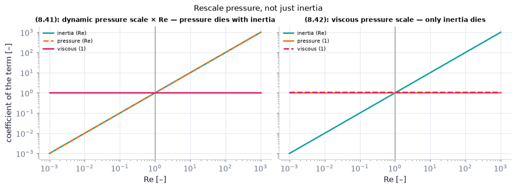

```python
Re = np.geomspace(1e-3, 1e3, 100)                          # Reynolds numbers
fig, (a1, a2) = plt.subplots(1, 2, figsize=(10, 3.6), sharey=True)   # the figure and its panels
a1.loglog(Re, Re, color=COLORS["teal"], lw=2, label="inertia (Re)")   # a curve (its label says which)
a1.loglog(Re, Re, color=COLORS["orange"], lw=2, ls="--", label="pressure (Re)")   # a curve (its label says which)
a1.loglog(Re, 1 + 0*Re, color=COLORS["rose"], lw=2, label="viscous (1)")   # a curve (its label says which)
a1.set_title("(8.41): dynamic pressure scale × Re — pressure dies with inertia", fontsize=9)   # each panel says its message
a2.loglog(Re, Re, color=COLORS["teal"], lw=2, label="inertia (Re)")   # a curve (its label says which)
a2.loglog(Re, 1 + 0*Re, color=COLORS["orange"], lw=2, label="pressure (1)")   # a curve (its label says which)
a2.loglog(Re, 1.05 + 0*Re, color=COLORS["rose"], lw=2, ls="--", label="viscous (1)")   # a curve (its label says which)
a2.set_title("(8.42): viscous pressure scale — only inertia dies", fontsize=9)   # each panel says its message
for ax in (a1, a2):                                      # both panels
    ax.axvline(1, color=COLORS["muted"], lw=0.8); ax.set_xlabel("Re [–]"); ax.legend(fontsize=7)   # labels with units
a1.set_ylabel("coefficient of the term [–]")             # labels with units
fig.suptitle("Rescale pressure, not just inertia", fontsize=11)   # the figure's message
savefig(fig, "ch08", "c12_low_re_scaling"); plt.show()   # save the PNG to outputs/ch08, then draw
```

**What you see.** Left: with the pressure scaled by ρU² and the equation multiplied by Re, the pressure coefficient falls together with inertia; right: with the pressure scaled by μU/L, pressure and viscous terms stay at 1 and only inertia falls.

**How to read it.** Read off which terms survive as Re → 0 (the left end): on the right, pressure and friction balance — the Stokes equations $\nabla p=\mu\nabla^2\mathbf u$ *(8.43)*.

**What would change if…** …Re = 1: the two scalings coincide — neither term is negligible and the full equation is needed.

```python
def frame(lr10):                                          # coefficients at Re = 10^lr10
    R_ = 10**lr10                                        # Re itself
    return {"dynamic scale × Re: inertia, pressure, viscous": ([1, 2, 3], np.log10([R_, R_, 1.0])),   # the curves of this position
            "viscous scale × Re: inertia, pressure, viscous": ([1, 2, 3], np.log10([R_, 1.0, 1.0]))}   # (continued)


fig = slider_figure(frame, "log10 Re", np.linspace(-3, 3, 25 if not FAST else 13), unit="",   # precompute every slider/time position
                    xlabel="term: 1 = inertia, 2 = pressure, 3 = viscous", ylabel="log10(coefficient)",   # (continued)
                    title="Which terms survive as Re → 0?", modes={"dynamic scale × Re: inertia, pressure, viscous": "lines+markers",   # (continued)
                                                                  "viscous scale × Re: inertia, pressure, viscous": "lines+markers"})   # (continued)
recolor(fig, {"dynamic scale × Re: inertia, pressure, viscous": COLORS["muted"], "viscous scale × Re: inertia, pressure, viscous": COLORS["orange"]})   # colours by meaning (as in the static figures)
fig.show()                                               # draw the interactive figure
```

[interactive chart not shown]

**What does the code above do?**

Slide log₁₀ Re down to −3: with the dynamic scale (grey) both inertia and pressure drop below the viscous term; with the viscous scale (orange) the pressure stays level with the viscous term.

📝 **Note.** **N80 [C] · The italic rule.** The right length and time scales depend on the region of the flow and are found by balancing the terms that matter there. Ch. 9 (boundary layers) and Ch. 13 (rotating, stratified scales) live by it.

**What would change if…** …we solve (8.43), $\nabla p=\mu\nabla^2\mathbf u$ round a sphere? The equation is linear, so reversing the stream reverses the whole flow: no wake (C13).

> 🔁 **Recap — Vorticity in spherical coordinates** (Ch. 3 §3.4). For an axisymmetric flow without swirl only the azimuthal vorticity survives, $\omega_\varphi=\frac1r\big[\frac{\partial(ru_\theta)}{\partial r}-\frac{\partial u_r}{\partial\theta}\big]$ (the spherical curl of `core.curvilinear`).

> 🔁 **Recap — Stokes' stream function** (Ch. 6 §6.8). Axisymmetric velocities come from one function: $u_r=\frac1{r^2\sin\theta}\frac{\partial\psi}{\partial\theta},\ u_\theta=-\frac1{r\sin\theta}\frac{\partial\psi}{\partial r}$ *(6.83)*.

> 🔁 **Recap — The uniform stream far away** (Ch. 6 §6.8). A uniform stream U along the axis has $\psi=\tfrac12Ur^2\sin^2\theta$ *(6.86)*; the far-field condition is $\psi(r\to\infty,\theta)=\tfrac12Ur^2\sin^2\theta$ *(8.47)*.

### 🧩 Stokes' solution for the sphere `C13`

*The question:* What is the flow round a sphere when viscosity dominates everywhere?

*In one line:* $\psi=Ur^2\sin^2\theta\Big(\frac12-\frac{3a}{4r}+\frac{a^3}{4r^3}\Big)$ *(8.48)*

#### The problem in plain words

A tiny bead sinks through syrup. Drawn in the bead's frame, the fluid streams past it; drawn in the syrup's frame, the fluid is pushed aside in front and closes in behind. We want the whole velocity field — it gives the pressure, the stresses and the drag (C14), and it is the reference for every settling particle and swimming micro-organism.

#### The idea

```
─────────►        ψ = ½Ur² sin²θ  −  (3a/4)Ur sin²θ  +  (a³/4)(U/r) sin²θ
────╮ ● ╭─►          stream          'Stokeslet' ~ a/r      'doublet' ~ a³/r³
─────────►        the a/r part decays so slowly that the sphere is felt tens of radii away
```

A uniform stream minus a slowly decaying disturbance, fore–aft symmetric.

> 🔁 **Tools from earlier chapters used here** (see `knowledge/primers.md`)
- **spherical coordinates with θ from the downstream axis** — r from the centre, θ the angle from the +x axis — here the **downstream** direction, so the rear stagnation point is θ = 0 and the front θ = π — and φ round the axis (Ch. 3 P88).
- **curl of a gradient is zero, curl commutes with the Cartesian Laplacian** — ∇ × ∇p = 0 because mixed partial derivatives are equal (Schwarz, Ch. 4 P121); in Cartesian components curl and ∇² are both built from constant-coefficient derivatives, so their order can be swapped.
- **index notation ε_ijk** — $(\nabla\times\mathbf A)_k=\varepsilon_{kli}\partial_lA_i$ with the permutation symbol $\varepsilon_{kli}$ = +1 for cyclic, −1 for anticyclic orders, 0 otherwise (Ch. 2 §2.7, P72).

📝 **Note.** **N81 [B] · Take the curl.** The curl of (8.43), $\nabla p=\mu\nabla^2\mathbf u$ kills the pressure (curl of a gradient) and leaves ∇²ω = 0 — in Cartesian components; in spherical coordinates the operator means −∇×∇×ω (the book's footnote).

#### 🧮 Derivation — Curl of the Stokes equations: ∇²ω = 0 `D27`

**What we want to show.** Remove the pressure from (8.43), $\nabla p=\mu\nabla^2\mathbf u$ and get an equation for the vorticity alone.

**Assumptions.** Constant μ; Cartesian components for steps 1–5.

**The plan.**

1. Take the curl.
2. The pressure drops out.
3. Swap the curl and the Laplacian.
4. Interpret in spherical coordinates.

**Tools we use** (each explained before this point): index notation ε_ijk (Ch. 2 §2.7) · Schwarz's theorem (P121) · curl of a curl (P122).

**We start from**

$$ \nabla p=\mu\nabla^2\mathbf u\ \text{(8.43)},\qquad \partial_ip=\mu\,\partial_j\partial_ju_i\ \text{(Cartesian components)} $$

*In words:* the Stokes equations, written component by component

**Step 1 of 6 — Apply the curl.**

$$ \varepsilon_{kli}\partial_l\partial_ip=\mu\,\varepsilon_{kli}\partial_l\partial_j\partial_ju_i $$

- *Why we can do this:* Multiply both sides by ε_kli∂_l and sum; this is the curl in index notation. We do it to eliminate p.
- *In words:* take the curl of both sides.

**Step 2 of 6 — Drop the pressure.**

$$ \varepsilon_{kli}\partial_l\partial_ip=0 $$

- *Why we can do this:* ∂_l∂_i is symmetric in l, i (Schwarz, P121) while ε_kli is antisymmetric: the sum vanishes — the curl of a gradient is zero.
- *In words:* pressure has no curl.

**Step 3 of 6 — Move the Laplacian outside.**

$$ 0=\mu\,\partial_j\partial_j(\varepsilon_{kli}\partial_lu_i) $$

- *Why we can do this:* In Cartesian components ε is constant and partial derivatives commute.
- *In words:* curl and Laplacian can swap order.

**Step 4 of 6 — Recognise the vorticity.**

$$ \omega_k=\varepsilon_{kli}\partial_lu_i\ \Rightarrow\ 0=\mu\nabla^2\omega_k $$

- *Why we can do this:* ω = ∇ × u in index form.
- *In words:* each Cartesian component of ω is harmonic.

**Step 5 of 6 — Write it as a vector statement.**

$$ \nabla^2\boldsymbol\omega=0 $$

- *Why we can do this:* Divide by the constant viscosity μ, which is not zero.
- *In words:* no advection and no change in time: the diffusion of ω balances itself, so each Cartesian component is harmonic.

**Step 6 of 6 — Say what it means in spherical form.**

$$ \nabla^2\boldsymbol\omega=\nabla(\nabla\cdot\boldsymbol\omega)-\nabla\times\nabla\times \boldsymbol\omega=-\nabla\times\nabla\times\boldsymbol\omega=0 $$

- *Why we can do this:* The curl-of-curl identity (P122) with ∇·ω = 0; in spherical components this, not the scalar Laplacian of each component, is meant (the book's footnote).
- *In words:* the form used in D28.

**Result**

$$ -\nabla\times\nabla\times\boldsymbol\omega=0\ \text{(∇²ω = 0 in Cartesian components)} $$

*In words:* in creeping flow the vorticity satisfies a pressure-free equation.

**What it means.** The pressure is recovered afterwards from ∇p = −μ∇×ω (D30).

**Check it.** For Stokes' solution ω_φ = −(3Ua/2r²) sin θ (D30 step 3), the check cell below applies the spherical curl of `core.curvilinear` twice and gets 0 in every component.

```python
S = ch08.stokes_sphere_sympy()                           # the Stokes-sphere results in sympy (cached; shared by D28–D31)
r, th, a, U, mu = S["symbols"]                           # its symbols: r, θ, a, U, μ
XS = (r, th, sp.Symbol("phi", real=True))                 # spherical coordinates for core.curvilinear
w = [0, 0, S["omega_phi"]]                               # Stokes' vorticity ω = ω_φ e_φ, ω_φ = −(3Ua/2r²) sin θ
cc = CL.curl(CL.curl(w, "spherical", XS), "spherical", XS) # ∇ × (∇ × ω), component by component
print("ω_φ =", S["omega_phi"])
print("∇×∇×ω =", [sp.simplify(c) for c in cc])          # [0, 0, 0]: −∇×∇×ω = 0 holds for Stokes' solution
assert all(sp.simplify(c) == 0 for c in cc)
```

```
ω_φ = -3*U*a*sin(theta)/(2*r**2)
∇×∇×ω = [0, 0, 0]
```

> ⚠️ **Common confusion (traps in `D27`):** Curl and Laplacian commute only in Cartesian components; applying the scalar Laplacian to ω_φ alone is wrong.

> 📎 **Primer — the Stokes operator E² applied twice.** `P199` · For axisymmetric flow the operator $E^2=\frac{\partial^2}{\partial r^2}+\frac{\sin\theta}{r^2}\frac{\partial}{\partial\theta}\big( \frac1{\sin\theta}\frac{\partial}{\partial\theta}\big)$ (Ch. 6 used it once, (6.77), $E^2\psi=\frac{\partial^2\psi}{\partial r^2}+\frac{\sin\theta}{r^2}\frac{\partial}{\partial\theta}\Big(\frac1{\sin\theta}\frac{\partial\psi}{\partial\theta}\Big)$) turns ψ into the vorticity: $\omega_\varphi=-E^2\psi/(r\sin\theta)$. Applying it twice, $E^2(E^2\psi)$, is **not** the biharmonic ∇⁴ψ — a sympy test in D28 shows the difference.

```python
import sympy as sp                                       # symbolic maths
r, th = sp.symbols('r theta', positive=True)             # spherical r and θ as symbols
E2 = lambda f: sp.diff(f, r, 2) + sp.sin(th)/r**2*sp.diff(sp.diff(f, th)/sp.sin(th), th)   # the Stokes operator
print(sp.simplify(E2(r**2*sp.sin(th)**2)))               # 0: the uniform stream has no vorticity
```

```
0
```

📝 **Note.** **N82 [B], N83 [B] · Vorticity from ψ, and the ψ-equation.** **N82** $\omega_\varphi=-\frac1r\big[\frac{1}{\sin\theta}\frac{\partial^2\psi}{\partial r^2}+\frac1{r^2}\frac{\partial}{\partial\theta} \big(\frac1{\sin\theta}\frac{\partial\psi}{\partial\theta}\big)\big]=-\frac{E^2\psi}{r\sin\theta}$. **N83** Combining with ∇²ω_φ = 0 in the footnote's sense gives (8.44). ⚠️ It is the square of E², not the biharmonic (footnote 2).

$$ \Big[\frac{\partial^2}{\partial r^2}+\frac{\sin\theta}{r^2}\frac{\partial}{\partial\theta}\Big(\frac1{\sin\theta}\frac{\partial}{\partial\theta}\Big)\Big]^2\psi=0 \qquad \text{(8.44)} $$

#### 🧮 Derivation — The stream-function equation $\big[\frac{\partial^2}{\partial r^2}+\frac{\sin\theta}{r^2}\frac{\partial}{\partial\theta}\big(\frac{1}{\sin\theta}\frac{\partial}{\partial\theta}\big)\big]^2\psi=0$ `D28` (Eq. 8.44: $\Big[\frac{\partial^2}{\partial r^2}+\frac{\sin\theta}{r^2}\frac{\partial}{\partial\theta}\Big(\frac1{\sin\theta}\frac{\partial}{\partial\theta}\Big)\Big]^2\psi=0$)

**What we want to show.** Write the vorticity equation of D27 as one scalar equation for Stokes' stream function ψ.

**Assumptions.** Axisymmetric (∂/∂φ = 0), no swirl (u_φ = 0); θ from the downstream axis.

**The plan.**

1. Express ω_φ through ψ with the operator E².
2. Show the curl–curl of any azimuthal field is an E² operation.
3. Combine.

**Tools we use** (each explained before this point): Stokes stream function (R18) · spherical vorticity (R17) · the Stokes operator E² (primer P199) · sympy.

**We start from**

$$ u_r=\frac1{r^2\sin\theta}\frac{\partial\psi}{\partial\theta},\ u_\theta=-\frac1{r\sin\theta}\frac{\partial\psi}{\partial r}\ \text{(6.83)},\qquad \boldsymbol\omega=\omega_\varphi\mathbf e_\varphi,\qquad -\nabla\times\nabla\times\boldsymbol\omega=0\ \text{(D27)} $$

*In words:* Stokes' stream function, the azimuthal vorticity, and the vorticity equation of D27

**Step 1 of 12 — Keep only the azimuthal vorticity.**

$$ \boldsymbol\omega=\omega_\varphi(r,\theta)\,\mathbf e_\varphi $$

- *Why we can do this:* With u_φ = 0 and ∂/∂φ = 0 the r- and θ-components of the spherical curl vanish.
- *In words:* vorticity circles the axis.

**Step 2 of 12 — Write ω_φ from the velocity.**

$$ \omega_\varphi=\frac1r\Big[\frac{\partial(ru_\theta)}{\partial r}-\frac{\partial u_r}{\partial \theta}\Big] $$

- *Why we can do this:* The φ-component of the spherical curl (R17).
- *In words:* a rotation rate in the meridian plane.

**Step 3 of 12 — Insert u_θ from (6.83).**

$$ \frac{\partial(ru_\theta)}{\partial r}=-\frac{1}{\sin\theta}\frac{\partial^2\psi}{\partial r^2} $$

- *Why we can do this:* ru_θ = −(1/sin θ)∂ψ/∂r, and sin θ does not depend on r.
- *In words:* first half.

**Step 4 of 12 — Insert u_r from (6.83).**

$$ \frac{\partial u_r}{\partial\theta}=\frac{1}{r^2}\frac{\partial}{\partial\theta}\Big(\frac{1}{\sin\theta} \frac{\partial\psi}{\partial\theta}\Big) $$

- *Why we can do this:* u_r = (1/r²)(1/sin θ)∂ψ/∂θ; differentiate in θ at fixed r.
- *In words:* second half.

**Step 5 of 12 — Combine.**

$$ \omega_\varphi=-\frac1r\Big[\frac{1}{\sin\theta}\frac{\partial^2\psi}{\partial r^2}+\frac1{r^2}\frac{\partial} {\partial\theta}\Big(\frac1{\sin\theta}\frac{\partial\psi}{\partial\theta}\Big)\Big] $$

- *Why we can do this:* Insert steps 3 and 4 into the curl formula of step 2 and collect the bracket.
- *In words:* the book's line.

**Step 6 of 12 — Factor out 1/sin θ.**

$$ \omega_\varphi=-\frac{E^2\psi}{r\sin\theta},\ \ E^2=\frac{\partial^2}{\partial r^2}+\frac{\sin\theta}{r^2} \frac{\partial}{\partial\theta}\Big(\frac{1}{\sin\theta}\frac{\partial}{\partial\theta}\Big) $$

- *Why we can do this:* Multiply and divide the bracket by sin θ; the operator is Ch. 6's E² (P199).
- *In words:* vorticity = −E²ψ/(r sin θ).

**Step 7 of 12 — Curl an azimuthal field.**

$$ \nabla\times(A\,\mathbf e_\varphi)=\frac{\partial_\theta(\sin\theta A)}{r\sin\theta}\mathbf e_r-\frac {\partial_r(rA)}{r}\mathbf e_\theta $$

- *Why we can do this:* Spherical curl of A = A(r, θ)e_φ (`core.curvilinear`). We need the curl twice.
- *In words:* an azimuthal field curls into a meridional one.

**Step 8 of 12 — Introduce Ψ = r sin θ A.**

$$ \nabla\times(A\,\mathbf e_\varphi)=\frac{1}{r^2\sin\theta}\frac{\partial\Psi}{\partial\theta} \mathbf e_r-\frac{1}{r\sin\theta}\frac{\partial\Psi}{\partial r}\mathbf e_\theta $$

- *Why we can do this:* sin θ A = Ψ/r and rA = Ψ/sin θ turn step 7 into exactly the (6.83), $u_r=\frac1{r^2\sin\theta}\frac{\partial\psi}{\partial\theta},\ u_\theta=-\frac1{r\sin\theta}\frac{\partial\psi}{\partial r}$ pattern with Ψ in place of ψ.
- *In words:* the curl looks like a velocity from a stream function Ψ.

**Step 9 of 12 — Curl again using step 6.**

$$ \nabla\times\nabla\times(A\,\mathbf e_\varphi)=-\frac{E^2\Psi}{r\sin\theta}\mathbf e_\varphi $$

- *Why we can do this:* Steps 2–6 showed: the curl of a (6.83), $u_r=\frac1{r^2\sin\theta}\frac{\partial\psi}{\partial\theta},\ u_\theta=-\frac1{r\sin\theta}\frac{\partial\psi}{\partial r}$-type field from Ψ is −E²Ψ/(r sin θ) e_φ.
- *In words:* curl–curl is an E² operation.

**Step 10 of 12 — Apply to the vorticity.**

$$ \Psi=r\sin\theta\,\omega_\varphi=-E^2\psi $$

- *Why we can do this:* A = ω_φ, and step 6.
- *In words:* the 'stream function' of the vorticity is −E²ψ.

**Step 11 of 12 — Insert into D27's equation.**

$$ -\nabla\times\nabla\times\boldsymbol\omega=\frac{E^2\Psi}{r\sin\theta}\mathbf e_\varphi=-\frac {E^2(E^2\psi)}{r\sin\theta}\mathbf e_\varphi=0 $$

- *Why we can do this:* Insert step 10 into step 9, with A = ω_φ, into D27's equation.
- *In words:* one scalar equation left.

**Step 12 of 12 — Divide by r sin θ.**

$$ E^2(E^2\psi)=0\ \text{(8.44)} $$

- *Why we can do this:* r sin θ ≠ 0 off the axis. It is the square of E², not the biharmonic ∇⁴ (the book's footnote).
- *In words:* (8.44), $\Big[\frac{\partial^2}{\partial r^2}+\frac{\sin\theta}{r^2}\frac{\partial}{\partial\theta}\Big(\frac1{\sin\theta}\frac{\partial}{\partial\theta}\Big)\Big]^2\psi=0$.

**Result**

$$ (E^2)^2\psi=0 $$

*In words:* creeping axisymmetric flow obeys the squared Stokes operator.

**What it means.** A fourth-order equation needs four conditions: two on the sphere, the stream far away (and regularity) — D29 uses them.

**Check it.** Units: E² is 1/m², so E⁴ψ ~ ψ/m⁴ ✓; sympy: E⁴ψ = 0 for (8.48), $\psi=Ur^2\sin^2\theta\Big(\frac12-\frac{3a}{4r}+\frac{a^3}{4r^3}\Big)$, ∇⁴ψ ≠ 0 for (8.48), and the identity of step 9 holds for a generic A(r, θ) (the check cell below).

```python
A_ = sp.Function("A")(r, th)                             # a generic azimuthal field A(r, θ) e_φ
cc = CL.curl(CL.curl([0, 0, A_], "spherical", XS, False), "spherical", XS, False)   # ∇×∇×(A e_φ), not simplified yet
E2 = lambda f: sp.diff(f, r, 2) + sp.sin(th)/r**2*sp.diff(sp.diff(f, th)/sp.sin(th), th)   # the Stokes operator E²
assert sp.simplify(cc[0]) == 0 and sp.simplify(cc[1]) == 0   # steps 7–9: the curl–curl of an azimuthal field is azimuthal …
assert sp.simplify(cc[2] + E2(r*sp.sin(th)*A_)/(r*sp.sin(th))) == 0   # … and equals −E²(r sinθ A)/(r sinθ) e_φ
print("E²(E²ψ) for (8.48):", sp.simplify(E2(E2(S["psi"]))))   # 0: Stokes' ψ satisfies (8.44)
print("∇⁴ψ for (8.48):   ", S["biharmonic_psi"])          # not 0: the scalar biharmonic is a different operator
assert sp.simplify(S["E4psi"]) == 0 and sp.simplify(S["biharmonic_psi"]) != 0
```

```
E²(E²ψ) for (8.48): 0
∇⁴ψ for (8.48):    6*U*a*(2 - 3*sin(theta)**2)/r**3
```

> ⚠️ **Common confusion (traps in `D28`):** (E²)² is not ∇⁴; θ from the downstream axis; the identity of steps 7–9 must be checked, not assumed.

📝 **Note.** **N84 [B], N85 [B], N86 [B] · Conditions and the separated ODE.** **N84, N85** On the sphere: $\psi(r=a,\theta)=0$ *(8.45)* (no flow through it) and $\partial\psi(r=a,\theta)/\partial r=0$ *(8.46)* (no slip); far away (8.47), $\psi(r\to\infty,\theta)=\tfrac12Ur^2\sin^2\theta$. **N86** (8.47) suggests ψ = f(r) sin²θ; (8.44), $\Big[\frac{\partial^2}{\partial r^2}+\frac{\sin\theta}{r^2}\frac{\partial}{\partial\theta}\Big(\frac1{\sin\theta}\frac{\partial}{\partial\theta}\Big)\Big]^2\psi=0$ becomes the ODE below, solved by $f=Ar^4+Br^2+Cr+D/r$ with A = 0, B = U/2, C = −3Ua/4, D = Ua³/4.

$$ f^{iv}-\frac{4f''}{r^2}+\frac{8f'}{r^3}-\frac{8f}{r^4}=0 $$

#### 🧮 Derivation — Separable solution, f = Ar⁴ + Br² + Cr + D/r and Stokes' ψ `D29` (Eq. 8.48: $\psi=Ur^2\sin^2\theta\Big(\frac12-\frac{3a}{4r}+\frac{a^3}{4r^3}\Big)$)

**What we want to show.** Solve (8.44), $\Big[\frac{\partial^2}{\partial r^2}+\frac{\sin\theta}{r^2}\frac{\partial}{\partial\theta}\Big(\frac1{\sin\theta}\frac{\partial}{\partial\theta}\Big)\Big]^2\psi=0$ with the sphere's conditions.

**Assumptions.** The angular dependence of (8.47), $\psi(r\to\infty,\theta)=\tfrac12Ur^2\sin^2\theta$ persists everywhere (step 1).

**The plan.**

1. Separate ψ = f(r) sin²θ.
2. Get the ODE for f.
3. Euler–Cauchy roots.
4. Four constants from the conditions.

**Tools we use** (each explained before this point): E² (primer P199) · Euler–Cauchy ODE (primer P187) · 2 × 2 system (P57).

**We start from**

$$ (E^2)^2\psi=0\ \text{(8.44),}\ \psi(a,\theta)=0\ \text{(8.45),}\ \partial\psi(a,\theta)/\partial r=0\ \text{(8.46),}\ \psi\to\frac12Ur^2\sin^2\theta\ \text{(8.47).} $$

**Step 1 of 11 — Try a separable form.**

$$ \psi=f(r)\sin^2\theta $$

- *Why we can do this:* The far field (8.47), $\psi(r\to\infty,\theta)=\tfrac12Ur^2\sin^2\theta$ has sin²θ; if E² keeps sin²θ, the whole problem reduces to r.
- *In words:* guess the angular shape from infinity.

**Step 2 of 11 — Apply the angular part.**

$$ \sin\theta\frac{\partial}{\partial\theta}\Big(\frac{1}{\sin\theta}\frac{\partial\sin^2\theta}{\partial\theta} \Big)=\sin\theta\frac{\partial}{\partial\theta}(2\cos\theta)=-2\sin^2\theta $$

- *Why we can do this:* ∂_θ sin²θ = 2 sin θ cos θ; divided by sin θ it is 2 cos θ.
- *In words:* sin²θ is reproduced.

**Step 3 of 11 — E² of the trial.**

$$ E^2(f\sin^2\theta)=\Big(f''-\frac{2f}{r^2}\Big)\sin^2\theta $$

- *Why we can do this:* The radial part gives f″ sin²θ; the angular part gives (1/r²)(−2 sin²θ) f.
- *In words:* E² acts on f alone.

**Step 4 of 11 — Apply E² again, to g.**

$$ E^2(g\sin^2\theta)=\Big(g''-\frac{2g}{r^2}\Big)\sin^2\theta=0,\qquad g=f''-\frac{2f}{r^2} $$

- *Why we can do this:* Step 3 showed E²(f sin²θ) = g sin²θ; the same rule applied to g sin²θ gives (8.44), $\Big[\frac{\partial^2}{\partial r^2}+\frac{\sin\theta}{r^2}\frac{\partial}{\partial\theta}\Big(\frac1{\sin\theta}\frac{\partial}{\partial\theta}\Big)\Big]^2\psi=0$ as an ODE for g.
- *In words:* (8.44), $\Big[\frac{\partial^2}{\partial r^2}+\frac{\sin\theta}{r^2}\frac{\partial}{\partial\theta}\Big(\frac1{\sin\theta}\frac{\partial}{\partial\theta}\Big)\Big]^2\psi=0$ becomes g″ − 2g/r² = 0.

**Step 5 of 11 — Expand the ODE in f.**

$$ f^{iv}-\frac{4f''}{r^2}+\frac{8f'}{r^3}-\frac{8f}{r^4}=0 $$

- *Why we can do this:* Insert g = f″ − 2f/r² and use (f/r²)″ = f″/r² − 4f′/r³ + 6f/r⁴: g″ − 2g/r² = f⁗ − 2f″/r² + 8f′/r³ − 12f/r⁴ − 2f″/r² + 4f/r⁴.
- *In words:* the book's fourth-order Euler–Cauchy ODE.

**Step 6 of 11 — Try f = r^λ.**

$$ \lambda(\lambda-1)(\lambda-2)(\lambda-3)-4\lambda(\lambda-1)+8\lambda-8=0 $$

- *Why we can do this:* Every term is r^(λ−4) times a polynomial in λ (P187).
- *In words:* an algebraic equation.

**Step 7 of 11 — Factor the polynomial.**

$$ (\lambda-4)(\lambda-2)(\lambda-1)(\lambda+1)=0 $$

- *Why we can do this:* 8λ − 8 = 8(λ − 1) and the rest also carries (λ − 1); the cubic λ³ − 5λ² + 2λ + 8 has the roots 4, 2, −1.
- *In words:* four powers.

**Step 8 of 11 — Write the general solution.**

$$ f=Ar^4+Br^2+Cr+\frac Dr $$

- *Why we can do this:* The ODE is linear, so any combination of the four power solutions solves it.
- *In words:* four constants.

**Step 9 of 11 — Apply the far field (8.47).**

$$ A=0,\ \ B=\frac U2 $$

- *Why we can do this:* f must tend to ½Ur²; an r⁴ term would outgrow the stream, and the r and 1/r terms are negligible far away.
- *In words:* the uniform stream survives.

**Step 10 of 11 — Apply (8.45) and (8.46).**

$$ \frac{Ua^2}{2}+Ca+\frac Da=0,\ \ Ua+C-\frac{D}{a^2}=0 $$

- *Why we can do this:* ψ = 0 and ∂ψ/∂r = 0 at r = a mean f(a) = f′(a) = 0.
- *In words:* no flow through, no slip.

**Step 11 of 11 — Solve and assemble.**

$$ C=-\frac{3Ua}{4},\ D=\frac{Ua^3}{4}:\ \ \psi=Ur^2\sin^2\theta\Big(\frac12-\frac{3a}{4r}+\frac{a^3}{4r^3} \Big)\ \text{(8.48)} $$

- *Why we can do this:* Divide the first by a and add the second: 3Ua/2 + 2C = 0; then D = a²(Ua + C).
- *In words:* (8.48), $\psi=Ur^2\sin^2\theta\Big(\frac12-\frac{3a}{4r}+\frac{a^3}{4r^3}\Big)$.

**Result**

$$ \psi=Ur^2\sin^2\theta\Big(\frac12-\frac{3a}{4r}+\frac{a^3}{4r^3}\Big)\ \text{(8.48)} $$

*In words:* stream, minus a 1/r 'Stokeslet', plus a 1/r³ doublet.

**What it means.** The −3a/4r term decays slowly: the sphere is felt tens of radii away, which is exactly why inertia returns far away (D32).

**Check it.** ψ(a) = Ua²(½ − ¾ + ¼) = 0 ✓; ∂ψ/∂r at a: Ua sin²θ(1 − ¾ − ¼) = 0 ✓; E⁴ψ = 0 (sympy).

> ⚠️ **Common confusion (traps in `D29`):** E²(f sin²θ) = (f″ − 2f/r²) sin²θ; the roots are {4, 2, 1, −1}; A = 0 from the far field, not from the surface.

📝 **Note.** **N87 [B] · Velocities** (one derivative each through (6.83), $u_r=\frac1{r^2\sin\theta}\frac{\partial\psi}{\partial\theta},\ u_\theta=-\frac1{r\sin\theta}\frac{\partial\psi}{\partial r}$):

$$ u_r=U\cos\theta\Big(1-\frac{3a}{2r}+\frac{a^3}{2r^3}\Big),\ u_\theta=-U\sin\theta\Big(1-\frac{3a}{4r}-\frac{a^3}{4r^3}\Big) \qquad \text{(8.49)} $$

```python
print("u_r =", sp.factor(S["u_r"]))                      # (8.49), factored: vanishes at r = a
print("u_θ =", sp.factor(S["u_theta"]))
print("on r = a:", S["u_r"].subs(r, a), S["u_theta"].subs(r, a))   # 0 0: no slip
print("f-roots:", S["roots"], " constants:", S["constants"])        # D29 steps 7 and 9–11
```

```
u_r = U*(-a + r)**2*(a + 2*r)*cos(theta)/(2*r**3)
```

```
u_θ = -U*(-a + r)*(a**2 + a*r + 4*r**2)*sin(theta)/(4*r**3)
on r = a: 0 0
f-roots: [-1, 1, 2, 4]  constants: {A: 0, B: U/2, C: -3*U*a/4, D: U*a**3/4}
```

#### ✏️ Tiny example: a bead in syrup, two radii out on the side

a = 1 mm, U = 1 mm/s, ν = 10⁻³ m²/s (syrup: Re = 2aU/ν = 0.002). At r = 2a, θ = π/2: u_r = 0, $u_\theta=-U\big(1-\frac38-\frac1{32}\big)=-0.594U$. Ideal flow (Ch. 6) would give $-U\big(1+\frac1{16}\big)=-1.063U$: the viscous fluid is *slowed* beside the sphere instead of sped up. At r = 10a the Stokes speed is 0.925U — still a 7.5 % deficit; the ideal-flow disturbance is already 0.05 %.

```python
for rr_ in (2.0, 10.0):                                  # two distances on the side line, in radii
    print(f"r = {rr_:g}a: Stokes |u| = {ch08.side_line_speed(rr_*1e-3, U=1e-3, a=1e-3, model='stokes')/1e-3:.4f} U, "   # show the numbers
          f"ideal |u| = {ch08.side_line_speed(rr_*1e-3, U=1e-3, a=1e-3, model='ideal')/1e-3:.4f} U")   # (continued)
print("(u_r, u_θ) at r = 2a, θ = π/2:", ch08.stokes_sphere_velocity(2e-3, np.pi/2, U=1e-3, a=1e-3), "m/s")   # show the numbers
print("fluid-frame ψ at r = 2a, θ = π/4:", ch08.stokes_sphere_streamfunction(2e-3, np.pi/4, U=1e-3, a=1e-3, frame="fluid"), "m³/s")   # show the numbers
```

```
r = 2a: Stokes |u| = 0.5938 U, ideal |u| = 1.0625 U
r = 10a: Stokes |u| = 0.9248 U, ideal |u| = 1.0005 U
(u_r, u_θ) at r = 2a, θ = π/2: (1.9135106236677394e-20, -0.00059375) m/s
fluid-frame ψ at r = 2a, θ = π/4: -6.875000000000002e-10 m³/s
```

**What does the code above do?**

1. `side_line_speed` evaluates the speed at θ = π/2 for Stokes' (8.49), $u_r=U\cos\theta\Big(1-\frac{3a}{2r}+\frac{a^3}{2r^3}\Big),\ u_\theta=-U\sin\theta\Big(1-\frac{3a}{4r}-\frac{a^3}{4r^3}\Big)$ and for Ch. 6's ideal sphere: 0.594U against 1.0625U at 2a, 0.925U against 1.0005U at 10a — the tiny example.
2. `stokes_sphere_velocity` gives the two components; `stokes_sphere_streamfunction(..., frame="fluid")` subtracts the stream (N93 below).

```python
rng = np.random.default_rng(3)                           # reproducible random points
rr = 1e-3*(1.2 + 8*rng.random(20)); tt = 0.1 + 2.9*rng.random(20)   # 20 points outside the sphere: r in (1.2a, 9.2a), θ in (0.1, 3.0)
hh = 1e-7                                                # finite-difference step [m or rad]
psi = lambda R_, T_: ch08.stokes_sphere_streamfunction(R_, T_, U=1e-3, a=1e-3)   # (8.48)
ur_fd = (psi(rr, tt + hh) - psi(rr, tt - hh))/(2*hh)/(rr**2*np.sin(tt))     # u_r = (1/r² sinθ) ∂ψ/∂θ (6.83)
ut_fd = -(psi(rr + hh, tt) - psi(rr - hh, tt))/(2*hh)/(rr*np.sin(tt))       # u_θ = −(1/r sinθ) ∂ψ/∂r
assert np.allclose((ur_fd, ut_fd), ch08.stokes_sphere_velocity(rr, tt, U=1e-3, a=1e-3), rtol=1e-6, atol=1e-12)
print("central differences of ψ through (6.83) reproduce (8.49) at 20 random points")
```

```
central differences of ψ through (6.83) reproduce (8.49) at 20 random points
```

📝 **Note.** **N93 [B] · The sphere moving through still fluid (fluid frame).** Subtract the stream: ψ below (Fig. 8.19). The pattern is fore–aft symmetric — no wake — because (8.43), $\nabla p=\mu\nabla^2\mathbf u$ is linear: reversing U maps u → −u and p − p∞ → −(p − p∞). ⚠️ The text calls the equation "(9.63)"; it means (8.43). Ch. 16 returns to this reversibility (why a swimming bacterium cannot use a reciprocal stroke).

$$ \psi=Ur^2\sin^2\theta\Big(-\frac{3a}{4r}+\frac{a^3}{4r^3}\Big) $$

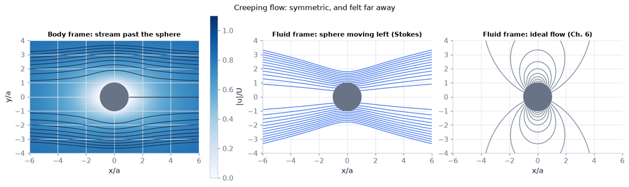

```python
n_ = 301 if not FAST else 151                              # grid points per side
xg = np.linspace(-6, 6, n_); yg = np.linspace(-4, 4, n_)   # in sphere radii (a = 1)
X, Y = np.meshgrid(xg, yg)                               # every point of the window
Rr = np.hypot(X, Y); Th = np.arccos(np.clip(X/np.maximum(Rr, 1e-12), -1, 1))   # spherical r and θ from +x
out = Rr > 1                                              # outside the sphere
psi_b = np.where(out, ch08.stokes_sphere_streamfunction(Rr, Th, 1.0, 1.0, frame="body"), np.nan)   # (8.48)
psi_f = np.where(out, ch08.stokes_sphere_streamfunction(Rr, Th, 1.0, 1.0, frame="fluid"), np.nan)  # N93
ur, ut = ch08.stokes_sphere_velocity(Rr, Th, 1.0, 1.0)    # (8.49) body frame
speed = np.where(out, np.hypot(ur, ut), np.nan)           # |u|/U
psi_i = np.where(out, PF.sphere(1.0, 1.0).psi(np.abs(Y), X) - 0.5*Y**2, np.nan)   # Ch. 6 ideal sphere, fluid frame
fig, axs = plt.subplots(1, 3, figsize=(13, 3.8))         # the figure and its panels
im = axs[0].pcolormesh(X, Y, speed, cmap="Blues", vmin=0, vmax=1.1, shading="auto")   # speed as a colour map
axs[0].contour(X, Y, psi_b, np.linspace(-4, 4, 17), colors=COLORS["ink"], linewidths=0.8)   # streamlines = lines of constant ψ
fig.colorbar(im, ax=axs[0], label="|u|/U")               # the colour scale
axs[1].contour(X, Y, psi_f, np.linspace(-1.2, 1.2, 25), colors=COLORS["blue"], linewidths=0.9)   # streamlines = lines of constant ψ
axs[2].contour(X, Y, psi_i, np.linspace(-0.5, 0.5, 21), colors=COLORS["muted"], linewidths=0.9)   # streamlines = lines of constant ψ
for ax, title in zip(axs, ("Body frame: stream past the sphere", "Fluid frame: sphere moving left (Stokes)", "Fluid frame: ideal flow (Ch. 6)")):
    sphere(ax, 1.0); ax.set_xlim(-6, 6); ax.set_ylim(-4, 4); ax.set_xlabel("x/a"); ax.set_title(title, fontsize=10)   # labels with units
axs[0].set_ylabel("y/a")                                 # labels with units
fig.suptitle("Creeping flow: symmetric, and felt far away", fontsize=11)   # the figure's message
savefig(fig, "ch08", "c13_stokes_sphere"); plt.show()    # save the PNG to outputs/ch08, then draw
```

**What you see.** (a) the stream parting round the sphere, slowed over a wide region (pale blue); (b) open U-shaped streamlines that bend round the moving sphere and open out far away (y² grows like r) — mirror images front to back, no wake; (c) Ch. 6's ideal flow in the same frame: the closed loops of a dipole, a much more compact disturbance — our remakes of Figs. 8.17 (sphere) and 8.19 `N107`.

**How to read it.** Count the radii where the lines still bend: in (b) they are still curved at 6a — the disturbance decays only like a/r — while in (c) the loops shrink fast toward the sphere (like a³/r³).

**What would change if…** …Re were 1: inertia breaks the symmetry and a wake forms behind (C15).

> 🔁 **Tools from earlier chapters used here** (see `knowledge/primers.md`)
- **advecting many tracers in one solve_ivp call** — stack all tracer positions into one long state vector and let `solve_ivp` move them together (Ch. 5 P137).

```python
nfr = 40 if not FAST else 20                              # frames
T_end = 10.0                                              # the sphere travels 10 radii (a = 1, U = 1, time in a/U)
y0s = np.linspace(0.25, 3.0, 10)                          # ten tracers on the line x = 0, above the axis
z0 = np.r_[np.zeros(10), y0s]                              # state: all x's then all y's


def rhs_stokes(t_, z):                                    # fluid-frame Stokes velocity; the sphere centre is at x = 5 − t
    x_, y_ = z[:10] - (5.0 - t_), z[10:]                  # positions relative to the sphere
    u, v, _ = ch08.stokes_sphere_velocity_xyz(x_, y_, 0*x_, 1.0, 1.0, frame="fluid")   # (8.49) minus the stream
    return np.r_[np.nan_to_num(u), np.nan_to_num(v)]


ideal = PF.sphere(1.0, 1.0)                               # Ch. 6's ideal-flow sphere (stream along its z-axis)


def rhs_ideal(t_, z):                                     # the same for ideal flow
    x_, y_ = z[:10] - (5.0 - t_), z[10:]
    uR, uz = ideal.velocity_cyl(np.abs(y_), x_)           # body-frame (u_R, u_z) with z = our x
    return np.r_[np.nan_to_num(uz - 1.0), np.nan_to_num(uR*np.sign(y_))]   # subtract the stream: fluid frame


tf = np.linspace(0, T_end, nfr)                           # frame times
S_ = integrate.solve_ivp(rhs_stokes, (0, T_end), z0, t_eval=tf, rtol=1e-6, atol=1e-8)   # all Stokes tracers at once
I_ = integrate.solve_ivp(rhs_ideal, (0, T_end), z0, t_eval=tf, rtol=1e-6, atol=1e-8)    # all ideal-flow tracers
fig, (a1, a2) = plt.subplots(1, 2, figsize=(9.5, 3.4), sharey=True)
pts, balls, trails = [], [], []
for ax, sol, c, title in ((a1, S_, COLORS["blue"], "Stokes flow"), (a2, I_, COLORS["muted"], "ideal flow")):
    pts.append(ax.plot(sol.y[:10, 0], sol.y[10:, 0], "o", color=c, ms=5)[0])
    trails.append([ax.plot([], [], color=c, lw=0.8)[0] for _ in range(10)])
    balls.append(plt.Circle((5.0, 0.0), 1.0, color=COLORS["muted"], alpha=0.6)); ax.add_patch(balls[-1])
    ax.set_xlim(-6, 6); ax.set_ylim(-0.5, 3.5); ax.set_aspect("equal"); ax.set_xlabel("x/a"); ax.set_title(title, fontsize=10)
a1.set_ylabel("y/a")


def update(i):                                            # frame i
    for sol, p_, tr, ball in zip((S_, I_), pts, trails, balls):
        p_.set_data(sol.y[:10, i], sol.y[10:, i])         # tracers now
        for k in range(10):
            tr[k].set_data(sol.y[k, :i+1], sol.y[10 + k, :i+1])   # their paths so far
        ball.center = (5.0 - tf[i], 0.0)                  # the sphere moves left at U
    return []                                            # nothing to blit: the artists were changed in place


show_animation(animate(update, frames=nfr, fig=fig, interval=70))
```

[video not shown]

**What you see.** Ten tracers on a vertical line as a sphere passes from right to left: in Stokes flow they are pushed aside and forward, then pulled back and end up only slightly ahead of where they started; in ideal flow they barely move — the `A4` animation.

**How to read it.** Each tracer's path is a loop: forward (left) while the sphere approaches, sideways as it passes, back as it leaves. The Stokes loops are large even three radii away — the slow a/r decay.

**What would change if…** …the sphere stopped halfway: the tracers would stop at once — there is no inertia to coast on (reversibility).

#### 🎮 Interactive: What does creeping flow round a sphere look like?

**Why interactive rather than a static figure:** Toggle body and fluid frames and Stokes, Oseen and ideal flow, and drag Re: symmetric loops, a disturbance that decays only like a/r, and then a wake that grows from far downstream once r reaches order a/Re_a (about 2a/Re_a, C15) — three comparisons that need motion and switching to be believed. (Its Oseen mode previews C15.)

**What to try:**

- Fluid frame, Stokes: follow one tracer — it goes round a loop and comes back.
- Read the side-line speed view: at 10a Stokes still shows a 7.5 % deficit, ideal flow none.
- Switch to Oseen and raise Re to 1: where does the circle r = a/Re_a sit, and where does the wake begin?
- Open the Derivation tab at the far-field step of D29 (A = 0): zoom out to see why the r⁴ term must go.

```python
show_viz("ch08", "stokes_sphere_flow")   # full-width explainer; ⤢ Full screen for more room
```

🎮 Interactive 8/9 What does creeping flow round a sphere look like? Open alone ↗

[interactive chart not shown]

**What would change if…** …we asked for the force? The pressure and the shear stress on the surface follow from (8.49), $u_r=U\cos\theta\Big(1-\frac{3a}{2r}+\frac{a^3}{2r^3}\Big),\ u_\theta=-U\sin\theta\Big(1-\frac{3a}{4r}-\frac{a^3}{4r^3}\Big)$; integrating them gives the drag (C14).

> 🔁 **Recap — Dimensional analysis without ρ** (Ch. 1 §1.11). If inertia does not matter, ρ cannot appear: D = f(μ, U, a); four variables and three dimensions leave one group, D/(μUa) = constant, so D ∝ μUa and $C_D\propto1/\mathrm{Re}$ before any flow calculation (Ch. 1's Π method; Exercise 4.60).

```python
print(ch01.pi_groups({"D": "N", "mu": "Pa*s", "U": "m/s", "a": "m"}))   # one group: D μ⁻¹ U⁻¹ a⁻¹
```

```
[{'D': Fraction(1, 1), 'U': Fraction(-1, 1), 'a': Fraction(-1, 1), 'mu': Fraction(-1, 1)}]
```

### 🧩 Stokes drag and settling `C14`

*The question:* What force does the fluid exert on the sphere — and where does it come from, pressure or friction?

*In one line:* $D=6\pi\mu aU$ *(8.51)*

#### The problem in plain words

A cloud droplet falls at its terminal speed when the drag equals its weight minus buoyancy; Millikan used exactly this to weigh single oil drops and count electrons; sediment settles in rivers and the ocean; aerosols stay aloft for days. All need the drag of a slowly moving sphere — and the surprise is how it splits.

#### The idea

```
front (θ = π): high pressure +3μU/2a  ─►  ● ─►  rear (θ = 0): low pressure −3μU/2a
sides: friction σ_rθ = −(3μU/2a) sin θ drags the surface along
drag = ⅓ pressure (2πμaU) + ⅔ friction (4πμaU) = 6πμaU
```

The traction on the surface has a pressure part and a friction part; their x-components add up to a *uniform* push 3μU/2a over the whole sphere.

> 🔁 **Tools from earlier chapters used here** (see `knowledge/primers.md`)
- **line integral of a gradient** — if ∂p/∂r and (1/r)∂p/∂θ are both known, integrate one and check the other: they must come from one function p (Ch. 1 P35).
- **surface integrals on a sphere, dA = 2πa² sin θ dθ** — for an axisymmetric integrand the sphere is a stack of rings of area 2πa² sin θ dθ (Ch. 6 P163).

*Traction.* The force per unit area that the fluid exerts on the sphere is $\mathbf t=\boldsymbol\sigma\cdot\mathbf e_r$ (Cauchy, Ch. 2 §2.6); its x-component is $\sigma_{rr}\cos\theta-\sigma_{r\theta}\sin\theta$ with θ measured from +x.

#### 🧮 Derivation — The pressure $p-p_\infty=-\frac{3\mu aU\cos\theta}{2r^2}$ by integrating ∇p = μ∇²u `D30` (Eq. 8.50: $p-p_\infty=-\frac{3\mu aU\cos\theta}{2r^2}$)

**What we want to show.** Find the pressure round the sphere (the book gives only the result).

**Assumptions.** p → p∞ far away (step 9).

**The plan.**

1. Replace ∇²u by −∇×ω.
2. Compute ω and its curl.
3. Integrate ∂p/∂r; check ∂p/∂θ.
4. Evaluate extremes.

**Tools we use** (each explained before this point): curl of a curl (P122) · the azimuthal curl of D28 step 8 · line integral of a gradient (gloss).

**We start from**

$$ \nabla p=\mu\nabla^2\mathbf u\ \text{(8.43)},\qquad \psi=Ur^2\sin^2\theta\Big(\frac12-\frac{3a}{4r}+\frac{a^3}{4r^3}\Big)\ \text{(8.48)},\qquad \omega_\varphi=-\frac{E^2\psi}{r\sin\theta}\ \text{(D28)} $$

*In words:* the Stokes equations, Stokes' stream function and the vorticity written through it

**Step 1 of 11 — Use the vector identity.**

$$ \nabla^2\mathbf u=\nabla(\nabla\cdot\mathbf u)-\nabla\times\boldsymbol\omega=-\nabla\times\boldsymbol\omega\ \Rightarrow\ \nabla p=-\mu\nabla\times\boldsymbol\omega $$

- *Why we can do this:* Curl-of-curl (P122) with ∇·u = 0. The vorticity is easier to curl than the vector Laplacian in spherical coordinates.
- *In words:* pressure gradient = −μ curl of vorticity.

**Step 2 of 11 — Compute E²ψ.**

$$ f''-\frac{2f}{r^2}=\Big(U+\frac{Ua^3}{2r^3}\Big)-\Big(U-\frac{3Ua}{2r}+\frac{Ua^3}{2r^3}\Big)=\frac{3Ua}{2r} $$

- *Why we can do this:* With f = ½Ur² − (3Ua/4)r + (Ua³/4)/r and D29 step 3.
- *In words:* E²ψ = (3Ua/2r) sin²θ.

**Step 3 of 11 — Get the vorticity.**

$$ \omega_\varphi=-\frac{E^2\psi}{r\sin\theta}=-\frac{3Ua}{2r^2}\sin\theta $$

- *Why we can do this:* Use ω_φ = −E²ψ/(r sin θ) from D28 step 6 with step 2.
- *In words:* vorticity decays as 1/r².

**Step 4 of 11 — Form Ψ = r sin θ ω_φ.**

$$ \Psi=-\frac{3Ua}{2r}\sin^2\theta $$

- *Why we can do this:* The curl of an azimuthal field is read off Ψ (D28 step 8).
- *In words:* ready to curl.

**Step 5 of 11 — Radial component of ∇×ω.**

$$ (\nabla\times\boldsymbol\omega)_r=\frac{1}{r^2\sin\theta}\frac{\partial\Psi}{\partial\theta}=-\frac{3Ua \cos\theta}{r^3} $$

- *Why we can do this:* ∂_θ sin²θ = 2 sin θ cos θ.
- *In words:* radial part.

**Step 6 of 11 — Polar component of ∇×ω.**

$$ (\nabla\times\boldsymbol\omega)_\theta=-\frac{1}{r\sin\theta}\frac{\partial\Psi}{\partial r}=-\frac{3Ua \sin\theta}{2r^3} $$

- *Why we can do this:* Use the D28 step 8 formula with ∂_r(−3Ua/2r) = +3Ua/(2r²).
- *In words:* polar part.

**Step 7 of 11 — Write both pressure derivatives.**

$$ \frac{\partial p}{\partial r}=\frac{3\mu Ua\cos\theta}{r^3},\ \ \frac1r\frac{\partial p} {\partial\theta}=\frac{3\mu Ua\sin\theta}{2r^3} $$

- *Why we can do this:* ∇p = −μ∇×ω, component by component.
- *In words:* two equations for one function.

**Step 8 of 11 — Integrate the radial one.**

$$ p=-\frac{3\mu Ua\cos\theta}{2r^2}+g(\theta) $$

- *Why we can do this:* Antiderivative of r⁻³ at fixed θ; the constant may depend on θ (gloss: line integral of a gradient).
- *In words:* pressure up to a function of θ.

**Step 9 of 11 — Check the polar one.**

$$ \frac1r\frac{\partial p}{\partial\theta}=\frac{3\mu Ua\sin\theta}{2r^3}+\frac{g'(\theta)}{r}\ \Rightarrow\ g'=0 $$

- *Why we can do this:* Compare with step 7: both components agree only if g is constant — a real check that ∇p is a gradient.
- *In words:* consistent.

**Step 10 of 11 — Fix the constant far away.**

$$ p-p_\infty=-\frac{3\mu aU\cos\theta}{2r^2}\ \text{(8.50)} $$

- *Why we can do this:* The first term → 0 as r → ∞, so g = p∞.
- *In words:* (8.50), $p-p_\infty=-\frac{3\mu aU\cos\theta}{2r^2}$.

**Step 11 of 11 — Evaluate front and rear.**

$$ \theta=\pi:\ +\frac{3\mu U}{2a},\ \ \theta=0:\ -\frac{3\mu U}{2a} $$

- *Why we can do this:* cos π = −1 at the front stagnation point, cos 0 = 1 at the rear. The book prints the minimum without its minus sign.
- *In words:* high in front, low behind.

**Result**

$$ p-p_\infty=-\frac{3\mu aU\cos\theta}{2r^2}\ \text{(8.50)} $$

*In words:* the pressure disturbance is a dipole decaying as 1/r², +3μU/2a in front and −3μU/2a behind.

**What it means.** Pressure alone pushes the sphere downstream: its integral gives one third of the drag (D31).

**Check it.** Units μaU/r²: (Pa s)(m)(m/s)/m² = Pa ✓; sympy: both components of ∇p = μ∇²u hold (the check cell below). Droplet: 3μU/2a = 0.033 Pa.

```python
r, th, a, U, mu = S["symbols"]                           # the engine's symbols again (numbers were reused in between)
XS = (r, th, sp.Symbol("phi", real=True))                # spherical coordinates for core.curvilinear
ur, uth, p = S["u_r"], S["u_theta"], S["p"]              # (8.49) and (8.50) from the cached engine
L_ = CL.vector_laplacian([ur, uth, 0], "spherical", XS)  # ∇²u in spherical components (core.curvilinear)
print("p − p∞ =", p)                                     # −3μaU cosθ/(2r²)
assert sp.simplify(sp.diff(p, r) - mu*L_[0]) == 0        # radial component of ∇p = μ∇²u
assert sp.simplify(sp.diff(p, th)/r - mu*L_[1]) == 0     # polar component: consistent (D30 step 9)
print("rear (θ = 0):", p.subs({r: a, th: 0}), "  front (θ = π):", p.subs({r: a, th: sp.pi}))   # −3μU/2a and +3μU/2a
```

```
p − p∞ = -3*U*a*mu*cos(theta)/(2*r**2)
rear (θ = 0): -3*U*mu/(2*a)   front (θ = π): 3*U*mu/(2*a)
```

> ⚠️ **Common confusion (traps in `D30`):** Integrate one component and *check* the other; p → p∞ fixes the constant; the rear value is negative.

📝 **Note.** **N88 [B], N89 [B] · Pressure and surface stresses.** **N88** The pressure (8.50) has its maximum +3μU/2a at the front stagnation point (θ = π) and its minimum **−**3μU/2a at the rear (θ = 0). ⚠️ The book prints the minimum without the minus sign (and its figure labels both extremes 1.5). **N89** Surface stresses (ours): on r = a the viscous normal stress vanishes, $\sigma_{rr}=-p$, and $\sigma_{r\theta}=-\frac{3\mu U}{2a}\sin\theta$.

$$ p-p_\infty=-\frac{3\mu aU\cos\theta}{2r^2} \qquad \text{(8.50)} $$

#### 🧮 Derivation — Stokes drag $D=6\pi\mu aU$: 2πμaU from pressure + 4πμaU from friction `D31` (Eq. 8.51: $D=6\pi\mu aU$)

**What we want to show.** Integrate the stresses over the sphere and show where the drag comes from (Exercise 8.35).

**Assumptions.** Rigid sphere with no slip (u = 0 on r = a).

**The plan.**

1. The traction and its x-projection.
2. σ_rr and σ_rθ on r = a.
3. Integrate pressure and friction parts.

**Tools we use** (each explained before this point): Newtonian stress in spherical coordinates (Ch. 4 §4.5) · traction projection (gloss) · surface integrals on a sphere (P163).

**We start from**

$$ \begin{array}{l}\text{(8.49)}\ u_r=U\cos\theta(1-\frac{3a}{2r}+\frac{a^3}{2r^3})\ \text{,}\ u_\theta=-U\sin\theta(1-\frac{3a}{4r}-\frac{a^3}{4r^3})\ \text{, (8.50), and the Newtonian} \\ \text{stress σ = −pI + 2μS.}\end{array} $$

**Step 1 of 13 — Write the force on the sphere.**

$$ \mathbf F=\oint\boldsymbol\sigma\cdot\mathbf e_r\,dA,\ \ D=F_x $$

- *Why we can do this:* Cauchy (Ch. 2 §2.6): the fluid outside exerts the traction σ·n, with n = e_r pointing into the fluid.
- *In words:* drag = x-force.

**Step 2 of 13 — Project the traction on x.**

$$ t_x=\sigma_{rr}\cos\theta-\sigma_{r\theta}\sin\theta $$

- *Why we can do this:* e_r·e_x = cos θ and e_θ·e_x = −sin θ with θ measured from +x.
- *In words:* normal and shear parts both push in x.

**Step 3 of 13 — Write σ_rr.**

$$ \sigma_{rr}=-p+2\mu\frac{\partial u_r}{\partial r} $$

- *Why we can do this:* Normal stress of a Newtonian fluid in spherical coordinates.
- *In words:* pressure plus viscous normal stress.

**Step 4 of 13 — Evaluate ∂u_r/∂r on the sphere.**

$$ \frac{\partial u_r}{\partial r}\Big\rvert_a=U\cos\theta\Big(\frac{3}{2a}-\frac{3}{2a}\Big)=0 $$

- *Why we can do this:* ∂_r(1 − 3a/2r + a³/2r³) = 3a/2r² − 3a³/2r⁴, which vanishes at r = a.
- *In words:* on the sphere σ_rr = −p.

**Step 5 of 13 — Write σ_rθ.**

$$ \sigma_{r\theta}=\mu\Big[r\frac{\partial}{\partial r}\Big(\frac{u_\theta}{r}\Big)+\frac1r\frac{\partial u_r}{\partial \theta}\Big] $$

- *Why we can do this:* Shear stress in spherical coordinates (Ch. 4 §4.5).
- *In words:* the friction.

**Step 6 of 13 — Drop the u_r term on the sphere.**

$$ \frac1r\frac{\partial u_r}{\partial\theta}\Big\rvert_a=0 $$

- *Why we can do this:* u_r = 0 at every θ on r = a, so its θ-derivative is zero.
- *In words:* only the radial shear remains.

**Step 7 of 13 — Evaluate the radial shear.**

$$ \sigma_{r\theta}\rvert_a=-\frac{3\mu U}{2a}\sin\theta $$

- *Why we can do this:* u_θ/r = −U sin θ(1/r − 3a/4r² − a³/4r⁴); its r-derivative at a is −U sin θ(3/2)/a², times μr = μa.
- *In words:* friction ∝ sin θ, largest at the sides.

**Step 8 of 13 — Insert the surface pressure.**

$$ \sigma_{rr}\rvert_a=-p_\infty+\frac{3\mu U}{2a}\cos\theta $$

- *Why we can do this:* Evaluate the pressure (8.50), $p-p_\infty=-\frac{3\mu aU\cos\theta}{2r^2}$ on the surface r = a, where σ_rr = −p (step 4).
- *In words:* normal stress on the surface.

**Step 9 of 13 — Assemble t_x.**

$$ t_x=-p_\infty\cos\theta+\frac{3\mu U}{2a}\cos^2\theta+\frac{3\mu U}{2a}\sin^2\theta $$

- *Why we can do this:* Steps 7–8 into step 2 (−σ_rθ sin θ = +(3μU/2a) sin²θ).
- *In words:* pressure part ∝ cos²θ, friction part ∝ sin²θ.

**Step 10 of 13 — Write the area element.**

$$ dA=2\pi a^2\sin\theta\,d\theta $$

- *Why we can do this:* A ring on the sphere at angle θ (P163).
- *In words:* integrate over θ from 0 to π.

**Step 11 of 13 — Integrate the ambient pressure.**

$$ -p_\infty\int_0^\pi\cos\theta\,2\pi a^2\sin\theta\,d\theta=0 $$

- *Why we can do this:* cos θ sin θ is odd about θ = π/2.
- *In words:* a uniform pressure exerts no net force.

**Step 12 of 13 — Integrate the pressure part.**

$$ \frac{3\mu U}{2a}2\pi a^2\int_0^\pi\cos^2\theta\sin\theta\,d\theta=3\pi\mu aU\cdot\frac23=2\pi \mu aU $$

- *Why we can do this:* ∫₀^π cos²θ sin θ dθ = 2/3 (substitute c = cos θ).
- *In words:* one third of the drag.

**Step 13 of 13 — Integrate the friction part.**

$$ 3\pi\mu aU\int_0^\pi\sin^3\theta\,d\theta=3\pi\mu aU\cdot\frac43=4\pi\mu aU,\ \ D=6\pi\mu aU\ \text{(8.51)} $$

- *Why we can do this:* ∫₀^π sin³θ dθ = 4/3; add step 12.
- *In words:* two thirds friction; (8.51), $D=6\pi\mu aU$.

**Result**

$$ D=6\pi\mu aU\ \text{(8.51), ⅓ pressure + ⅔ friction} $$

*In words:* drag is proportional to speed (Stokes' law of resistance).

**What it means.** Drag ∝ U makes the fall speed ∝ a² (N90): a 10 µm droplet falls 1.2 cm/s.

**Check it.** Units (Pa s)(m)(m/s) = N ✓. Notice t_x = 3μU/2a − p∞ cos θ: the x-traction is uniform over the sphere. The running integrals πμaU(1 − cos³θ) and πμaU(2 − 3cos θ + cos³θ) (`stokes_drag_running`) reach 2π and 4π at θ = π; midpoint and Gauss–Legendre sums agree; C_D = 24/Re (8.52), $C_D=\frac{D}{\tfrac12\rho U^2\pi a^2}=\frac{24}{\mathrm{Re}}$ follows.

```python
Sm = CL.strain_rate([ur, uth, 0], "spherical", XS)        # strain-rate tensor of (8.49) in spherical components
srr = sp.simplify((-p + 2*mu*Sm[0, 0]).subs(r, a))       # σ_rr on the sphere (steps 3–4, 8)
srt = sp.simplify((2*mu*Sm[0, 1]).subs(r, a))            # σ_rθ on the sphere (steps 5–7)
print("σ_rr(a) =", srr, "  σ_rθ(a) =", srt, "  viscous part of σ_rr(a):", S["sigma_rr_viscous_a"])
Dp = sp.integrate(srr*sp.cos(th)*2*sp.pi*a**2*sp.sin(th), (th, 0, sp.pi))     # pressure part of the drag (step 12)
Df = sp.integrate(-srt*sp.sin(th)*2*sp.pi*a**2*sp.sin(th), (th, 0, sp.pi))   # friction part (step 13)
print("pressure:", sp.simplify(Dp), "  friction:", sp.simplify(Df))           # 2πμaU and 4πμaU
assert sp.simplify(Dp + Df - 6*sp.pi*mu*a*U) == 0        # (8.51): D = 6πμaU
```

```
σ_rr(a) = 3*U*mu*cos(theta)/(2*a)   σ_rθ(a) = -3*U*mu*sin(theta)/(2*a)   viscous part of σ_rr(a): 0
pressure: 2*pi*U*a*mu   friction: 4*pi*U*a*mu
```

> ⚠️ **Common confusion (traps in `D31`):** The viscous normal stress vanishes on the sphere; project with θ from the downstream axis (signs!); a bubble with a slipping surface gives 4πμaU — not this case.

#### ✏️ Tiny example: the drag and fall speed of a 10 µm cloud droplet

a = 10 µm, water droplet ρ′ = 1000 kg/m³ in air ρ = 1.2 kg/m³, μ = 1.81 × 10⁻⁵ Pa s, g = 9.81 m/s².

1. Terminal balance $\frac43\pi a^3g(\rho'-\rho)=6\pi\mu aU$ ⇒ $U_t=\frac{2(\rho'-\rho)ga^2}{9\mu}=\frac{2\times998.8\times9.81\times 10^{-10}}{9\times1.81\times10^{-5}}=1.20$ cm/s.
2. $\mathrm{Re}=2aU_t\rho/\mu=2\times10^{-5}\times0.012\times1.2/1.81\times10^{-5}=0.016$ ✓ ≪ 1.
3. $D=6\pi\mu aU_t=4.1\times10^{-11}$ N: 1.4 × 10⁻¹¹ N from pressure, 2.7 × 10⁻¹¹ N from friction.
4. $C_D=24/\mathrm{Re}\approx1.5\times10^3$.
5. A 100 µm drizzle drop: 100× faster by a² — 1.2 m/s — but then Re ≈ 16 and Stokes no longer applies.

> 🔁 **Tools from earlier chapters used here** (see `knowledge/primers.md`)
- **terminal velocity, effective weight, buoyancy** — a body falls at constant speed when drag = weight − buoyancy = (4/3)πa³(ρ′ − ρ)g (Ch. 1 P24, weight).
- **Gauss–Legendre quadrature** — `np.polynomial.legendre.leggauss(n)` gives n nodes and weights that integrate polynomials of degree < 2n exactly (Ch. 5 P143).

```python
st = ch08.settling_state(10e-6, 1000.0, 1.2, 1.81e-5)    # droplet radius [m], ρ′, ρ [kg/m³], μ of air [Pa s] (g = 9.80665)
print({k: (f"{st[k]:.4g}" if not isinstance(st[k], bool) else st[k]) for k in ("U_t", "Re", "D", "C_D", "valid", "D_pressure", "D_friction")})   # show the numbers
print(ch08.stokes_drag(1.81e-5, 10e-6, st["U_t"], parts=True))   # (8.51) split into its two parts [N]
srr_, srt_, tx = ch08.stokes_sphere_surface_stresses(np.array([0, np.pi/2, np.pi]), U=st["U_t"], a=10e-6, mu=1.81e-5)   # σ_rr, σ_rθ and the x-traction at the rear, side and front [Pa]
print("x-traction at the rear, side, front:", tx, "Pa   (3μU/2a =", 1.5*1.81e-5*st["U_t"]/10e-6, ")")   # show the numbers
print("drag collected from the rear to the side:", ch08.stokes_drag_running(np.pi/2, 1.81e-5, 10e-6, st["U_t"]))   # show the numbers
print("C_D:", ch08.stokes_drag_coefficient(st["Re"]), SIM.sphere_drag_coefficient(st["Re"], "stokes"))   # (8.52), and Ch. 4's
```

```
{'U_t': '0.01203', 'Re': '0.01595', 'D': '4.103e-11', 'C_D': '1505', 'valid': True, 'D_pressure': '1.368e-11', 'D_friction': '2.735e-11'}
{'pressure': 1.367623528747145e-11, 'friction': 2.73524705749429e-11, 'total': 4.1028705862414346e-11}
x-traction at the rear, side, front: [0.0326 0.0326 0.0326] Pa   (3μU/2a = 0.03264960673333333 )
drag collected from the rear to the side: {'pressure': 6.838117643735725e-12, 'friction': 1.3676235287471448e-11, 'total': 2.0514352931207173e-11}
C_D: 1505.1176696051718 1505.1176696051718
```

**What does the code above do?**

1. `settling_state` solves the terminal balance (N90 below) and checks Re < 0.1: U_t = 1.20 cm/s, Re = 0.016, D = 4.10 × 10⁻¹¹ N, C_D = 1505, valid.
2. `stokes_drag(..., parts=True)` splits (8.51), $D=6\pi\mu aU$: one third pressure, two thirds friction.
3. The surface tractions' x-component is the same everywhere, 3μU/2a = 0.0326 Pa — the pressure part and the friction part trade off round the sphere.
4. `stokes_drag_running` collects the drag from the rear stagnation point to θ: by the side (θ = π/2) half of each part is in.
5. (8.52), $C_D=\frac{D}{\tfrac12\rho U^2\pi a^2}=\frac{24}{\mathrm{Re}}$ agrees with Ch. 4's drag-coefficient function in its Stokes branch.

```python
M_ = 2000                                                # midpoint sum over 2000 θ-cells
thm = (np.arange(M_) + 0.5)*np.pi/M_; dth = np.pi/M_      # cell midpoints and width [rad]
a_, U_, mu_ = 10e-6, st["U_t"], 1.81e-5                  # the droplet
srr_, srt_, _ = ch08.stokes_sphere_surface_stresses(thm, U=U_, a=a_, mu=mu_)   # σ_rr = −p and σ_rθ on the sphere
dA = 2*np.pi*a_**2*np.sin(thm)*dth                        # ring areas [m²]
Dp_ = np.sum(srr_*np.cos(thm)*dA); Df_ = np.sum(-srt_*np.sin(thm)*dA)   # x-projections, summed
D_ = ch08.stokes_drag(mu_, a_, U_, parts=True)
print(f"midpoint: pressure {Dp_:.6e} N, friction {Df_:.6e} N")
assert np.allclose([Dp_, Df_], [D_["pressure"], D_["friction"]], rtol=1e-6)
tx_fn = lambda th_: ch08.stokes_sphere_surface_stresses(th_, U=U_, a=a_, mu=mu_)[2]   # x-traction as a function of θ
assert np.isclose(ch08.sphere_drag_quadrature(tx_fn, a_, n=16), D_["total"], rtol=1e-12)   # Gauss–Legendre: exact already
```

```
midpoint: pressure 1.367624e-11 N, friction 2.735247e-11 N
```

**What does the code above do?**

1. It cuts the sphere into 2000 rings, projects the pressure and friction tractions on x, multiplies by the ring areas $2\pi a^2\sin\theta\,\Delta\theta$ and adds up: 1.3676 × 10⁻¹¹ N from pressure and 2.7352 × 10⁻¹¹ N from friction — one third and two thirds of $6\pi\mu aU$, as D31 found.
2. The Gauss–Legendre sum `sphere_drag_quadrature` with only 16 nodes gives the total to 10⁻¹²: the x-traction is the same everywhere on the sphere, so any quadrature that integrates sin θ dθ exactly is already exact.

📝 **Note.** **N90 [B], N91 [B] · Terminal velocity and Millikan's oil drops.** **N90** The balance $(4/3)\pi a^3g(\rho'-\rho)=6\pi\mu aU$ gives $U_t=\frac{2(\rho'-\rho)ga^2}{9\mu}$ — ∝ a²: halve the droplet, quarter the speed. This sets how long aerosols and cloud droplets stay aloft and how fast silt settles (Ch. 13). **N91** Millikan's experiment (Fig. 8.18): with the plates uncharged the fall speed gives the radius; with the upper plate negative the drop rises at U_u: $6\pi\mu U_ua+(4/3)\pi a^3g(\rho'-\rho)=neE$, E = −V_b/L; charges from many drops are whole multiples of e.

```python
m = ch08.synthetic_millikan(40, seed=0)                  # 40 synthetic oil drops with 1 % noise in the measured speeds
print(f"estimated e = {m['e_est']:.6e} C, relative error vs CODATA {m['e_est']/1.602176634e-19 - 1:+.1e}")
print("charges in units of e (first 10):", np.round(m["q"][:10]/m["e_est"], 2))   # whole numbers
```

```
estimated e = 1.602987e-19 C, relative error vs CODATA +5.1e-04
charges in units of e (first 10): [5.01 4.01 2.01 1.97 5.05 3.95 4.01 3.04 4.91 2.96]
```

📝 **Note.** **N92 [B] · Drag coefficient.** With the frontal area πa² in $C_D\equiv\frac{F_D}{\tfrac12\rho U^2A}$ *(4.107)*, Stokes' law gives (8.52), with Re = 2aU/ν based on the **diameter** — the low-Re branch of the drag curve of Ch. 4.

$$ C_D=\frac{D}{\tfrac12\rho U^2\pi a^2}=\frac{24}{\mathrm{Re}} \qquad \text{(8.52)} $$

```
10 µm water droplets in air: U_t = 12 mm/s
10 µm quartz sand in water: U_t = 0.36 mm/s
10 µm bacteria in water: U_t = 0.0218 mm/s
```

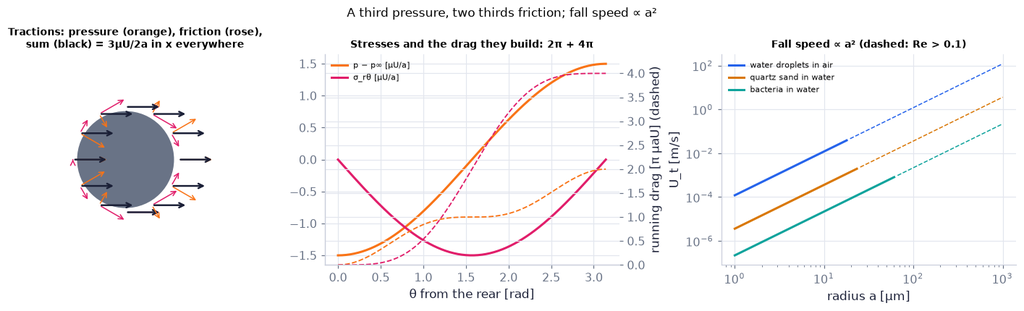

```python
import warnings                                           # to silence the "Re > 0.1" warnings of the dashed extensions
fig, (a1, a2, a3) = plt.subplots(1, 3, figsize=(13, 3.8))   # the figure and its panels
th_ = np.linspace(0, 2*np.pi, 13)[:-1]                    # 12 points round the circle in the drawing plane
for t0 in th_:                                            # traction arrows at each point (units μU/a, U = a = μ = 1)
    c, s = np.cos(t0), np.sin(t0)                         # the point (and the outward normal e_r) on the circle
    th_s = np.arccos(c)                                   # the spherical angle θ from the downstream +x axis
    srr1, srt1, _ = ch08.stokes_sphere_surface_stresses(th_s, U=1.0, a=1.0, mu=1.0)   # σ_rr = −p and σ_rθ there
    e_th = np.array([-abs(s), np.sign(s)*c])              # unit vector of increasing θ in the drawing plane
    t_p = srr1*np.array([c, s])                           # pressure (normal) part of the traction
    t_f = srt1*e_th                                       # friction (tangential) part
    for vec, col, lw in ((t_p, COLORS["orange"], 1.0), (t_f, COLORS["rose"], 1.0), (t_p + t_f, COLORS["ink"], 1.6)):   # pressure, friction and their sum
        a1.annotate("", xy=(1.1*c + 0.5*vec[0], 1.1*s + 0.5*vec[1]), xytext=(1.1*c, 1.1*s),   # an arrow
                    arrowprops=dict(arrowstyle="->", color=col, lw=lw), zorder=5)   # its style, drawn over the sphere
sphere(a1, 1.0); a1.set_xlim(-2.4, 2.8); a1.set_ylim(-2.2, 2.2); a1.axis("off")   # fixed axis limits
a1.set_title("Tractions: pressure (orange), friction (rose),\nsum (black) = 3μU/2a in x everywhere", fontsize=9)   # each panel says its message
thv = np.linspace(0, np.pi, 200)                          # from the rear (0) to the front (π)
a2.plot(thv, ch08.stokes_sphere_pressure(1.0, thv, 1.0, 1.0, 1.0), color=COLORS["orange"], lw=2, label="p − p∞ [μU/a]")   # a curve (its label says which)
a2.plot(thv, ch08.stokes_sphere_surface_stresses(thv, 1.0, 1.0, 1.0)[1], color=COLORS["rose"], lw=2, label="σ_rθ [μU/a]")   # a curve (its label says which)
b2 = a2.twinx()                                           # running drag on a second axis
run_ = ch08.stokes_drag_running(thv, 1.0, 1.0, 1.0)       # pressure and friction parts collected up to θ [μaU]
b2.plot(thv, run_["pressure"]/np.pi, color=COLORS["orange"], ls="--", lw=1.2)   # a curve (its label says which)
b2.plot(thv, run_["friction"]/np.pi, color=COLORS["rose"], ls="--", lw=1.2)   # a curve (its label says which)
b2.set_ylabel("running drag [π μaU] (dashed)"); b2.set_ylim(0, 4.4)   # labels with units
a2.set_xlabel("θ from the rear [rad]"); a2.legend(fontsize=7, loc="upper left"); a2.set_title("Stresses and the drag they build: 2π + 4π", fontsize=9)   # labels with units
radii = np.geomspace(1e-6, 1e-3, 80)                      # particle radii [m]
fams = [("water droplets in air", 1000.0, 1.2, 1.81e-5, COLORS["blue"]), ("quartz sand in water", 2650.0, 1000.0, 1e-3, COLORS["amber"]),   # (continued)
        ("bacteria in water", 1100.0, 1000.0, 1e-3, COLORS["teal"])]   # (continued)
with warnings.catch_warnings():                          # a block with its own warning settings
    warnings.simplefilter("ignore")                       # beyond Re = 0.1 the law is drawn dashed, not trusted
    for name, rp, rf, mf, c in fams:                     # one line per kind of particle
        Ut = ch08.terminal_velocity(radii, rp, rf, mf, warn=False)   # N90 [m/s]
        Re_ = 2*radii*Ut*rf/mf                            # Reynolds number with the diameter
        ok = Re_ < 0.1                                   # where Stokes' law is trustworthy
        a3.loglog(1e6*radii[ok], Ut[ok], color=c, lw=2, label=name)   # a curve (its label says which)
        a3.loglog(1e6*radii[~ok], Ut[~ok], color=c, lw=1, ls="--")   # a curve (its label says which)
for name, rp, rf, mf, c in fams:                          # the fall speed of a 10 µm particle of each kind
    print(f"10 µm {name}: U_t = {1e3*ch08.terminal_velocity(10e-6, rp, rf, mf, warn=False):.3g} mm/s")
a3.set_xlabel("radius a [µm]"); a3.set_ylabel("U_t [m/s]"); a3.legend(fontsize=7); a3.set_title("Fall speed ∝ a² (dashed: Re > 0.1)", fontsize=9)   # labels with units
fig.suptitle("A third pressure, two thirds friction; fall speed ∝ a²", fontsize=11)   # the figure's message
savefig(fig, "ch08", "c14_stokes_drag"); plt.show()      # save the PNG to outputs/ch08, then draw
```

**What you see.** (a) arrows round the sphere: pressure (orange) pushing at the front and pulling at the rear, friction (rose) along the surface, and their sum (black) the same everywhere; (b) the pressure and shear stress against θ and their running integrals (dashed) reaching 2π and 4π μaU; (c) straight lines of slope 2 for droplets, sand and bacteria, dashed where Re > 0.1 — our remake of Fig. 8.17's stress plot (`N107`).

**How to read it.** In (b) the orange dashed curve ends at 2 and the rose one at 4 (in units of πμaU): one third and two thirds of 6πμaU. In (c) read a fall speed: a 10 µm droplet falls about 1.2 cm/s, a 10 µm sand grain about 0.36 mm/s (both printed above the figure).

**What would change if…** …the droplet were oil (ρ′ = 900 kg/m³): $U_t\propto(\rho'-\rho)$, so it falls about 10 % more slowly.

#### 🎮 Interactive: Where does 6πμaU come from?

**Why interactive rather than a static figure:** Sweep around the sphere and watch the local pressure and shear tractions as arrows and curves while their running integrals build up to 2πμaU and 4πμaU in the term bars; then drag the particle radius and read U_t and Re as the Stokes law's validity limit is crossed.

**What to try:**

- Play the sweep from the rear (θ = 0) to the front: which bar grows first?
- Pick 'drizzle 100 µm': the status turns amber — why?
- Switch the third view to C_D(Re) and find where Oseen and the correlation leave 24/Re.
- Click a point on the sphere and read the traction arithmetic.

```python
show_viz("ch08", "stokes_drag_settling")   # full-width explainer; ⤢ Full screen for more room
```

🎮 Interactive 9/9 Where does 6*π**μ**a**U* come from? Open alone ↗

[interactive chart not shown]

**What would change if…** …we looked far from the sphere? The viscous force there decays like a/r³ but inertia only like a/r²; at some distance inertia wins even for tiny Re (C15).

### 🧩 Where Stokes fails, and Oseen's fix `C15`

*The question:* If Re is tiny, how can inertia ever matter?

*In one line:* $\frac{\text{inertia}}{\text{viscous}}\sim\frac{\rho Ua}{\mu}\frac ra=\mathrm{Re}_a\frac ra$ — small near the sphere, order one at a distance of order $a/\mathrm{Re}_a$.

#### The problem in plain words

Far behind a slowly falling bead the fluid is barely disturbed — so inertia should be even less important there. It is the opposite: the viscous force falls off faster with distance than inertia does, so beyond some radius Stokes' solution is wrong. For a cylinder it is so wrong that no Stokes solution exists at all.

#### The idea

| at distance r | size |
| --- | --- |
| disturbance velocity | ~ Ua/r |
| inertia ρu·∇u | ~ ρU²a/r² |
| viscous μ∇²u | ~ μUa/r³ |
| ratio | ~ (ρUa/μ)(r/a) = Re_a r/a → order one at r ~ a/Re_a |

The slowly decaying disturbance is swept along by the stream; its viscous force falls one power of r faster.

> 🔁 **Tools from earlier chapters used here** (see `knowledge/primers.md`)
- **asymptotic size of a term far away** — for r ≫ a keep only the slowest-decaying piece of each quantity; a derivative of a 1/r term brings another 1/r (Ch. 4 P130, order-of-magnitude scaling).
- **series of 1 − e^(−s)** — $1-e^{-s}=s-\frac{s^2}{2}+\ldots$ for small s; `sp.series` produces it (Ch. 4 P117).

#### 🧮 Derivation — Far-field breakdown: inertia/viscous ~ $\frac{\rho Ua}{\mu}\frac ra=\mathrm{Re}_a\frac ra$ `D32`

**What we want to show.** Show that however small Re is, inertia matches viscosity at some distance from the sphere.

**Assumptions.** r ≫ a; orders of magnitude only.

**The plan.**

1. Size the disturbance far away.
2. Size inertia and viscous terms.
3. Take the ratio.

**Tools we use** (each explained before this point): asymptotic size of a term (gloss, P130).

**We start from**

$$ u_r=U\cos\theta\Big(1-\frac{3a}{2r}+\frac{a^3}{2r^3}\Big),\ u_\theta=-U\sin\theta\Big(1-\frac{3a}{4r}-\frac{a^3}{4r^3}\Big)\ \text{(8.49)},\qquad r\gg a $$

*In words:* Stokes' velocities far from the sphere

**Step 1 of 7 — Keep the slowest-decaying disturbance.**

$$ \lvert\mathbf u-U\mathbf e_x\rvert\sim\frac{Ua}{r} $$

- *Why we can do this:* In (8.49), $u_r=U\cos\theta\Big(1-\frac{3a}{2r}+\frac{a^3}{2r^3}\Big),\ u_\theta=-U\sin\theta\Big(1-\frac{3a}{4r}-\frac{a^3}{4r^3}\Big)$ the 3a/2r and 3a/4r terms decay like 1/r; the a³/r³ terms are much smaller far away.
- *In words:* the sphere is felt as Ua/r.

**Step 2 of 7 — Size the disturbance's gradient.**

$$ \lvert\nabla\mathbf u'\rvert\sim\frac{Ua}{r^2},\qquad \mathbf u'=\mathbf u-U\mathbf e_x $$

- *Why we can do this:* Differentiating a 1/r term brings another 1/r; we call the part of the velocity that differs from the stream the disturbance u′.
- *In words:* gradients fall as 1/r².

**Step 3 of 7 — Size the inertia.**

$$ \rho\,\mathbf u\cdot\nabla\mathbf u\sim\rho U\frac{\partial\mathbf u'}{\partial x}\sim\rho U\cdot\frac{Ua}{r^2}=\frac{\rho U^2a}{r^2} $$

- *Why we can do this:* Far away the velocity is the stream U plus the small disturbance u′, so the largest part of u·∇u is the stream carrying the disturbance, U ∂u′/∂x (the term Oseen keeps, N95). In (8.49), $u_r=U\cos\theta\Big(1-\frac{3a}{2r}+\frac{a^3}{2r^3}\Big),\ u_\theta=-U\sin\theta\Big(1-\frac{3a}{4r}-\frac{a^3}{4r^3}\Big)$ this O(U²a/r²) inertia sits in the radial component, (3U²a/16r²)(8cos²θ − 4sin²θ); the θ-component has no such term.
- *In words:* the stream sweeps the disturbance past: inertia ~ ρU²a/r².

**Step 4 of 7 — Size the viscous force.**

$$ \mu\nabla^2\mathbf u\sim\mu\frac{Ua/r}{r^2}=\frac{\mu Ua}{r^3} $$

- *Why we can do this:* Two derivatives of the Ua/r disturbance (the uniform part has none).
- *In words:* friction ~ μUa/r³.

**Step 5 of 7 — Take the ratio.**

$$ \frac{\text{inertia}}{\text{viscous}}\sim\frac{\rho U^2a/r^2}{\mu Ua/r^3}=\frac{\rho Ur}{\mu} $$

- *Why we can do this:* Divide step 3 by step 4.
- *In words:* the ratio grows with r.

**Step 6 of 7 — Write it with a Reynolds number.**

$$ \frac{\rho Ur}{\mu}=\frac{\rho Ua}{\mu}\frac ra=\mathrm{Re}_a\frac ra $$

- *Why we can do this:* Re_a uses the radius (Re = 2aU/ν = 2Re_a).
- *In words:* small Re times a large distance.

**Step 7 of 7 — Find the crossover.**

$$ \mathrm{Re}_a\frac ra\sim1\ \Rightarrow\ \frac ra\sim\frac{1}{\mathrm{Re}_a} $$

- *Why we can do this:* Set the ratio to one: that is where inertia stops being negligible. This is an order of magnitude: the exact prefactor is ½ on the axis and on the side line (so the crossover is at r ≈ 2a/Re_a), and it dips near θ ≈ 55°, where the leading inertia term changes sign.
- *In words:* beyond r ~ a/Re_a Stokes' solution is wrong.

**Result**

$$ \frac{\text{inertia}}{\text{viscous}}\sim\frac{\rho Ua}{\mu}\frac ra=\mathrm{Re}_a\frac ra\quad\text{(order of magnitude)} $$

*In words:* the non-uniformity of Stokes flow is at infinity.

**What it means.** For a cylinder the disturbance decays even more slowly and no Stokes solution exists (Stokes' paradox); Oseen keeps U∂u′/∂x to fix the far field (N95).

**Check it.** `inertia_viscous_ratio` has log–log slope 1 ± 0.05 for r/a ∈ [50, 500] (the from-scratch cell of C15 measures it). Re_a = 0.01 → r of order 100a, and the 10 µm droplet (Re_a = 0.008) → r of order 125a = 1.25 mm — orders of magnitude: the code cell of C15 prints ratio ÷ (Re_a r/a) ≈ 0.5 on the axis and on the side line, so inertia equals friction at r ≈ 2a/Re_a (200a for Re_a = 0.01).

> ⚠️ **Common confusion (traps in `D32`):** The disturbance far away is ~ Ua/r (the Stokeslet), not a³/r³; Re here uses the radius.

📝 **Note.** **N94 [C] · A singular perturbation at infinity.** Treated as the first term of an expansion in Re, Stokes' solution is not uniformly valid: the O(Re) correction grows without bound relative to it as r → ∞ (Whitehead's paradox); for a cylinder the Stokes equations cannot even meet the uniform stream (Stokes' paradox, Exercise 8.37). Unlike the boundary layer (Ch. 9), where 1/Re multiplies the highest derivative near the wall, here the trouble is far away.

📝 **Note.** **N95 [B], N96 [B] · Oseen's linearisation (1910).** **N95** Write u = U + u′ with u′ small far away. The advective term splits as $u\frac{\partial u}{\partial x}+v\frac{\partial u}{\partial y}+w\frac{\partial u}{\partial z}=U\frac{\partial u'}{\partial x}+ \big[u'\frac{\partial u'}{\partial x}+v'\frac{\partial u'}{\partial y}+w'\frac{\partial u'}{\partial z}\big]$; dropping the bracket gives the equation below. ⚠️ The book prints $+\partial p/\partial x_i$; the minus of (8.43), $\nabla p=\mu\nabla^2\mathbf u$ is needed. **N96** Conditions: u′, v′, w′ → 0 far away; u′ = −U, v′ = w′ = 0 on the sphere.

$$ \rho U\frac{\partial u_i'}{\partial x}=-\frac{\partial p}{\partial x_i}+\mu\nabla^2u_i' $$

```python
ol_ = ch08.oseen_linearisation_sympy()                   # N95 in sympy
print("dropped (quadratic) part:", ol_["dropped"])
print("Oseen x-equation:", ol_["oseen_x"])               # ρU ∂u'/∂x = μ∇²u' − ∂p/∂x
```

```
dropped (quadratic) part: u'(x, y, z)*Derivative(u'(x, y, z), x) + v'(x, y, z)*Derivative(u'(x, y, z), y) + w'(x, y, z)*Derivative(u'(x, y, z), z)
Oseen x-equation: Eq(U*rho*Derivative(u'(x, y, z), x), mu*(Derivative(u'(x, y, z), (x, 2)) + Derivative(u'(x, y, z), (y, 2)) + Derivative(u'(x, y, z), (z, 2))) - Derivative(p(x, y, z), x))
```

📝 **Note.** **N97 [B], N98 [B] · Oseen's stream function.** **N97** Oseen's solution is (8.53), with Re = 2aU/ν (stated; no slip holds only to O(Re)). **N98** Near the sphere the exponential's series returns Stokes' (8.48), $\psi=Ur^2\sin^2\theta\Big(\frac12-\frac{3a}{4r}+\frac{a^3}{4r^3}\Big)$. ⚠️ The text calls it "(9.68)"; it means (8.48).

$$ \frac{\psi}{Ua^2}=\Big[\frac{r^2}{2a^2}+\frac{a}{4r}\Big]\sin^2\theta-\frac{3}{\mathrm{Re}}(1+\cos\theta)\Big\{1-\exp\Big[-\frac{\mathrm{Re}}{4}\frac ra(1-\cos\theta)\Big]\Big\} \qquad \text{(8.53)} $$

#### 🧮 Derivation — Oseen's $\psi$ reduces to Stokes' $\psi=Ur^2\sin^2\theta\big(\frac12-\frac{3a}{4r}+\frac{a^3}{4r^3}\big)$ near the sphere `D33` (Eq. 8.53: $\frac{\psi}{Ua^2}=\Big[\frac{r^2}{2a^2}+\frac{a}{4r}\Big]\sin^2\theta-\frac{3}{\mathrm{Re}}(1+\cos\theta)\Big\{1-\exp\Big[-\frac{\mathrm{Re}}{4}\frac ra(1-\cos\theta)\Big]\Big\}$)

**What we want to show.** Check that Oseen's improved solution agrees with Stokes' where Stokes is valid.

**Assumptions.** Re r/a ≪ 1 (near the sphere, small Re) — step 2.

**The plan.**

1. Name the exponent.
2. Expand the exponential for small arguments.
3. Simplify with sin²θ = (1 − cos θ)(1 + cos θ).

**Tools we use** (each explained before this point): series of 1 − $e^{-s}$ (gloss, P117).

**We start from**

$$ \frac{\psi}{Ua^2}=\big[\frac{r^2}{2a^2}+\frac a{4r}\big]\sin^2\theta-\frac3{\mathrm{Re}}(1+\cos\theta)\big\{1-\exp\big[-\frac{\mathrm{Re}}4 \frac ra(1-\cos\theta)\big]\big\}\ \text{(8.53), Re = 2aU/ν.} $$

**Step 1 of 7 — Name the exponent.**

$$ s=\frac{\mathrm{Re}}{4}\frac ra(1-\cos\theta) $$

- *Why we can do this:* The whole Oseen correction depends on this one combination.
- *In words:* s measures inertia's reach.

**Step 2 of 7 — State where s is small.**

$$ s\ll1\iff\mathrm{Re}\,\frac ra\ll1 $$

- *Why we can do this:* 0 ≤ 1 − cos θ ≤ 2, so s is small exactly where D32 says Stokes holds.
- *In words:* near the sphere at small Re.

**Step 3 of 7 — Expand the exponential.**

$$ 1-e^{-s}=s-\frac{s^2}{2}+\ldots\approx s $$

- *Why we can do this:* Taylor series of $e^{-s}$ (P117); keep the leading term.
- *In words:* the bracket is linear in s.

**Step 4 of 7 — Insert into the Oseen term.**

$$ \frac3{\mathrm{Re}}(1+\cos\theta)s=\frac3{\mathrm{Re}}(1+\cos\theta)\frac{\mathrm{Re}}4\frac ra (1-\cos\theta) $$

- *Why we can do this:* Replace 1 − e^(−s) by its leading term s from step 3.
- *In words:* Re cancels.

**Step 5 of 7 — Use sin²θ = (1 + cos θ)(1 − cos θ).**

$$ =\frac34\frac ra\sin^2\theta $$

- *Why we can do this:* The product of the two brackets is 1 − cos²θ.
- *In words:* the Stokeslet term appears.

**Step 6 of 7 — Collect the terms.**

$$ \frac{\psi}{Ua^2}\approx\Big[\frac{r^2}{2a^2}-\frac{3r}{4a}+\frac{a}{4r}\Big]\sin^2\theta $$

- *Why we can do this:* Subtract step 5 from the first bracket of (8.53), $\frac{\psi}{Ua^2}=\Big[\frac{r^2}{2a^2}+\frac{a}{4r}\Big]\sin^2\theta-\frac{3}{\mathrm{Re}}(1+\cos\theta)\Big\{1-\exp\Big[-\frac{\mathrm{Re}}{4}\frac ra(1-\cos\theta)\Big]\Big\}$.
- *In words:* three terms, like Stokes.

**Step 7 of 7 — Multiply by Ua².**

$$ \psi\approx Ur^2\sin^2\theta\Big(\frac12-\frac{3a}{4r}+\frac{a^3}{4r^3}\Big)\ \text{(8.48)} $$

- *Why we can do this:* Ua² × [r²/2a², −3r/4a, a/4r] = Ur²[½, −3a/4r, a³/4r³]. The text calls this "(9.68)"; it is (8.48), $\psi=Ur^2\sin^2\theta\Big(\frac12-\frac{3a}{4r}+\frac{a^3}{4r^3}\Big)$.
- *In words:* Stokes' solution recovered, with an O(Re) remainder.

**Result**

$$ \psi_{Oseen}=\psi_{Stokes}+O\Big(\mathrm{Re}\frac ra\Big),\qquad \psi=Ur^2\sin^2\theta\Big(\frac12-\frac{3a}{4r}+\frac{a^3}{4r^3}\Big)\ \text{(8.48)} $$

*In words:* Oseen changes only the far field.

**What it means.** Near the sphere the two agree; far away Oseen's exponential sweeps the disturbance downstream into a wake, and the drag gains the factor (1 + 3Re/16).

**Check it.** `oseen_limit_sympy()["difference"]` = 0 in the limit Re → 0; numerically ψ agree to ~1e-6 at Re = 10⁻⁶. Oseen meets no slip on r = a only to O(Re).

> ⚠️ **Common confusion (traps in `D33`):** s is small only where Re r/a ≪ 1; the product (1 + cos θ)(1 − cos θ) is sin²θ; do not assert exact no slip for (8.53), $\frac{\psi}{Ua^2}=\Big[\frac{r^2}{2a^2}+\frac{a}{4r}\Big]\sin^2\theta-\frac{3}{\mathrm{Re}}(1+\cos\theta)\Big\{1-\exp\Big[-\frac{\mathrm{Re}}{4}\frac ra(1-\cos\theta)\Big]\Big\}$.

```python
ol = ch08.oseen_limit_sympy()                            # D33 in sympy: expand 1 − e^(−s) and let Re → 0
print("s =", ol["s"])
print("Oseen − Stokes as Re → 0:", sp.simplify(ol["difference"]))   # 0
print("first-order correction:", ol["first_order"])       # O(Re) and growing with r: the far-field change
```

```
s = Re*r*(1 - cos(theta))/(4*a)
Oseen − Stokes as Re → 0: 0
first-order correction: 3*Re*U*r**2*(1 - cos(theta))*sin(theta)**2/32
```

#### ✏️ Tiny example: where inertia catches up

Re = 2aU/ν = 0.02, so $\mathrm{Re}_a=\mathrm{Re}/2=0.01$.

1. The estimate $\mathrm{Re}_a\,r/a\sim1$ puts the crossover at r of order 100a. With the exact prefactor ½ (the code below computes it on the axis and the side line) inertia equals friction at r ≈ 2a/Re_a = 200a.
2. For the 10 µm droplet (Re = 0.016, Re_a = 0.008) the same estimate gives r of order 125a = 1.25 mm, and about 250a with the prefactor.
3. Oseen C_D at Re = 0.5: $\frac{24}{\mathrm{Re}}\big(1+\frac{3}{16}\mathrm{Re}\big)=48(1+3/32)=52.5$ vs Stokes 48 — a 9 % correction.

```python
Re_a = 1e-3*1e-3/1e-4                                    # U a/ν with U = 1 mm/s, a = 1 mm, ν = 10⁻⁴ m²/s: 0.01
for th_, name in ((0.0, "axis θ = 0"), (np.pi/4, "θ = π/4"), (np.pi/2, "side line θ = π/2")):   # three directions from the sphere
    for rr_ in (10.0, 100.0, 400.0):                     # distances in radii
        ratio = ch08.inertia_viscous_ratio(rr_*1e-3, th_, U=1e-3, a=1e-3, nu=1e-4)   # |u·∇u| / |ν∇²u| on Stokes' field
        print(f"{name:18s} r = {rr_:5.0f}a: ratio = {ratio:.4f}, ratio ÷ (Re_a r/a) = {ratio/(Re_a*rr_):.3f}")   # show the numbers
print("C_D at Re = 0.5: Oseen", ch08.oseen_drag_coefficient(0.5), " Stokes", ch08.stokes_drag_coefficient(0.5),   # show the numbers
      " Proudman–Pearson", round(ch08.proudman_pearson_drag_coefficient(0.5), 3), " Morrison (data fit)", round(SIM.sphere_drag_coefficient(0.5), 3))   # (continued)
print("ψ Oseen (Re = 1e-6) vs Stokes at r = 2a, θ = π/3:", ch08.oseen_streamfunction(2e-3, np.pi/3, U=1e-3, a=1e-3, Re=1e-6),   # show the numbers
      ch08.stokes_sphere_streamfunction(2e-3, np.pi/3, U=1e-3, a=1e-3))   # Stokes' (8.48) at the same point
```

```
axis θ = 0         r =    10a: ratio = 0.0421, ratio ÷ (Re_a r/a) = 0.421
axis θ = 0         r =   100a: ratio = 0.4925, ratio ÷ (Re_a r/a) = 0.492
axis θ = 0         r =   400a: ratio = 1.9925, ratio ÷ (Re_a r/a) = 0.498
θ = π/4            r =    10a: ratio = 0.0122, ratio ÷ (Re_a r/a) = 0.122
θ = π/4            r =   100a: ratio = 0.1545, ratio ÷ (Re_a r/a) = 0.155
θ = π/4            r =   400a: ratio = 0.6289, ratio ÷ (Re_a r/a) = 0.157
side line θ = π/2  r =    10a: ratio = 0.0458, ratio ÷ (Re_a r/a) = 0.458
side line θ = π/2  r =   100a: ratio = 0.4962, ratio ÷ (Re_a r/a) = 0.496
side line θ = π/2  r =   400a: ratio = 1.9962, ratio ÷ (Re_a r/a) = 0.499
C_D at Re = 0.5: Oseen 52.5  Stokes 48.0  Proudman–Pearson 51.564  Morrison (data fit) 48.439
ψ Oseen (Re = 1e-6) vs Stokes at r = 2a, θ = π/3: 4.687501406249884e-10 4.6875e-10
```

**What does the code above do?**

1. `inertia_viscous_ratio` evaluates |u·∇u| / |ν∇²u| on Stokes' field by finite differences. It grows in proportion to r, and ratio ÷ (Re_a r/a) tends to **½ on the axis and on the side line** — so inertia equals friction at r ≈ 2a/Re_a (200a here). At θ = π/4 the leading inertia term nearly cancels (it changes sign near θ ≈ 55°) and the prefactor is smaller, about 0.16. The book's r ~ a/Re is the right order of magnitude.
2. The drag laws at Re = 0.5: Oseen 52.5, Stokes 48, Proudman–Pearson 51.6 (close to Oseen) and the Morrison correlation of the measurements 48.4 — between Stokes and Oseen, as the book says.
3. At a vanishing Re Oseen's ψ equals Stokes' to about 10⁻⁶ (D33).

```python
hh = 1e-4                                                # relative finite-difference step
pts = [(r_*1e-3, 0.0) for r_ in (50.0, 100.0, 200.0)]   # three points on the axis behind the sphere (x, y) [m]


def vel(x_, y_):                                          # Stokes body-frame velocity (u, v) in the plane z = 0
    u_, v_, _ = ch08.stokes_sphere_velocity_xyz(np.array(x_), np.array(y_), np.array(0.0), 1e-3, 1e-3)
    return np.array([u_, v_], float)


mine = []
for x0, y0 in pts:
    d = hh*x0                                             # step [m]
    ux = (vel(x0 + d, y0) - vel(x0 - d, y0))/(2*d); uy = (vel(x0, y0 + d) - vel(x0, y0 - d))/(2*d)   # ∂u/∂x, ∂u/∂y
    uxx = (vel(x0 + d, y0) - 2*vel(x0, y0) + vel(x0 - d, y0))/d**2
    uyy = (vel(x0, y0 + d) - 2*vel(x0, y0) + vel(x0, y0 - d))/d**2
    lap = uxx + 2*uyy                                     # ∇²u on the axis: the z-direction curves like the y-direction (axisymmetry)
    adv = vel(x0, y0)[0]*ux + vel(x0, y0)[1]*uy           # u·∇u (w = 0 in the plane z = 0)
    mine.append(np.linalg.norm(adv)/np.linalg.norm(1e-4*lap))   # |u·∇u| / |ν∇²u|
lib = [ch08.inertia_viscous_ratio(x0, 0.0, U=1e-3, a=1e-3, nu=1e-4) for x0, _ in pts]
print("by hand:", np.round(mine, 4), " library:", np.round(lib, 4))
assert np.allclose(mine, lib, rtol=1e-3)                 # the same ratio
rs = np.geomspace(50, 500, 8)                            # r/a from 50 to 500
slope = observed_order(rs, [ch08.inertia_viscous_ratio(r_*1e-3, np.pi/2, U=1e-3, a=1e-3, nu=1e-4) for r_ in rs])   # log–log slope
print(f"log–log slope of the ratio for r/a in [50, 500]: {slope:.3f}")
assert abs(slope - 1) < 0.05                             # D32: the ratio grows like r
```

```
by hand: [0.2424 0.4925 0.9925]  library: [0.2424 0.4925 0.9925]
log–log slope of the ratio for r/a in [50, 500]: 1.006
```

**What does the code above do?**

1. At three points on the axis behind the sphere it builds u·∇u and ν∇²u by hand from central differences of Stokes' velocity (using the axial symmetry for the z-curvature) and takes the ratio of their sizes.
2. The hand ratios equal the library's `inertia_viscous_ratio` — 0.24, 0.49 and 0.99 at 50a, 100a and 200a with Re_a = 0.01 — each about ½ Re_a r/a.
3. Fitting the ratio against r on log–log axes for r/a from 50 to 500 gives slope 1.006: inertia over friction grows in proportion to r, as D32 argued.

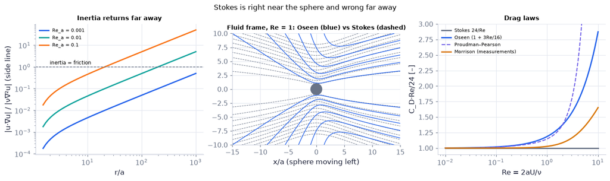

```python
fig, (a1, a2, a3) = plt.subplots(1, 3, figsize=(13, 3.8))   # the figure and its panels
rs = np.geomspace(1.5, 1000, 60)                          # r/a (beyond ~1000a even this step meets round-off)
for Rea, c in ((1e-3, COLORS["blue"]), (1e-2, COLORS["teal"]), (1e-1, COLORS["orange"])):   # three Re_a
    nu_ = 1e-3*1e-3/Rea                                    # ν that gives this Re_a with U = 1 mm/s, a = 1 mm
    a1.loglog(rs, ch08.inertia_viscous_ratio(rs*1e-3, np.pi/2, U=1e-3, a=1e-3, nu=nu_, h_rel=1e-2), color=c, lw=2, label=f"Re_a = {Rea:g}")   # finite-difference step 1 % of r: no round-off noise far away
a1.axhline(1, color=COLORS["muted"], ls="--", lw=1); a1.text(2, 1.3, "inertia = friction", fontsize=8)   # reference line
a1.set_xlabel("r/a"); a1.set_ylabel("|u·∇u| / |ν∇²u| (side line)"); a1.legend(fontsize=7); a1.set_title("Inertia returns far away", fontsize=10)   # labels with units
n_ = 200 if not FAST else 100                             # contour grid
xg = np.linspace(-15, 15, n_); yg = np.linspace(-10, 10, n_)   # a window of 30 × 20 radii
Xo, Yo = np.meshgrid(xg, yg); Ro = np.hypot(Xo, Yo); To = np.arccos(np.clip(Xo/np.maximum(Ro, 1e-12), -1, 1))   # grid, spherical r and θ from +x
outo = Ro > 1                                            # points outside the sphere
ps_ = np.where(outo, ch08.stokes_sphere_streamfunction(Ro, To, 1.0, 1.0, frame="fluid"), np.nan)   # Stokes' ψ, fluid frame (N93)
po_ = np.where(outo, ch08.oseen_streamfunction(Ro, To, 1.0, 1.0, Re=1.0, frame="fluid"), np.nan)   # Oseen's ψ (8.53) at Re = 1, fluid frame
lev = np.linspace(-6, -0.5, 12)                         # streamline levels ψ/(Ua²) (the fluid-frame ψ is negative)
a2.contour(Xo, Yo, ps_, lev, colors=COLORS["muted"], linewidths=0.7, linestyles="--")   # streamlines = lines of constant ψ
a2.contour(Xo, Yo, po_, lev, colors=COLORS["blue"], linewidths=1.0)   # streamlines = lines of constant ψ
sphere(a2, 1.0); a2.set_xlim(-15, 15); a2.set_ylim(-10, 10); a2.set_xlabel("x/a (sphere moving left)")   # labels with units
a2.set_title("Fluid frame, Re = 1: Oseen (blue) vs Stokes (dashed)", fontsize=9)   # each panel says its message
Res = np.geomspace(0.01, 10, 100)                        # Reynolds numbers 2aU/ν
a3.semilogx(Res, ch08.stokes_drag_coefficient(Res)*Res/24, color=COLORS["muted"], lw=2, label="Stokes 24/Re")   # a curve (its label says which)
a3.semilogx(Res, ch08.oseen_drag_coefficient(Res)*Res/24, color=COLORS["blue"], lw=2, label="Oseen (1 + 3Re/16)")   # a curve (its label says which)
a3.semilogx(Res, np.array([ch08.proudman_pearson_drag_coefficient(r_) for r_ in Res])*Res/24, color=COLORS["accent"], lw=1.5, ls="--", label="Proudman–Pearson")   # a curve (its label says which)
a3.semilogx(Res, np.array([SIM.sphere_drag_coefficient(r_) for r_ in Res])*Res/24, color=COLORS["amber"], lw=2, label="Morrison (measurements)")   # a curve (its label says which)
a3.set_ylim(0.9, 3); a3.set_xlabel("Re = 2aU/ν"); a3.set_ylabel("C_D·Re/24 [–]"); a3.legend(fontsize=7); a3.set_title("Drag laws", fontsize=10)   # labels with units
fig.suptitle("Stokes is right near the sphere and wrong far away", fontsize=11)   # the figure's message
savefig(fig, "ch08", "c15_oseen"); plt.show()            # save the PNG to outputs/ch08, then draw
```

**What you see.** (a) the inertia/friction ratio growing in proportion to r for three Re_a, crossing 1 at r ≈ 2a/Re_a; (b) at Re = 1 the Oseen streamlines (blue) are crowded behind the moving sphere into a wake while Stokes' (dashed) stay symmetric — our remake of Fig. 8.20 `N100`; (c) C_D·Re/24: Stokes flat at 1, Oseen rising, the Morrison correlation of measurements between them below Re ≈ 5, and Proudman–Pearson `N101` following Oseen at first.

**How to read it.** In (c) any curve above 1 means more drag than Stokes' law: at Re = 1 Oseen adds 19 %; the measurements (amber) lie between Stokes and Oseen up to Re ≈ 5, the range where both formulas are "fairly accurate".

**What would change if…** …Re doubled: the crossover distance in (a) halves and the wake in (b) widens and moves closer to the sphere.

📝 **Note.** **N99 [B], N100 [B], N101 [C] · Drag beyond Stokes.** **N99** Oseen's drag coefficient is below; ⚠️ with the radius-based $\mathrm{Re}_a=\mathrm{Re}/2$ the same coefficient reads 3/8. **N100** The Oseen streamlines (panel b) are asymmetric, with a wake behind. **N101** Matched asymptotic expansions (Kaplun, Proudman & Pearson 1957) continue the series: $D=6\pi\mu aU\big(1+\frac38\mathrm{Re}_a+\frac9{40}\mathrm{Re}_a^2\ln\mathrm{Re}_a+ \ldots\big)$ (named only).

$$ C_D=\frac{24}{\mathrm{Re}}\Big(1+\frac3{16}\mathrm{Re}\Big) $$

```python
n_ = 200 if not FAST else 100                             # contour grid
xg = np.linspace(-15, 15, n_); yg = np.linspace(-10, 10, n_)   # a window of 30 × 20 radii
Xo, Yo = np.meshgrid(xg, yg); Ro = np.hypot(Xo, Yo); To = np.arccos(np.clip(Xo/np.maximum(Ro, 1e-12), -1, 1))   # grid, spherical r and θ from +x
lev = np.linspace(-6, -0.5, 12)                          # streamline levels ψ/(Ua²) (negative in the fluid frame)


def polylines(psi_):                                      # contour lines of ψ as one (x, y) polyline with NaN breaks
    cs = plt.figure().add_subplot().contour(Xo, Yo, psi_, lev)   # matplotlib finds the lines (figure discarded)
    xs, ys = [], []                                      # the collected x and y points of every line
    for path in cs.get_paths():                          # each contour level
        for poly in path.to_polygons(closed_only=False):  # every separate piece of the line
            xs += list(poly[:, 0]) + [np.nan]; ys += list(poly[:, 1]) + [np.nan]   # append the piece, then a NaN break
    plt.close("all")                                     # discard the helper figure
    return np.array(xs), np.array(ys)                    # one long polyline per ψ-field


stokes_lines = polylines(np.where(Ro > 1, ch08.stokes_sphere_streamfunction(Ro, To, 1.0, 1.0, frame="fluid"), np.nan))   # Stokes' fluid-frame streamlines, once
cache = {}                                                # Oseen lines for each Re, computed once
for Re_ in (0.1, 0.2, 0.5, 1.0, 2.0):                    # one set of Oseen lines per Re
    cache[Re_] = polylines(np.where(Ro > 1, ch08.oseen_streamfunction(Ro, To, 1.0, 1.0, Re=Re_, frame="fluid"), np.nan))   # Oseen's (8.53), fluid frame
circle = (np.cos(np.linspace(0, 2*np.pi, 60)), np.sin(np.linspace(0, 2*np.pi, 60)))   # the sphere's outline


def frame(Re_):                                           # the figure for one Re
    return {"Oseen streamlines": cache[Re_], "Stokes streamlines": stokes_lines, "sphere": circle}   # the curves of this position


Rs = [0.1, 0.2, 0.5, 1.0, 2.0]                           # the five Reynolds numbers of the slider
fig = slider_figure(frame, "Re", Rs, unit="", xlabel="x/a (sphere moving left)", ylabel="y/a", title="", xrange=[-15, 15], yrange=[-10, 10])   # precompute every slider/time position
step_titles(fig, [f"Re = {r_:g}: C_D Oseen {ch08.oseen_drag_coefficient(r_):.1f}, Stokes {ch08.stokes_drag_coefficient(r_):.1f}" for r_ in Rs])   # numbers that follow the slider
recolor(fig, {"Oseen streamlines": COLORS["blue"], "Stokes streamlines": COLORS["muted"], "sphere": COLORS["ink"]},   # colours by meaning (as in the static figures)
        {"Stokes streamlines": "dot"})                   # (continued)
fig.update_traces(line_width=1.2)                        # thinner lines for the dense streamlines
fig.show()                                               # draw the interactive figure
```

[interactive chart not shown]

**What does the code above do?**

Precomputed Oseen streamlines (fluid frame) for five Reynolds numbers over Stokes' symmetric ones (dotted); the title gives both drag coefficients. Slide Re up and watch the wake form behind the sphere.

🎮 The explainer of C13 (`stokes_sphere_flow`, above) has an **Oseen mode**: open it again, choose Oseen and drag Re to see the wake grow from far downstream.

## 8.7 Final Remarks

**What is this section about?** Where the exact solutions stop.

📝 **Note.** **N102 [C] · After the exact solutions.** Most laminar problems that can be solved with pencil and paper have been solved; the field moves on with perturbation methods (flows close to a known one — Ch. 9 boundary layers, Ch. 11 stability) and with numerical solution of the Navier–Stokes equations (Ch. 10, which uses this chapter's exact solutions as test cases).

*↪ **S01** Exercises 8.1–8.38 and the literature are not reproduced. Ideas from them used here: the Reynolds equation — Exercises 8.19–8.20 → C06; the power–dissipation identity — Exercise 8.12 → R11; the switched-on vortex — Exercise 8.26 → C10; the stopped plate — Exercise 8.30 → C09; Couette start-up — Exercise 8.31 → R14; Hele-Shaw near an obstacle — Exercise 8.34 → C06; Stokes drag from the stresses — Exercise 8.35 → C14; Stokes' paradox for a cylinder — Exercise 8.37 → C15; f = 64/Re — Exercise 8.7 → C03.*

## ✅ What should have clicked

- **C01** $\nu=\mu/\rho$ is a diffusivity: motion spreads $\sqrt{\nu t}$, and a flow stays laminar below Re ≈ 2000.
- **C02** Between plates the profile is a Couette line plus a Poiseuille parabola, $u(y)=\frac Uh\,y-\frac1{2\mu}\frac{dp}{dx}\,y(h-y)$ *(8.5)*; the floor flow reverses when $dp/dx>2\mu U/h^2$.
- **C03** In a pipe $Q=-\frac{\pi a^4}{8\mu}\frac{dp}{dz}$: halve the radius, lose 94 % of the flow; f = 64/Re.
- **C04** Between rotating cylinders the swirl is $u_\varphi=AR+B/R$ *(8.9)*: rigid rotation plus a free vortex, chosen by the walls.
- **C05** In a thin gap inertia is weighed with $\varepsilon^2\mathrm{Re}_L$, not Re_L; pressure is uniform across the gap.
- **C06** Station by station the gap flow is Couette plus Poiseuille; integrating continuity gives the Reynolds equation $h_t+q_x=0$.
- **C07** A constant flux through a narrowing gap needs a pressure hump — that hump carries the load, but only if the pad slides the right way.
- **C08** A spreading layer obeys $h_t=(\rho g/3\mu)(h^3h_x)_x$, a diffusion that chokes itself as h shrinks.
- **C09** With no imposed scale, y and t combine as $y/\sqrt{\nu t}$: one erfc curve for every time, $\delta_{99}=3.64\sqrt{\nu t}$ *(8.31)*.
- **C10** Guess $At^{-n}F(\xi/\delta(t))$; matching powers of t and one conserved quantity fix n and δ.
- **C11** An oscillating wall drives a decaying, lagging layer of depth $\sqrt{2\nu/\omega}$ — diffusion, not a wave.
- **C12** At low Re rescale pressure by μU/L; the Stokes equations $\nabla p=\mu\nabla^2\mathbf u$ *(8.43)* are linear.
- **C13** Stokes' sphere flow is fore–aft symmetric and decays only like a/r.
- **C14** Drag $D=6\pi\mu aU$ *(8.51)*, ⅓ pressure and ⅔ friction; fall speed ∝ a².
- **C15** Inertia returns at r ~ a/Re_a (about 2a/Re_a with the exact prefactor); Oseen's linearisation adds the wake and $C_D=\frac{24}{\mathrm{Re}}(1+\frac{3}{16}\mathrm{Re})$.

**What later chapters build on**

- Ch. 9: √(νt) ↔ √(νx/U), Blasius vs the temporal layer, the lubrication scaling as the boundary-layer approximation, similarity exponents.
- Ch. 10: exact solutions as code tests; Crank–Nicolson.
- Ch. 11: Couette, Poiseuille and Taylor–Couette base states; the Rayleigh criterion in A and B.
- Ch. 12: linear total stress, τ₀ and the friction velocity, f = 64/Re on the Moody chart.
- Ch. 13: Ekman layers with the (1 + i)/δ structure of the Stokes layer, spin-up times from √(νt), cyclostrophic balance, viscous gravity currents, settling of droplets and sediment.
- Ch. 16: arteries (Q ∝ a⁴), synovial lubrication, micro-swimmers (reversibility of Stokes flow).

**Not taught here (and where to find it)**

- The exercises (S01).
- Higher-order matched expansions for the sphere (named in N101).

← All chapters

← PreviousNext →

Code and explanations: shammun/fluidpy (MIT). The book is not reproduced here; equations are cited by number.